# 第 15 章 线性模型

## 15.1 一般线性模型

**Definition 15.1**. 称以下模型为线性模型（linear model）：

$$\begin{equation*}
\begin{cases}
y=X\beta+\varepsilon \\
\operatorname{E}(\varepsilon)=\mathbf{0} \\
\operatorname{Cov}(\varepsilon)=\sigma^2I_n
\end{cases}
\end{equation*}$$

其中$y$为$n\times 1$观测向量（observation vector），$X$为$n\times p$设计矩阵（design matrix），$\beta$为$p\times 1$未知参数向量，$\varepsilon$为随机误差，$\sigma^2$为误差方差。

**Definition 15.2**. 称方程$X^{\top}X\beta=X^{\top}y$为正则方程（normal equation）。

**Theorem 15.1**. 对于定义 15.1，$\hat{\beta}=(X^{\top}X)^-X^{\top}y$是其唯一的最小二乘解。

*证明*. 注意到：

$$\begin{gather*}
\begin{aligned}
Q(\beta)&=||y-X\beta||^2=(y-X\beta)^{\top}(y-X\beta) \\
&=y^{\top}y-y^{\top}X\beta-\beta^{\top}X^{\top}y+\beta^{\top}X^{\top}X\beta \\
&=y^{\top}y-2y^{\top}X\beta+\beta^{\top}X^{\top}X\beta
\end{aligned}\\
\frac{\partial y^{\top}X\beta}{\partial\beta}=X^{\top}y,\quad
\frac{\partial \beta^{\top}X^{\top}X\beta}{\partial\beta}=2X^{\top}X\beta \\
\frac{\partial Q(\beta)}{\partial\beta}=-2X^{\top}y+2X^{\top}X\beta=0 \\
X^{\top}X\beta=X^{\top}y
\end{gather*}$$

由定理 2.2和定理 2.4(1)可知方程$X^{\top}X\beta=X^{\top}y$是相容的，根据定理 2.11可知其通解为：

$$\begin{equation*}
\hat{\beta}=(X^{\top}X)^-X^{\top}y
\end{equation*}$$

其中$(X^{\top}X)^-$是$X^{\top}X$的任意一个广义逆矩阵。

对任意的$\beta$，有：

$$\begin{align*}
Q(\beta)&=||y-X\beta||^2=||y-X\hat{\beta}+X\hat{\beta}-X\beta||^2=||y-X\hat{\beta}+X(\hat{\beta}-\beta)||^2 \\
&=||y-X\hat{\beta}||^2+||X(\hat{\beta}-\beta)||^2+2(y-X\hat{\beta})^{\top}X(\hat{\beta}-\beta)
\end{align*}$$

注意到正则方程即为：

$$\begin{equation*}
X^{\top}(y-X\beta)=\mathbf{0}
\end{equation*}$$

于是：

$$\begin{equation*}
2(y-X\hat{\beta})^{\top}X(\hat{\beta}-\beta)=2[X^{\top}(y-X\hat{\beta})]^{\top}(\hat{\beta}-\beta)=0
\end{equation*}$$

所以：

$$\begin{equation*}
Q(\beta)=||y-X\hat{\beta}||^2+||X(\hat{\beta}-\beta)||^2
\end{equation*}$$

上第二项总是非负的，由范数的定义可知其为$0$当且仅当$X\hat{\beta}=X\beta$，即当且仅当$X^{\top}X\beta=X^{\top}X\hat{\beta}=X^{\top}y$，所以使$Q(\beta)$达到最小值的$\beta$必为正则方程的解$\hat{\beta}=(X^{\top}X)^-X^{\top}y$。 ◻

**Derivation 15.1**. 若$\operatorname{rank}(X)=p$，则$X$的列向量组线性无关。考虑二次型$y^{\top}X^{\top}Xy$，$y^{\top}X^{\top}Xy=0\Leftrightarrow||Xy||=0\Leftrightarrow Xy=\mathbf{0}$，而$X$的列向量是线性无关的，所以不存在非零向量的$y$使得$Xy=\mathbf{0}$，于是$y^{\top}X^{\top}Xy$是一个正定二次型，$X^{\top}X$是一个正定矩阵。由定理 2.17(6)可得$X^{\top}X$可逆。此时$\hat{\beta}=(X^{\top}X)^{-1}X^{\top}y$，称$\hat{\beta}$为$\beta$的最小二乘估计（least squares estimate）。

**note 15.1**. 接下来我们将涉及到非常多的公式，初学会觉得非常难记，但如果从投影的角度去理解的话，很多公式都是直观上非常显然的，也就更好记忆了。

### 15.1.1 参数估计

#### 15.1.1.1 回归系数

**Definition 15.3**. 若存在$n\times 1$向量$\alpha$使得$\operatorname{E}(\alpha^{\top}y)=c^{\top}\beta$对一切的$\beta$成立，则称$c^{\top}\beta$为可估函数（estimable function）。

**Property 15.1.1**. 对于定义 15.1，$c^{\top}\beta$和$d^{\top}\beta$是可估函数，$\hat{\beta}$是正则方程的解，则：

1. 使$c^{\top}\beta$成为可估函数的全体向量$c$构成$\mathcal{M}(X^{\top})$；
2. 可估函数的全体构成一个$\operatorname{rank}(X)$维线性空间；
3. $c^{\top}\hat{\beta}$与$(X^{\top}X)^-$的选择无关；
4. $c^{\top}\hat{\beta}$为$c^{\top}\beta$的无偏估计；
5. $\operatorname{Cov}(c^{\top}\hat{\beta},d^{\top}\hat{\beta})=\sigma^2c^{\top}(X^{\top}X)^-d$，且与$(X^{\top}X)^-$的选择无关；
6. (Gauss-Markov)$\;c^{\top}\hat{\beta}$是$c^{\top}\beta$唯一的BLUE；
7. 设$\varphi_i=c_i^{\top}\beta,\;i=1,2,\dots,k$都是可估函数，$\alpha_1, \alpha_2, \dots, \alpha_{k}\in\mathbb{R}^{}$，则$\varphi=\sum\limits_{i=1}^{k}\alpha_i\varphi_i$也是可估的，且$\hat{\varphi}=\sum\limits_{i=1}^{k}\alpha_ic_i^{\top}\hat{\beta}$是$\varphi$的BLUE。

*证明*. (1)$\;c^{\top}\beta$是可估函数$\Leftrightarrow$存在$n\times1$向量$\alpha$使得$\operatorname{E}(\alpha^{\top}y)=\alpha^{\top}\operatorname{E}(y)=\alpha^{\top}X\beta=c^{\top}\beta$对一切的$\beta$成立$\Leftrightarrow c=X^{\top}\alpha$。

(2)由(1)可得可估函数对加法和数乘封闭，根据定理 1.5可知所有可估函数构成一个线性空间。注意到可估函数$c_1^{\top}\beta$和$c_2^{\top}\beta$线性相关当且仅当$c_1$和$c_2$线性相关，由性质 1.1.5(3)和性质 2.1.8(7)可得可估函数空间的秩为$\operatorname{rank}(X)$。

(3)因为$c^{\top}\beta$可估，由(1)可知存在$n\times 1$向量$\alpha$使得$c=X^{\top}\alpha$，于是由性质 2.1.2(4)可得：

$$\begin{equation*}
c^{\top}\hat{\beta}=\alpha^{\top}X(X^{\top}X)^-X^{\top}y
\end{equation*}$$

由性质 2.5.1(4)即可得出结论。

(4)因为$c^{\top}\beta$可估，由(1)可知存在$n\times 1$向量$\alpha$使得$c=X^{\top}\alpha$，根据性质 2.5.1(7)可得：

$$\begin{equation*}
\operatorname{E}(c^{\top}\hat{\beta})=\operatorname{E}[c^{\top}(X^{\top}X)^-X^{\top}y]=c^{\top}(X^{\top}X)^-X^{\top}X\beta=c^{\top}\beta
\end{equation*}$$

(5)因为$c^{\top}\beta,d^{\top}\beta$是可估函数，由(1)可知存在$\alpha,\gamma$使得$c=X^{\top}\alpha,d=X^{\top}\gamma$。由性质 6.3.4(3)、性质 2.1.2(4)和性质 2.5.1(5)(7)可知：

$$\begin{align*}
\operatorname{Cov}(c^{\top}\hat{\beta},d^{\top}\hat{\beta})
&=\operatorname{Cov}[c^{\top}(X^{\top}X)^-X^{\top}y,d^{\top}(X^{\top}X)^-X^{\top}y] \\
&=c^{\top}(X^{\top}X)^-X^{\top}\operatorname{Cov}(y)X[(X^{\top}X)^-]^{\top}d \\
&=c^{\top}(X^{\top}X)^-X^{\top}\sigma^2I_nX(X^{\top}X)^-d \\
&=\sigma^2\alpha^{\top}X(X^{\top}X)^-X^{\top}X(X^{\top}X)^-X^{\top}\gamma \\
&=\sigma^2c^{\top}(X^{\top}X)^-d=\sigma^2\alpha^{\top}X(X^{\top}X)^-X^{\top}\gamma
\end{align*}$$

由性质 2.5.1(4)即可知$\operatorname{Cov}(c^{\top}\hat{\beta},d^{\top}\hat{\beta})$与$(X^{\top}X)^-$的选择无关。

(6)无偏性由(4)可得，线性性由正则方程可知，下证方差最小。 设$a^{\top}y$为$c^{\top}\beta$的任一无偏估计，由(1)的过程可知$c=X^{\top}a$。根据性质 2.5.1(5)和(5)可得：

$$\begin{align*}
\operatorname{Var}(a^{\top}y)-\operatorname{Var}(c^{\top}\hat{\beta})&=\sigma^2[a^{\top}a-c^{\top}(X^{\top}X)^-c] \\
&=\sigma^2[a^{\top}-c^{\top}(X^{\top}X)^-X^{\top}][a-X(X^{\top}X)^-c] \\
&=\sigma^2||a-X(X^{\top}X)^-c||^2\geqslant0
\end{align*}$$

上式第一行到第二行是由于性质 2.5.1(7)和性质 2.1.2(4)：

$$\begin{align*}
&[a^{\top}-c^{\top}(X^{\top}X)^-X^{\top}][a-X(X^{\top}X)^-c] \\
=&a^{\top}a-a^{\top}X(X^{\top}X)^-c-c^{\top}(X^{\top}X)^-X^{\top}a+c^{\top}(X^{\top}X)^-X^{\top}X(X^{\top}X)^-c \\
=&a^{\top}a-c^{\top}(X^{\top}X)^-c-c^{\top}(X^{\top}X)^-c+c^{\top}(X^{\top}X)^-c \\
=&a^{\top}a-c^{\top}(X^{\top}X)^-c
\end{align*}$$

由范数的性质可知$\operatorname{Var}(a^{\top}y)=\operatorname{Var}(c^{\top}\hat{\beta})$当且仅当$a=X(X^{\top}X)^-c$，由性质 2.5.2(3)可知$a=X(X^{\top}X)^-c\Leftrightarrow a^{\top}=c^{\top}(X^{\top}X)^-X^{\top}\Leftrightarrow a^{\top}y=c^{\top}(X^{\top}X)^-X^{\top}y=c^{\top}\hat{\beta}$。

(7)由(2)可知$\varphi$是可估的。

由(4)可得$c_i^{\top}\hat{\beta}$是$c_i^{\top}\beta$的无偏估计，所以：

$$\begin{equation*}
\operatorname{E}(\hat{\varphi})=\operatorname{E}\left(\sum_{i=1}^{k}\alpha_ic_i^{\top}\hat{\beta}\right)=\sum_{i=1}^{k}\alpha_i\operatorname{E}(c_i^{\top}\hat{\beta})=\sum_{i=1}^{k}\alpha_ic_i^{\top}\beta=\varphi
\end{equation*}$$

即$\hat{\varphi}$是一个无偏估计。

令$c=\sum\limits_{i=1}^{k}\alpha_ic_i$，则$\varphi=c^{\top}\beta$。设$\gamma^{\top}y$是$\varphi$的一个无偏估计，于是由(6)可得：

$$\begin{equation*}
\operatorname{Var}(\gamma^{\top}y)-\operatorname{Var}(c^{\top}\hat{\beta})=\sigma^2||\gamma-X(X^{\top}X)^-c||^2
\end{equation*}$$

上式等于$0\Leftrightarrow \gamma^{\top}y=c^{\top}\hat{\beta}=\hat{\varphi}$，即$\hat{\varphi}$是唯一的BLUE。 ◻

**Definition 15.4**. 对于定义 15.1，若$c^{\top}\beta$是可估函数，称$c^{\top}\hat{\beta}$为$c^{\top}\beta$的LSE，其中$\hat{\beta}$为正则方程的解。

#### 15.1.1.2 残差

**Definition 15.5**. 记$\hat{y}=X\hat{\beta}$，称$\hat{e}=y-\hat{y}$为残差向量（residual vector），称$\hat{e}^{\top}\hat{e}$为残差平方和（sum of squared residuals），记为$\operatorname{SSE}$。

**Property 15.1.2**. 对于定义 15.1，$\hat{\beta}$为正则方程的解，则残差向量$\hat{e}$满足：

1. $\operatorname{E}(\hat{e})=0,\;\operatorname{Cov}(\hat{e})=\sigma^2(I_n-P_X)$；
2. $\operatorname{SSE}=y^{\top}(I_n-P_X)y$；
3. $\operatorname{Cov}(\hat{y},\hat{e})=\mathbf{0}$；

*证明*. (1)由性质 2.8.2(2)可知向$\mathcal{M}(X)$的正交投影阵$P_X=X(X^{\top}X)^-X^{\top}$，根据性质 2.8.2(7)(3)可知$I_n-P_X$是对称幂等阵，所以由性质 6.3.4(3)可得：

$$\begin{gather*}
\begin{aligned}
\operatorname{E}(\hat{e})&=\operatorname{E}(y-X\hat{\beta})=\operatorname{E}[I_ny-X(X^{\top}X)^-X^{\top}y]=(I_n-P_X)\operatorname{E}(y) \\
&=(I_n-P_X)X\beta=(X-X)\beta=0
\end{aligned} \\
\begin{aligned}
\operatorname{Cov}(\hat{e})&=\operatorname{Cov}[(I_n-P_X)y]=(I_n-P_X)\operatorname{Cov}(y)(I_n-P_X)^{\top} \\
&=(I_n-P_X)\operatorname{Cov}(y)(I_n-P_X)=\sigma^2(I_n-P_X)
\end{aligned}
\end{gather*}$$

(2)由(1)的证明过程可知：

$$\begin{equation*}
\hat{e}=(I_n-P_X)y
\end{equation*}$$

且$I_n-P_X$是一个对称幂等阵，于是由性质 2.1.2(4)可得：

$$\begin{equation*}
\hat{e}^{\top}\hat{e}=y^{\top}(I_n-P_X)^{\top}(I_n-P_X)y=y^{\top}(I_n-P_X)(I_n-P_X)y=y^{\top}(I_n-P_X)y
\end{equation*}$$

(3)由性质 6.3.4(5)(3)和性质 2.8.2(2)(8)可得

$$\begin{align*}
\operatorname{Cov}(\hat{y},\hat{e})&=\operatorname{Cov}(\hat{y},y-\hat{y})=\operatorname{Cov}(\hat{y},y)-\operatorname{Cov}(\hat{y}) \\
&=\operatorname{Cov}[X(X^{\top}X)^-X^{\top}y,y]-\operatorname{Cov}[X(X^{\top}X)^-X^{\top}y] \\
&=\operatorname{Cov}[P_Xy,(I_n-P_X)y]=P_X\operatorname{Cov}(y)(I_n-P_X) \\
&=\sigma^2P_X(I_n-P_X)=\mathbf{0}
\end{align*}$$

◻

#### 15.1.1.3 误差方差

**Theorem 15.2**. 对于定义 15.1，$\hat{\beta}$为正则方程的解，$\operatorname{rank}(X)=r$，则：

$$\begin{equation*}
\hat{\sigma}^2=\frac{\operatorname{SSE}}{n-r}
\end{equation*}$$

是$\sigma^2$的无偏估计。

*证明*. 注意到$(I_n-P_X)X=X-X=\mathbf{0}$，由性质 15.1.2(2)、定理 6.5和性质 2.1.2(4)可得：

$$\begin{align*}
\operatorname{E}(\operatorname{SSE})&=\operatorname{E}[y^{\top}(I_n-P_X)y] =\beta^{\top}X^{\top}(I_n-P_X)X\beta+\operatorname{tr}[(I_n-P_X)\sigma^2I_n] \\
&=\sigma^2\operatorname{tr}(I_n-P_X)
\end{align*}$$

由性质 2.8.2(7)(3)、性质 2.8.1(2)(5)和性质 2.8.2(1)可得：

$$\begin{equation*}
\operatorname{tr}(I_n-P_X)=\operatorname{rank}(I_n-P_X)=n-\operatorname{rank}(P_X)=n-\operatorname{rank}(X)=n-r
\end{equation*}$$

根据性质 5.4.3(6)即：

$$\begin{equation*}
\operatorname{E}\left(\frac{\operatorname{SSE}}{n-r}\right)=\sigma^2
\end{equation*}$$

◻

**Definition 15.6**. 称$\hat{\sigma}^2$为$\sigma^2$的LSE。

### 15.1.2 约束最小二乘估计

**Theorem 15.3**. 对于定义 15.1，假设：

$$\begin{equation*}
A\beta=b,\quad A\in M_{k\times p}(K),\quad\operatorname{rank}(A)=k,\quad\mathcal{M}(A^{\top})\subseteq\mathcal{M}(X^{\top})
\end{equation*}$$

且$A\beta=b$相容，则：

$$\begin{equation*}
\hat{\beta}_A=\hat{\beta}-(X^{\top}X)^-A^{\top}[A(X^{\top}X)^-A^{\top}]^{-1}(A\hat{\beta}-b)
\end{equation*}$$

为$\beta$在约束$A\beta=b$下的约束LS解，$A\hat{\beta}_A$为$A\beta$的约束LSE。

*证明*. 使用Lagrange乘子法构造辅助函数（$\lambda$为Lagrange乘子，乘子前加上系数$2$是为了下面不出现分数，对结果没有影响）：

$$\begin{align*}
F(\beta,\lambda)&=||y-X\beta||^2+2\lambda^{\top}(A\beta-b) \\
&=y^{\top}y-y^{\top}X\beta-\beta^{\top}X^{\top}y+\beta^{\top}X^{\top}X\beta+2\lambda^{\top}A\beta-2\lambda^{\top}b
\end{align*}$$

于是：

$$\begin{equation*}
\frac{\partial F(\beta,\lambda)}{\partial\beta}=-2X^{\top}y+2X^{\top}X\beta+2A^{\top}\lambda
\end{equation*}$$

令上式为$0$，得到：

$$\begin{equation*}
X^{\top}X\beta=X^{\top}y-A^{\top}\lambda
\end{equation*}$$

于是约束下的解即为方程组：

$$\begin{equation*}
\begin{cases}
X^{\top}X\beta=X^{\top}y-A^{\top}\lambda \\
A\beta=b
\end{cases}
\end{equation*}$$

的解，将其记为$\hat{\beta}_A,\hat{\lambda}$。因为$\mathcal{M}(A^{\top})\subseteq\mathcal{M}(X^{\top})$，由定理 2.2和定理 2.4(1)可知方程组是相容的。由定理 2.11可知：

$$\begin{equation*}
\hat{\beta}_A=(X^{\top}X)^-X^{\top}y-(X^{\top}X)^-A^{\top}\hat{\lambda}=\hat{\beta}-(X^{\top}X)^-A^{\top}\hat{\lambda}
\end{equation*}$$

代入方程组的第二个方程可得：

$$\begin{equation*}
A\hat{\beta}-A(X^{\top}X)^-A^{\top}\hat{\lambda}=b
\end{equation*}$$

$$\begin{equation*}
\hat{\lambda}=[A(X^{\top}X)^-A^{\top}]^{-1}(A\hat{\beta}-b)
\end{equation*}$$

于是：

$$\begin{equation*}
\hat{\beta}_A=\hat{\beta}-(X^{\top}X)^-A^{\top}[A(X^{\top}X)^-A^{\top}]^{-1}(A\hat{\beta}-b)
\end{equation*}$$

下证明这个解确实是最小二乘解。

做分解：

$$\begin{align*}
||y-X\beta||^2
&=||y-X\hat{\beta}+X(\hat{\beta}-\beta)||^2 \\
&=||y-X\hat{\beta}||^2+2(y-X\hat{\beta})^{\top}X(\hat{\beta}-\beta)+(\hat{\beta}-\beta)^{\top}X^{\top}X(\hat{\beta}-\beta)
\end{align*}$$

由性质 2.1.2和性质 2.5.1(5)(6)可得：

$$\begin{align*}
(y-X\hat{\beta})^{\top}X(\hat{\beta}-\beta)&=y^{\top}X(\hat{\beta}-\beta)-\hat{\beta}^{\top}X^{\top}X(\hat{\beta}-\beta) \\
&=y^{\top}X(\hat{\beta}-\beta)-[(X^{\top}X)^-X^{\top}y]^{\top}X^{\top}X(\hat{\beta}-\beta) \\
&=y^{\top}X(\hat{\beta}-\beta)-y^{\top}X(X^{\top}X)^-X^{\top}X(\hat{\beta}-\beta) \\
&=y^{\top}X(\hat{\beta}-\beta)-y^{\top}X(\hat{\beta}-\beta)=0
\end{align*}$$

于是：

$$\begin{align*}
||y-X\beta||^2
&=||y-X\hat{\beta}||^2+(\hat{\beta}-\beta)^{\top}X^{\top}X(\hat{\beta}-\beta) \\
&=||y-X\hat{\beta}||^2+(\hat{\beta}-\hat{\beta}_A+\hat{\beta}_A-\beta)^{\top}X^{\top}X(\hat{\beta}-\hat{\beta}_A+\hat{\beta}_A-\beta) \\
&=||y-X\hat{\beta}||^2+||X(\hat{\beta}-\hat{\beta}_A)||^2+||X(\hat{\beta}_A-\beta)||^2+2(\hat{\beta}-\hat{\beta}_A)^{\top}X^{\top}X(\hat{\beta}_A-\beta)
\end{align*}$$

由性质 2.5.1(5)(7)以及$\mathcal{M}(A^{\top})\subseteq\mathcal{M}(X^{\top})$可得：

$$\begin{align*}
(\hat{\beta}-\hat{\beta}_A)^{\top}X^{\top}X(\hat{\beta}_A-\beta)
&=[(X^{\top}X)^-A^{\top}\hat{\lambda}]^{\top}X^{\top}X(\beta_A-\beta)
=\hat{\lambda}^{\top}A(X^{\top}X)^-X^{\top}X(\beta_A-\beta) \\
&=\hat{\lambda}^{\top}A(\beta_A-\beta)
=\hat{\lambda}^{\top}(A\beta_A-A\beta)=0
\end{align*}$$

所以：

$$\begin{equation*}
||y-X\beta||^2=||y-X\hat{\beta}||^2+||X(\hat{\beta}-\hat{\beta}_A)||^2+||X(\hat{\beta}_A-\beta)||^2
\end{equation*}$$

即对任意满足$A\beta=b$的$\beta$都有：

$$\begin{equation*}
||y-X\beta||^2\geqslant||y-X\hat{\beta}||^2+||X(\hat{\beta}-\hat{\beta}_A)||^2
\end{equation*}$$

等号成立当且仅当$\beta=\hat{\beta}_A$，于是$\hat{\beta}_A$是LSE。 ◻

#### 15.1.2.1 误差方差

**Theorem 15.4**. 在定理 15.3的假设下，在参数区域$A\beta=b$上，

$$\begin{equation*}
\hat{\sigma}_A^2=\frac{||y-X\hat{\beta}_A||^2}{n-r+k}=\frac{\operatorname{SSE}_A}{n-r+k}
\end{equation*}$$

是$\sigma^2$的无偏估计。

*证明*. 由定理 15.3可知：

$$\begin{equation*}
\operatorname{E}(||y-X\hat{\beta}_A||^2)=\operatorname{E}[||y-X\hat{\beta}||^2+||X(\hat{\beta}-\hat{\beta}_A)||^2]=\operatorname{E}(||y-X\hat{\beta}||^2)+\operatorname{E}[||X(\hat{\beta}-\hat{\beta}_A)||^2]
\end{equation*}$$

根据定理 15.2可知：

$$\begin{equation*}
\operatorname{E}(||y-X\hat{\beta}||^2)=(n-r)\sigma^2
\end{equation*}$$

由性质 2.5.1(5)(7)、$\mathcal{M}(A^{\top})\subseteq\mathcal{M}(X^{\top})$

$$\begin{align*}
||X(\hat{\beta}-\hat{\beta}_A)||&=(\hat{\beta}-\hat{\beta}_A)^{\top}X^{\top}X(\hat{\beta}-\hat{\beta}_A) \\
&=\{(X^{\top}X)^-A^{\top}[A(X^{\top}X)^-A^{\top}]^{-1}(A\hat{\beta}-b)\}^{\top} \\
&\quad\cdot X^{\top}X(X^{\top}X)^-A^{\top}[A(X^{\top}X)^-A^{\top}]^{-1}(A\hat{\beta}-b) \\
&=(A\hat{\beta}-b)^{\top}[A(X^{\top}X)^-A^{\top}]^{-1}A(X^{\top}X)^- \\
&\quad\cdot X^{\top}X(X^{\top}X)^-A^{\top}[A(X^{\top}X)^-A^{\top}]^{-1}(A\hat{\beta}-b) \\
&=(A\hat{\beta}-b)^{\top}[A(X^{\top}X)^-A^{\top}]^{-1}A(X^{\top}X)^-A^{\top}[A(X^{\top}X)^-A^{\top}]^{-1}(A\hat{\beta}-b) \\
&=(A\hat{\beta}-b)^{\top}[A(X^{\top}X)^-A^{\top}]^{-1}(A\hat{\beta}-b)
\end{align*}$$

因为$\mathcal{M}(A^{\top})\subseteq\mathcal{M}(X^{\top})$，所以由性质 15.1.1(1)可知$A\beta$的每一个元素都是可估函数，于是由定理 6.5和性质 15.1.1(4)(5)可知：

$$\begin{align*}
\operatorname{E}(||X(\hat{\beta}-\hat{\beta}_A)||)
&=\operatorname{E}\{(A\hat{\beta}-b)^{\top}[A(X^{\top}X)^-A^{\top}]^{-1}(A\hat{\beta}-b)\} \\
&=(A\beta-b)^{\top}[A(X^{\top}X)^-A^{\top}]^{-1}(A\beta-b) \\
&\quad+\operatorname{tr}\{[A(X^{\top}X)^-A^{\top}]^{-1}\operatorname{Cov}(A\hat{\beta}-b)\} \\
&=\operatorname{tr}\{[A(X^{\top}X)^-A^{\top}]^{-1}\sigma^2A(X^{\top}X)^-A^{\top}\}=\sigma^2\operatorname{tr}(I_k)=k\sigma^2
\end{align*}$$

所以：

$$\begin{equation*}
\operatorname{E}(||y-X\hat{\beta}_A||^2)=(n-r+k)\sigma^2
\end{equation*}$$

即在参数区域$A\beta=b$上，

$$\begin{equation*}
\hat{\sigma}_A^2=\frac{||y-X\hat{\beta}_A||^2}{n-r+k}
\end{equation*}$$

是$\sigma^2$的无偏估计。 ◻

### 15.1.3 实际计算

**Theorem 15.5**. 对于无约束条件以及约束$A\beta=\mathbf{0}$，有：

$$\begin{gather*}
\operatorname{SSE}=||y-X\hat{\beta}||^2=y^{\top}y-\hat{\beta}^{\top}X^{\top}y,\quad
\operatorname{SSE}_A=||y-X\hat{\beta}_A||^2=y^{\top}y-\hat{\beta}_A^{\top}X^{\top}y
\end{gather*}$$

*证明*. 由性质 2.5.1(6)可知：

$$\begin{align*}
\operatorname{SSE}&=(y-X\hat{\beta})^{\top}(y-X\hat{\beta})=y^{\top}y-y^{\top}X\hat{\beta}-\hat{\beta}^{\top}X^{\top}y+\hat{\beta}^{\top}X^{\top}X\hat{\beta} \\
&=y^{\top}y-2\hat{\beta}^{\top}X^{\top}y+\hat{\beta}^{\top}X^{\top}X(X^{\top}X)^-X^{\top}y=y^{\top}y-2\hat{\beta}^{\top}X^{\top}y+\hat{\beta}^{\top}X^{\top}y \\
&=y^{\top}y-\hat{\beta}^{\top}X^{\top}y
\end{align*}$$

由定理 15.3可知：

$$\begin{equation*}
\begin{cases}
X^{\top}X\hat{\beta}_A=X^{\top}y-A^{\top}\hat{\lambda} \\
A\hat{\beta}_A=\mathbf{0}
\end{cases}
\end{equation*}$$

其中$\lambda$为Lagrange乘子，于是有：

$$\begin{align*}
\operatorname{SSE}_A&=(y-X\hat{\beta}_A)^{\top}(y-X\hat{\beta}_A)=y^{\top}y-y^{\top}X\hat{\beta}_A-\hat{\beta}_A^{\top}X^{\top}y+\hat{\beta}_A^{\top}X^{\top}X\hat{\beta}_A \\
&=y^{\top}y-\hat{\beta}_A^{\top}X^{\top}y+\hat{\beta}_A^{\top}X^{\top}X\hat{\beta}_A-\hat{\beta}^{\top}X^{\top}y=y^{\top}y-\hat{\beta}_A^{\top}X^{\top}y+\hat{\beta}_A^{\top}(X^{\top}X\hat{\beta}_A-X^{\top}y) \\
&=y^{\top}y-\hat{\beta}_A^{\top}X^{\top}y-\hat{\beta}_A^{\top}A^{\top}\hat{\lambda}=y^{\top}y-\hat{\beta}_A^{\top}X^{\top}y
\end{align*}$$

◻

**Definition 15.7**. 称$\hat{\beta}^{\top}X^{\top}y=y^{\top}P_Xy$为回归平方和（regression sum of suqares），记为$\operatorname{RSS}(\beta)$。称$\hat{\beta}_A^{\top}X^{\top}y$为约束条件$A\beta=\mathbf{0}$下的回归平方和，记为$\operatorname{RSS}_A(\beta)$。称$y^{\top}y$为总平方和，记作$\operatorname{RSS}_{\text{总}}$。称$\sqrt{\dfrac{\operatorname{RSS}(\beta)}{\operatorname{RSS}_{\text{总}}}}$为$y$与$X_1, X_2, \dots, X_{p}$之间的复相关系数，记作$\operatorname{R}$。

**Property 15.1.3**. $\operatorname{RSS}_{\text{总}}=\operatorname{RSS}(\beta)+\operatorname{SSE}$。

*证明*. 由性质 15.1.2(2)可得$\operatorname{RSS}(\beta)+\operatorname{SSE}=y^{\top}P_Xy+y^{\top}(I_n-P_X)y=y^{\top}y=\operatorname{RSS}_{\text{总}}$。 ◻

**note 15.2**. 回归平方和表示了数据平方和$y^{\top}y$中能够由因变量$y$与自变量$X_1, X_2, \dots, X_{p}$的线性关系解释的部分，因为它是$y$在$<X_1, X_2, \dots, X_{p}>$上投影长度的平方。由此可以看出$\operatorname{R}^2\leqslant1$。我们用$\operatorname{R}^2$来度量$X_1, X_2, \dots, X_{p}$对$y$线性拟合程度的好坏，越接近$1$越好。

### 15.1.4 预测

假设要预测$m$个点$x_{0i}=(x_{0i1},x_{0i2},\dots,x_{0ip}),\;i=1,2,\dots,m$，它们所对应的因变量为$y_{01},y_{02},\dots,y_{0m}$。已知$y_{0i}$和历史数据服从同一个线性模型，即：

$$\begin{gather*}
y_0=X_0\beta+\varepsilon_0,\quad\operatorname{E}(\varepsilon_0)=\mathbf{0},\quad\operatorname{Cov}(\varepsilon_0)=\sigma^2I_m \\
y_0=
\begin{pmatrix}
y_{01} \\
y_{02} \\
\vdots \\
y_{0m}
\end{pmatrix},\quad
X_0=
\begin{pmatrix}
x_{011} & x_{012} & \cdots & x_{01p} \\
x_{021} & x_{022} & \cdots & x_{02p} \\
\vdots & \vdots & \ddots & \vdots \\
x_{0m1} & x_{0m2} & \cdots & x_{0mp}
\end{pmatrix},\quad
\varepsilon_0=
\begin{pmatrix}
\varepsilon_{01} \\
\varepsilon_{02} \\
\vdots \\
\varepsilon_{0m}
\end{pmatrix}
\end{gather*}$$

**假设$\mathcal{M}(X_0^{\top})\subseteq\mathcal{M}(X^{\top})$**。

#### 15.1.4.1 被测量与历史数据无关

**Derivation 15.2**. 此时使用$\operatorname{E}(y_0)=X_0\beta$的估计去进行预测。

由定理 2.2可知$\mathcal{M}(X^{\top})=\mathcal{M}(X^{\top}X)$，于是$\mathcal{M}(X_0^{\top})\subseteq\mathcal{M}(X^{\top})=\mathcal{M}(X^{\top}X)$，由性质 2.5.1(3)可知$X_0(X^{\top}X)^-X^{\top}y$与广义逆$(X^{\top}X)^-$的选择无关。

因为$\mathcal{M}(X_0^{\top})\subseteq\mathcal{M}(X^{\top})$，所以$X_0\beta$是可估的，它具有可估函数的性质。但需注意，因为$y_0$也是一个随机变量，所以这里的无偏性指的是$\operatorname{E}(\hat{y}_0-y_0)=0$。

#### 15.1.4.2 被测量与历史数据相关

**Derivation 15.3**. 在某些情况下，$y_0$和$y$确实具有一定的相关性，用$\operatorname{Cov}(\varepsilon,\varepsilon_0)=\sigma^2V^{\top}$来度量它们之间的相关性，此时有：

$$\begin{equation*}
\operatorname{Cov}[(y,y_0)^{\top}]=\operatorname{Cov}[(\varepsilon,\varepsilon_0)^{\top}]=\sigma^2
\begin{pmatrix}
I_n & V^{\top} \\
V & I_m
\end{pmatrix}
\end{equation*}$$

**Definition 15.8**. 记$\hat{y}=Cy$是$y$的一个线性无偏估计，称：

$$\begin{equation*}
\operatorname{PMSE}(\hat{y})=\operatorname{E}[(\hat{y}-y)^{\top}A(\hat{y}-y)]
\end{equation*}$$

为广义预测均方误差（generalized prediction MSE），其中$A>0$。

**Theorem 15.6**. $y_0$在广义预测均方误差意义下的最优线性无偏估计为：

$$\begin{equation*}
\hat{y}_0=X_0\hat{\beta}+V(y-X\hat{\beta})
\end{equation*}$$

其中$\hat{\beta}$为正则方程的解。

*证明*. 令$\hat{y}_0=Cy$是一个无偏估计，由性质 5.4.3(6)和性质 6.3.4(3)可得：

$$\begin{gather*}
\hat{y}_0-y_0=Cy-X_0\beta-\varepsilon_0=CX\beta+C\varepsilon-X_0\beta-\varepsilon_0=(CX-X_0)\beta+C\varepsilon-\varepsilon_0 \\
\operatorname{E}(\hat{y}_0-y_0)=(CX-X_0)\beta=\mathbf{0}\text{对一切$\beta$成立}\iff CX=X_0 \\
\begin{aligned}
\operatorname{Cov}(C\varepsilon-\varepsilon_0)&=\operatorname{E}[(C\varepsilon-\varepsilon_0)(C\varepsilon-\varepsilon_0)^{\top}]=\operatorname{E}(C\varepsilon\varepsilon^{\top}C^{\top}-C\varepsilon\varepsilon_0^{\top}-\varepsilon_0\varepsilon^{\top}C^{\top}+\varepsilon_0\varepsilon_0^{\top}) \\
&=\operatorname{E}(C\varepsilon\varepsilon^{\top}C^{\top})-\operatorname{E}(C\varepsilon\varepsilon_0^{\top})-\operatorname{E}(\varepsilon_0\varepsilon^{\top}C^{\top})+\operatorname{E}(\varepsilon_0\varepsilon_0^{\top}) \\
&=C\operatorname{E}(\varepsilon\varepsilon^{\top})C^{\top}-\operatorname{Cov}(C\varepsilon,\varepsilon_0)-\operatorname{Cov}(\varepsilon_0,C\varepsilon)+\operatorname{Cov}(\varepsilon_0) \\
&=C\operatorname{Cov}(\varepsilon)C^{\top}-2\operatorname{Cov}(C\varepsilon,\varepsilon_0)+\sigma^2I_m \\
&=\sigma^2CC^{\top}-2C\operatorname{Cov}(\varepsilon,\varepsilon_0)+\sigma^2I_m \\
&=\sigma^2CC^{\top}-2\sigma^2CV^{\top}+\sigma^2I_m=\sigma^2(CC^{\top}-2CV^{\top}+I_m)
\end{aligned}
\end{gather*}$$

由定理 6.5和性质 2.1.5(2)可得：

$$\begin{align*}
\operatorname{PMSE}(\hat{y}_0)&=\operatorname{E}[(\hat{y}_0-y)^{\top}A(\hat{y}_0-y)] =\operatorname{E}[(C\varepsilon-\varepsilon_0)^{\top}A(C\varepsilon-\varepsilon_0)] \\
&=\operatorname{tr}[A\sigma^2(CC^{\top}-2CV^{\top}+I_m)] =\sigma^2\operatorname{tr}[A(CC^{\top}-2CV^{\top}+I_m)]
\end{align*}$$

接下来的目标就是求解：

$$\begin{equation*}
\min_{C}\operatorname{PMSE}(\hat{y}_0),\quad\operatorname{s.t.}CX=X_0
\end{equation*}$$

使用Lagrange乘子法，构造辅助函数（不引入$X_0$是因为它是常数，对结果没影响）：

$$\begin{equation*}
F(C,\varLambda)=\sigma^2\operatorname{tr}[A(CC^{\top}-2CV^{\top}+I_m)]-2\operatorname{tr}(CX\varLambda)
\end{equation*}$$

其中$\varLambda$是Lagrange乘子。由矩阵求导和性质 2.1.5(1)可得：

$$\begin{align*}
\frac{\partial\operatorname{PSME}(\hat{y}_0)}{\partial C}&=\sigma^2\frac{\partial\operatorname{tr}(ACC^{\top})}{\partial C}-2\sigma^2\frac{\partial\operatorname{tr}(ACV^{\top})}{\partial C}-2\frac{\partial\operatorname{tr}(CX\varLambda)}{\partial C} \\
&=\sigma^22AC-2\sigma^2AV-2\varLambda^{\top}X^{\top}
\end{align*}$$

令上式为$0$可得：

$$\begin{gather*}
\sigma^2AC=\sigma^2AV+\varLambda^{\top}X^{\top} \\
C=V+\frac{A^{-1}\varLambda^{\top}X^{\top}}{\sigma^2}
\end{gather*}$$

代入$CX=X_0$可得：

$$\begin{equation*}
VX+\frac{A^{-1}\varLambda^{\top}X^{\top}X}{\sigma^2}=X_0 \\
\varLambda^{\top}X^{\top}X=\sigma^2A(X_0-VX) \\
X^{\top}X\varLambda=\sigma^2(X_0^{\top}-X^{\top}V^{\top})A^{\top}
\end{equation*}$$

由定理 2.2可知$\mathcal{M}(X^{\top})=\mathcal{M}(X^{\top}X)$，而$\mathcal{M}(X_0^{\top})\subseteq\mathcal{M}(X^{\top})$，所以上式等式右边矩阵的每一列都在$\mathcal{M}(X^{\top}X)$中，即方程组是相容的。由定理 2.11可得：

$$\begin{equation*}
\varLambda=\sigma^2(X^{\top}X)^-(X_0^{\top}-X^{\top}V^{\top})A^{\top}
\end{equation*}$$

于是由性质 2.5.1(5)可得：

$$\begin{align*}
C&=V+A^{-1}A(X_0-VX)(X^{\top}X)^-X^{\top}=V+(X_0-VX)(X^{\top}X)^-X^{\top} \\
&=X_0(X^{\top}X)^-X^{\top}+V[I_n-X(X^{\top}X)^-X^{\top}]
\end{align*}$$

由性质 2.5.1(3)(4)可知$C$是唯一的，与$(X^{\top}X)^-$的选择无关。所以：

$$\begin{equation*}
\hat{y}_0=X_0(X^{\top}X)^-X^{\top}y+V[I_n-X(X^{\top}X)^-X^{\top}]y=X_0\hat{\beta}+V(y-X\hat{\beta})
\end{equation*}$$

为$y_0$在广义预测均方误差意义下的最优线性无偏估计。 ◻

## 15.2 正态线性模型

### 15.2.1 参数估计

**Definition 15.9**. 称以下模型为正态线性模型（normal linear model）：

$$\begin{equation*}
\begin{cases}
y=X\beta+\varepsilon \\
\varepsilon\sim\operatorname{N}_n(\mathbf{0},\sigma^2I_n)
\end{cases}
\end{equation*}$$

其中$y$为$n\times 1$观测向量，$X$为$n\times p$设计矩阵，$\beta$为$p\times 1$未知参数向量，$\varepsilon$为随机误差，$\sigma^2$为误差方差。

**Property 15.2.1**. 对于定义 15.9，设$c^{\top}\beta$为可估函数，则：

1. LS估计$c^{\top}\hat{\beta}$是$c^{\top}\beta$的MLE，$\tilde{\sigma}^2=\dfrac{n-r}{n}\hat{\sigma}^2$是$\sigma^2$的MLE。若模型在定理 15.3的约束下，则LS估计$c^{\top}\hat{\beta}_A$是$c^{\top}\beta$的MLE，$\tilde{\sigma}_A^2=\dfrac{n-r+k}{n}\hat{\sigma}_A^2$是$\sigma^2$的MLE；
2. $c^{\top}\hat{\beta}\sim N[c^{\top}\beta,\sigma^2c^{\top}(X^{\top}X)^-c]$，$\dfrac{(n-r)\hat{\sigma}^2}{\sigma^2}=\dfrac{\operatorname{SSE}}{\sigma^2}\sim\chi_{n-r}^2$；
3. $c^{\top}\hat{\beta}$与$\hat{\sigma}^2$相互独立；
4. $T_1=y^{\top}y,\;T_2=X^{\top}y$为$y$的分布族的完全充分统计量；
5. 若$c^{\top}\beta$和$\sigma^2$的估计的损失函数是估计量的严格凸函数，则$c^{\top}\hat{\beta}$是$c^{\top}\beta$在几乎处处的意义下唯一的UMRUE，$\hat{\sigma}^2$为$\sigma^2$在几乎处处的意义下唯一的UMRUE；
6. $\hat{e}\sim\operatorname{N}_n[\mathbf{0},\sigma^2(I_n-P_X)]$。

*证明*. (1)对于定义 15.9，其似然函数为：

$$\begin{equation*}
L(\beta,\sigma^2)=\frac{1}{(2\pi)^{\frac{n}{2}}(\sigma^2)^\frac{n}{2}}\exp\left(-\frac{1}{2\sigma^2}||y-X\beta||^2\right)
\end{equation*}$$

于是对数似然函数为：

$$\begin{equation*}
\ln L(\beta,\sigma^2)=-\frac{n}{2}\ln2\pi-\frac{n}{2}\ln\sigma^2-\frac{1}{2\sigma^2}||y-X\beta||^2
\end{equation*}$$

固定$\sigma^2$时，由最小二乘法原理可知：

$$\begin{equation*}
||y-X\hat{\beta}||^2=\min||y-X\beta||^2
\end{equation*}$$

当$\beta=\hat{\beta}$时有：

$$\begin{equation*}
\ln L(\hat{\beta},\sigma^2)=-\frac{n}{2}\ln2\pi-\frac{n}{2}\ln\sigma^2-\frac{1}{2\sigma^2}||y-X\hat{\beta}||^2
\end{equation*}$$

由极值点的必要条件可知：

$$\begin{gather*}
\frac{\mathop{}\!\mathrm{d}\ln L(\hat{\beta},\sigma^2)}{\mathop{}\!\mathrm{d}\sigma^2}=-\frac{n}{2\sigma^2}+\frac{||y-X\hat{\beta}||^2}{2\sigma^4} \\
\tilde{\sigma}^2=\frac{1}{n}||y-X\hat{\beta}||^2
\end{gather*}$$

时对数似然函数取极值，注意到：

$$\begin{gather*}
\frac{\mathop{}\!\mathrm{d}^2\ln L(\hat{\beta},\sigma^2)}{\mathop{}\!\mathrm{d}(\sigma^2)^2}=\frac{n}{2\sigma^4}-\frac{||y-X\hat{\beta}||^2}{\sigma^6} \\
\begin{aligned}
\frac{\mathop{}\!\mathrm{d}^2\ln L(\hat{\beta},\sigma^2)}{\mathop{}\!\mathrm{d}(\sigma^2)^2}\Big|_{\sigma^2=\tilde{\sigma}^2}&=\frac{n^3}{2||y-X\hat{\beta}||^4}-\frac{||y-X\hat{\beta}||^2n^3}{||y-X\hat{\beta}||^6} \\
&=\frac{n^3}{2||y-X\hat{\beta}||^4}-\frac{n^3}{||y-X\hat{\beta}||^4}=-\frac{n^3}{2||y-X\hat{\beta}||^4}<0
\end{aligned}
\end{gather*}$$

于是此处取极大值。因为：

$$\begin{equation*}
\tilde{\sigma}^2=\frac{1}{n}||y-X\hat{\beta}||^2=\frac{n-r}{n}\hat{\sigma}^2
\end{equation*}$$

所以$\tilde{\sigma}^2$是$\sigma^2$的MLE。由上可知$\hat{\beta}$是$\beta$的MLE，根据性质 11.3.1(1)可得$c^{\top}\hat{\beta}$是$c^{\top}\beta$的MLE。

约束条件下的情况与上述证明过程类似。

(2)因为$\varepsilon\sim\operatorname{N}_n(\mathbf{0},\sigma^2I_n)$，而$c^{\top}\hat{\beta}=c^{\top}(X^{\top}X)^-X^{\top}y=c^{\top}(X^{\top}X)^-X^{\top}(X\beta+\varepsilon)$。因为$c^{\top}\beta$是可估函数，所以由性质 15.1.1(1)可知存在$\alpha$使得$c=X^{\top}\alpha$，根据性质 2.5.1(7)可知：

$$\begin{equation*}
c^{\top}(X^{\top}X)^-X^{\top}X\beta=c^{\top}\beta
\end{equation*}$$

由性质 2.5.1(5)(7)可知：

$$\begin{equation*}
c^{\top}(X^{\top}X)^-X^{\top}[c^{\top}(X^{\top}X)^-X^{\top}]^{\top}=c^{\top}(X^{\top}X)^-X^{\top}X(X^{\top}X)^-c=c^{\top}(X^{\top}X)^-c
\end{equation*}$$

于是由性质 6.4.6(2)可得：

$$\begin{equation*}
c^{\top}\hat{\beta}\sim\operatorname{N}[c^{\top}\beta,c^{\top}(X^{\top}X)^-c]
\end{equation*}$$

因为$(I_n-P_X)X=\mathbf{0}$，根据性质 2.8.2(7)(3)可得$I_n-P_X$是对称阵，所以由性质 15.1.2(2)、性质 2.8.2(8)和性质 2.1.2(4)可知：

$$\begin{align*}
\frac{n-r}{\sigma^2}\hat{\sigma}^2&=\frac{\hat{e}^{\top}\hat{e}}{\sigma^2}=\frac{y^{\top}(I_n-P_X)y}{\sigma^2} \\
&=\frac{(X\beta+\varepsilon)^{\top}(I_n-P_X)(X\beta+\varepsilon)}{\sigma^2} \\
&=\frac{(X\beta+\varepsilon)^{\top}(I_n-P_X)X\beta+(X\beta+\varepsilon)^{\top}(I_n-P_X)\varepsilon}{\sigma^2} \\
&=\frac{(X\beta+\varepsilon)^{\top}(I_n-P_X)\varepsilon}{\sigma^2}=\frac{\beta^{\top}X^{\top}(I_n-P_X)\varepsilon+\varepsilon^{\top}(I_n-P_X)\varepsilon}{\sigma^2} \\
&=\frac{\beta^{\top}[(I_n-P_X)^{\top}X]^{\top}\varepsilon+\varepsilon^{\top}(I_n-P_X)\varepsilon}{\sigma^2}=\frac{\varepsilon^{\top}(I_n-P_X)\varepsilon}{\sigma^2}
\end{align*}$$

因为$\varepsilon\sim\operatorname{N}_n(\mathbf{0},\sigma^2I_n)$，由性质 6.4.6(2)可知$\dfrac{\varepsilon}{\sigma}\sim\operatorname{N}_n(\mathbf{0},I_n)$。根据性质 2.8.2(7)(3)可知$I_n-P_X$是对称幂等阵，由性质 2.8.1(5)和性质 2.8.2(1)可得$\operatorname{rank}(I_n-P_X)=n-r$，于是根据定理 6.8可得：

$$\begin{equation*}
\frac{n-r}{\sigma^2}\hat{\sigma}^2=\frac{\varepsilon^{\top}(I_n-P_X)\varepsilon}{\sigma^2}\sim\chi_{n-r}^2
\end{equation*}$$

(3)由性质 15.1.2(2)可知：

$$\begin{equation*}
c^{\top}\hat{\beta}=c^{\top}(X^{\top}X)^-X^{\top}y,\quad\hat{\sigma}^2=\frac{y^{\top}(I_n-P_X)y}{n-r}
\end{equation*}$$

因为$c^{\top}\beta$是可估函数，所以存在$\alpha$使得$c=X^{\top}\alpha$，由性质 2.1.2(4)、性质 2.1.1(2)和性质 2.8.2(8)可得：

$$\begin{align*}
c^{\top}(X^{\top}X)^-X^{\top}\operatorname{Cov}(y)\frac{I_n-P_X}{n-r}&=\frac{\sigma^2}{n-r}\alpha^{\top}X(X^{\top}X)^-X^{\top}(I_n-P_X) \\
&=\frac{\sigma^2}{n-r}\alpha^{\top}P_X(I_n-P_X)=\mathbf{0}
\end{align*}$$

由定理 6.9可知$c^{\top}\hat{\beta}$与$\hat{\sigma}^2$独立。

(4)由性质 6.4.6(1)(2)和性质 2.1.2(4)可知观测向量$y$的概率函数为：

$$\begin{align*}
&p(y)=(2\pi\sigma^2)^{-\frac{n}{2}}\exp\left[-\frac{1}{2}(y-X\beta)^{\top}\frac{1}{\sigma^2}(y-X\beta)\right] \\
=&(2\pi\sigma^2)^{-\frac{n}{2}}\exp\left[-\frac{1}{2\sigma^2}(y^{\top}y-y^{\top}X\beta-\beta^{\top}X^{\top}y-\beta^{\top}X^{\top}X\beta)\right] \\
=&(2\pi\sigma^2)^{-\frac{n}{2}}\exp(\beta^{\top}X^{\top}X\beta)\exp\left(-\frac{1}{2\sigma^2}y^{\top}y-\frac{\beta^{\top}}{\sigma^2}X^{\top}y\right)
\end{align*}$$

所以$y$的分布族为指数族，自然参数为$\left(-\dfrac{1}{2\sigma^2},-\dfrac{\beta^{\top}}{\sigma^2}\right)$，自然参数空间为$\mathbb{R}^{-}\times\mathbb{R}^{p}$，所以它是满秩的。由性质 10.1.5(8)可知$T_1=y^{\top}y,T_2=X^{\top}y$是分布族的完全充分统计量。

(5)由性质 15.1.1(4)可知$c^{\top}\hat{\beta}=c^{\top}(X^{\top}X)^-X^{\top}y$是$c^{\top}\beta$的无偏估计，根据(4)可得$c^{\top}\hat{\beta}$是完全充分统计量$X^{\top}y$的函数，由定理 11.2可知$c^{\top}\hat{\beta}$是$c^{\top}\beta$在几乎处处的意义下唯一的UMRUE。由定理 15.2和性质 15.1.2(2)可知$\hat{\sigma}^2=\dfrac{\operatorname{SSE}}{n-r}=\dfrac{y^{\top}y-y^{\top}X(X^{\top}X)^-X^{\top}y}{n-r}$是$\sigma^2$的无偏估计，根据(4)可得$\hat{\sigma}^2$是完全充分统计量$y^{\top}y$和$X^{\top}y$的函数，由定理 11.2可知$\hat{\sigma}^2$是$\sigma^2$在几乎处处的意义下唯一的UMRUE。

(6)由性质 15.1.2(1)和性质 6.4.6(2)立即可得。 ◻

### 15.2.2 假设检验

**Theorem 15.7**. 对于定义 15.9，假设：

$$\begin{equation*}
A\beta=b,\quad A\in M_{k\times p}(K),\quad\operatorname{rank}(A)=k,\quad\mathcal{M}(A^{\top})\subseteq\mathcal{M}(X^{\top})
\end{equation*}$$

且$A\beta=b$相容，则：

1. 似然比检验$H_0:A\beta=b,\;H_1:A\beta\ne b$的似然比为：

   $$\begin{equation*}
   \lambda(y)=\left(\frac{\operatorname{SSE}_A}{\operatorname{SSE}}\right)^\frac{n}{2}
   \end{equation*}$$
2. $\dfrac{\operatorname{SSE}_A-\operatorname{SSE}}{\sigma^2}\sim\chi^2_{k,\alpha}$，其中：

   $$\begin{equation*}
   \alpha=\frac{(A\beta-b)^{\top}[A(X^{\top}X)^-A^{\top}]^{-1}(A\beta-b)}{\sigma^2}
   \end{equation*}$$
3. $\operatorname{SSE}_A-\operatorname{SSE}$与$\operatorname{SSE}$相互独立；
4. 当$A\beta=b$为真时，

   $$\begin{equation*}
   F=\frac{(\operatorname{SSE}_A-\operatorname{SSE})/k}{\operatorname{SSE}/(n-r)}\sim\operatorname{F}_{k,n-r}
   \end{equation*}$$

   且上式左侧为$\lambda(y)$的单调增函数；
5. 似然比检验$H_0:A\beta=b,\;H_1:A\beta\ne b$置信水平为$1-\alpha$的拒绝域为$\{F:F>\operatorname{F}_{k,n-r}(1-\alpha)\}$；

*证明*. (1)由性质 15.2.1(1)可知：

$$\begin{gather*}
\begin{aligned}
\sup_{\beta,\sigma}L(\beta,\sigma^2;y)&=L(\hat{\beta},\tilde{\sigma}^2;y)=(2\pi)^{-\frac{n}{2}}(\tilde{\sigma}^2)^{-\frac{n}{2}}\exp\left(-\frac{||y-X\hat{\beta}||^2}{2\tilde{\sigma}^2}\right) \\
&=(2\pi)^{-\frac{n}{2}}\left(\frac{||y-X\hat{\beta}||^2}{n}\right)^{-\frac{n}{2}}\exp\left(-\frac{n||y-X\hat{\beta}||^2}{2||y-X\hat{\beta}||^2}\right) \\
&=(2\pi)^{-\frac{n}{2}}\left(\frac{||y-X\hat{\beta}||^2}{n}\right)^{-\frac{n}{2}}\exp\left(-\frac{n}{2}\right)=\left(\frac{2\pi e}{n}\right)^{-\frac{n}{2}}||y-X\hat{\beta}||^{-n}
\end{aligned} \\
\sup_{A\beta=b,\sigma^2}L(\beta,\sigma^2;y)=L(\hat{\beta}_A,\tilde{\sigma}_A^2;y)=\left(\frac{2\pi e}{n}\right)^{-\frac{n}{2}}||y-X\hat{\beta}_A||^{-n}
\end{gather*}$$

于是：

$$\begin{equation*}
\lambda(y)=\frac{L(\hat{\beta},\tilde{\sigma}^2;y)}{L(\hat{\beta}_A,\tilde{\sigma}_A^2;y)}=\left(\frac{\operatorname{SSE}_A}{\operatorname{SSE}}\right)^\frac{n}{2}
\end{equation*}$$

(2)根据性质 2.1.2(4)、性质 2.1.10(12)、性质 2.5.1(5)(7)和性质 2.8.2(7)(3)对$\operatorname{SSE}_A$作分解：

$$\begin{align*}
\operatorname{SSE}_A&=||y-X\hat{\beta}_A||^2=\Big\|y-X\{\hat{\beta}-(X^{\top}X)^-A^{\top}[A(X^{\top}X)^-A^{\top}]^{-1}(A\hat{\beta}-b)\}\Big\|^2 \\
&=\Big\|y-X\hat{\beta}+X(X^{\top}X)^-A^{\top}[A(X^{\top}X)^-A^{\top}]^{-1}(A\hat{\beta}-b)\Big\|^2 \\
&=\operatorname{SSE}+2(y-X\hat{\beta})^{\top}X(X^{\top}X)^-A^{\top}[A(X^{\top}X)^-A^{\top}]^{-1}(A\hat{\beta}-b) \\
&\quad+\{X(X^{\top}X)^-A^{\top}[A(X^{\top}X)^-A^{\top}]^{-1}(A\hat{\beta}-b)\}^{\top} \\
&\quad\cdot X(X^{\top}X)^-A^{\top}[A(X^{\top}X)^-A^{\top}]^{-1}(A\hat{\beta}-b) \\
&=\operatorname{SSE}+2[y-X(X^{\top}X)^-X^{\top}y]^{\top}X(X^{\top}X)^-A^{\top}[A(X^{\top}X)^-A^{\top}]^{-1}(A\hat{\beta}-b) \\
&\quad+(A\hat{\beta}-b)^{\top}[A(X^{\top}X)^-A^{\top}]^{-1}A(X^{\top}X)^-X^{\top} \\
&\quad\cdot X(X^{\top}X)^-A^{\top}[A(X^{\top}X)^-A^{\top}]^{-1}(A\hat{\beta}-b) \\
&=\operatorname{SSE}+2[(I_n-P_X)y]^{\top}X(X^{\top}X)^-A^{\top}[A(X^{\top}X)^-A^{\top}]^{-1}(A\hat{\beta}-b) \\
&\quad+(A\hat{\beta}-b)^{\top}[A(X^{\top}X)^-A^{\top}]^{-1}A(X^{\top}X)^-A^{\top}[A(X^{\top}X)^-A^{\top}]^{-1}(A\hat{\beta}-b) \\
&=\operatorname{SSE}+2y^{\top}(I_n-P_X)X(X^{\top}X)^-A^{\top}[A(X^{\top}X)^-A^{\top}]^{-1}(A\hat{\beta}-b) \\
&\quad+(A\hat{\beta}-b)^{\top}[A(X^{\top}X)^-A^{\top}]^{-1}(A\hat{\beta}-b) \\
&=\operatorname{SSE}+(A\hat{\beta}-b)^{\top}[A(X^{\top}X)^-A^{\top}]^{-1}(A\hat{\beta}-b)
\end{align*}$$

所以有：

$$\begin{equation*}
\operatorname{SSE}_A-\operatorname{SSE}=(A\hat{\beta}-b)^{\top}[A(X^{\top}X)^-A^{\top}]^{-1}(A\hat{\beta}-b)
\end{equation*}$$

由性质 15.2.1(2)和性质 6.4.6(2)可知：

$$\begin{equation*}
A\hat{\beta}-b\sim\operatorname{N}_k[A\beta-b,\sigma^2A(X^{\top}X)^-A^{\top}]
\end{equation*}$$

$$\begin{equation*}
\frac{[A(X^{\top}X)^-A^{\top}]^{-\frac{1}{2}}}{\sigma}(A\hat{\beta}-b)\sim\operatorname{N}_k\left\{\frac{[A(X^{\top}X)^-A^{\top}]^{-\frac{1}{2}}}{\sigma}(A\beta-b),I_k\right\}
\end{equation*}$$

于是由$\chi^2$分布的定义可得：

$$\begin{equation*}
\frac{\operatorname{SSE}_A-\operatorname{SSE}}{\sigma^2}=\frac{\{[A(X^{\top}X)^-A^{\top}]^{-\frac{1}{2}}(A\hat{\beta}-b)\}^{\top}[A(X^{\top}X)^-A^{\top}]^{-\frac{1}{2}}(A\hat{\beta}-b)}{\sigma^2}\sim\chi_{k,\alpha}^2
\end{equation*}$$

其中：

$$\begin{align*}
\alpha&=(\sigma^2)^{-1}\{[A(X^{\top}X)^-A^{\top}]^{-\frac{1}{2}}(A\beta-b)\}^{\top}[A(X^{\top}X)^-A^{\top}]^{-\frac{1}{2}}(A\beta-b) \\
&=(\sigma^2)^{-1}(A\beta-b)^{\top}[A(X^{\top}X)^-A^{\top}]^{-1}(A\beta-b)
\end{align*}$$

(3)由性质 15.1.2(2)可知$\operatorname{SSE}=y^{\top}(I_n-P_X)y$，由(2)的过程和性质 2.1.2(4)可得：

$$\begin{align*}
\operatorname{SSE}_A-\operatorname{SSE}&=(A\hat{\beta}-b)^{\top}[A(X^{\top}X)^-A^{\top}]^{-1}(A\hat{\beta}-b) \\
&=[A(X^{\top}X)^-X^{\top}y-b]^{\top}[A(X^{\top}X)^-A^{\top}]^{-1}[A(X^{\top}X)^-X^{\top}y-b] \\
&=y^{\top}X(X^{\top}X)^-A^{\top}[A(X^{\top}X)^-A^{\top}]^{-1}A(X^{\top}X)^-X^{\top}y \\
&\quad-2b^{\top}[A(X^{\top}X)^-A^{\top}]^{-1}A(X^{\top}X)^-X^{\top}y+b^{\top}[A(X^{\top}X)^-A^{\top}]^{-1}b \\
&=y^{\top}By-Cy+c
\end{align*}$$

因为$(I_n-P_X)X=\mathbf{0}$，由性质 2.8.2(7)(3)和性质 2.1.2(4)可得：

$$\begin{gather*}
(I_n-P_X)B=(I_n-P_X)X(X^{\top}X)^-A^{\top}[A(X^{\top}X)^-A^{\top}]^{-1}A(X^{\top}X)^-X^{\top}=\mathbf{0} \\
\begin{aligned}
&C(I_n-P_X)=2b^{\top}[A(X^{\top}X)^-A^{\top}]^{-1}A(X^{\top}X)^-X^{\top}(I_n-P_X) \\
=&2b^{\top}[A(X^{\top}X)^-A^{\top}]^{-1}A(X^{\top}X)^-[(I_n-P_X)X]^{\top}=\mathbf{0}
\end{aligned}
\end{gather*}$$

于是根据定理 6.9和定理 6.10可知$\operatorname{SSE}_A-\operatorname{SSE}$与$\operatorname{SSE}$独立。

(4)当$A\beta=b$为真时，由(2)可知$\dfrac{\operatorname{SSE}_A-\operatorname{SSE}}{\sigma^2}\sim\chi^2_{k}$。根据(3)和性质 15.2.1(2)可得：

$$\begin{equation*}
\frac{(\operatorname{SSE}_A-\operatorname{SSE})/(k\sigma^2)}{\operatorname{SSE}/[(n-r)\sigma^2]}=\frac{(\operatorname{SSE}_A-\operatorname{SSE})/k}{\operatorname{SSE}/(n-r)}\sim\operatorname{F}_{k,n-r}
\end{equation*}$$

由(1)可得：

$$\begin{equation*}
\frac{(\operatorname{SSE}_A-\operatorname{SSE})/k}{\operatorname{SSE}/(n-r)}=\frac{n-r}{k}[\lambda^{\frac{2}{n}}(y)-1]
\end{equation*}$$

所以它是$\lambda(y)$的单调增函数。

(5)由(1)(4)可立即得出。 ◻

### 15.2.3 置信域

#### 15.2.3.1 置信椭球

**Theorem 15.8**. 对于定义 15.9，若不能接受假设$A\beta=\mathbf{0}$，则$A\beta$置信水平为$1-\alpha$的置信椭球为：

$$\begin{equation*}
\{A\beta:(A\beta-A\hat{\beta})^{\top}[A(X^{\top}X)^-A^{\top}]^{-1}(A\beta-A\hat{\beta})\leqslant k\hat{\sigma}^2F_{k,n-r}(1-\alpha)\}
\end{equation*}$$

*证明*. 由性质 15.2.1(2)可知：

$$\begin{equation*}
A\hat{\beta}\sim\operatorname{N}[A\beta,\sigma^2A(X^{\top}X)^-A^{\top}]
\end{equation*}$$

所以：

$$\begin{equation*}
\frac{A\hat{\beta}-A\beta}{\sigma}\sim\operatorname{N}[\mathbf{0},A(X^{\top}X)^-A^{\top}]
\end{equation*}$$

因为：

$$\begin{equation*}
[A(X^{\top}X)^-A^{\top}]^{-1}A(X^{\top}X)^-A^{\top}[A(X^{\top}X)^-A^{\top}]^{-1}=[A(X^{\top}X)^-A^{\top}]^{-1}
\end{equation*}$$

所以由定理 6.8可知：

$$\begin{equation*}
\frac{(A\hat{\beta}-A\beta)^{\top}[A(X^{\top}X)^-A^{\top}]^{-1}(A\hat{\beta}-A\beta)}{\sigma^2}\sim\chi_{k}^2
\end{equation*}$$

根据性质 15.2.1(2)(3)可得：

$$\begin{align*}
&\frac{(A\hat{\beta}-A\beta)^{\top}[A(X^{\top}X)^-A^{\top}]^{-1}(A\hat{\beta}-A\beta)}{k\sigma^2}\Big/\frac{(n-r)\hat{\sigma}^2}{(n-r)\sigma^2} \\
=&\frac{(A\hat{\beta}-A\beta)^{\top}[A(X^{\top}X)^-A^{\top}]^{-1}(A\hat{\beta}-A\beta)}{k\hat{\sigma}^2}\sim F_{k,n-r}
\end{align*}$$

所以对任意的$0<\alpha<1$，有：

$$\begin{equation*}
P\left[\frac{(A\hat{\beta}-A\beta)^{\top}[A(X^{\top}X)^-A^{\top}]^{-1}(A\hat{\beta}-A\beta)}{k\hat{\sigma}^2}\leqslant F_{k,n-r}(1-\alpha)\right]=1-\alpha
\end{equation*}$$

即$A\beta$置信水平为$1-\alpha$的置信椭球为：

$$\begin{equation*}
\{A\beta:(A\beta-A\hat{\beta})^{\top}[A(X^{\top}X)^-A^{\top}]^{-1}(A\beta-A\hat{\beta})\leqslant k\hat{\sigma}^2F_{k,n-r}(1-\alpha)\}
\end{equation*}$$

◻

**note 15.3**. 这里其实是一个未知方差构造$F$分布的思想。

#### 15.2.3.2 Scheffe置信区间

**Theorem 15.9**. 对于定义 15.9，对任何可估函数$l^{\top}\beta$，其中$l\in\mathcal{M}(A^{\top})$且$l\ne\mathbf{0}$，其置信水平为$1-\alpha$的同时置信区间为：

$$\begin{equation*}
l^{\top}\hat{\beta}\pm[k\hat{\sigma}^2F_{k,n-r}(1-\alpha)l^{\top}(X^{\top}X)^-l]^{\frac{1}{2}}
\end{equation*}$$

*证明*. 由定理 15.8、与不等式 5可知：

$$\begin{align*}
1-\alpha&=P\left[(A\beta-A\hat{\beta})^{\top}[A(X^{\top}X)^-A^{\top}]^{-1}(A\beta-A\hat{\beta})\leqslant k\hat{\sigma}^2F_{k,n-r}(1-\alpha)\right] \\
&=P\left\{\sup_{b\ne\mathbf{0}}\frac{[(A\hat{\beta}-A\beta)^{\top}b]^2}{b^{\top}A(X^{\top}X)^-A^{\top}b}\leqslant k\hat{\sigma}^2F_{k,n-r}(1-\alpha)\right\} \\
&=P\left\{\frac{[(A\hat{\beta}-A\beta)^{\top}b]^2}{b^{\top}A(X^{\top}X)^-A^{\top}b}\leqslant k\hat{\sigma}^2F_{k,n-r}(1-\alpha),\;\text{对任意的}b\ne\mathbf{0}\right\} \\
&=P\left\{|(A\hat{\beta}-A\beta)^{\top}b|\leqslant [k\hat{\sigma}^2F_{k,n-r}(1-\alpha)b^{\top}A(X^{\top}X)^-A^{\top}b]^{\frac{1}{2}},\;\text{对任意的}b\ne\mathbf{0}\right\} \\
&=P\left\{|\hat{\beta}^{\top}A^{\top}b-\beta^{\top}A^{\top}b|\leqslant [k\hat{\sigma}^2F_{k,n-r}(1-\alpha)b^{\top}A(X^{\top}X)^-A^{\top}b]^{\frac{1}{2}},\;\text{对任意的}b\ne\mathbf{0}\right\}
\end{align*}$$

记$A^{\top}b=l$，因为$\mathcal{M}(A^{\top})\subseteq\mathcal{M}(X^{\top})$，由性质 15.1.1(1)可知$l^{\top}\beta$也是一个可估函数，于是有：

$$\begin{equation*}
1-\alpha=P\left\{|l^{\top}\hat{\beta}-l^{\top}\beta|\leqslant [k\hat{\sigma}^2F_{k,n-r}(1-\alpha)l^{\top}(X^{\top}X)^-l]^{\frac{1}{2}},\;\text{对任意的}l\in\mathcal{M}(A^{\top})\text{且}l\ne\mathbf{0}\right\}
\end{equation*}$$

◻

#### 15.2.3.3 Bonferroni置信区间

**Theorem 15.10**. 对于定义 15.9，记$A$的行分别为$a^{\top}_1, a^{\top}_2, \dots, a^{\top}_{k}$，则$a_ i^{\top}\beta$置信水平为$1-\alpha$的Bonferroni置信区间为：

$$\begin{equation*}
a_i^{\top}\hat{\beta}\pm t_{n-r}\left(1-\frac{\alpha}{2k}\right)[\hat{\sigma}^2a_i^{\top}(X^{\top}X)^-a_i]^{\frac{1}{2}}
\end{equation*}$$

*证明*. 由定理 15.8可得当$k=1$时有：

$$\begin{align*}
1-\alpha&=P\left\{(a_i^{\top}\beta-a_i^{\top}\hat{\beta})^{\top}[a_i^{\top}(X^{\top}X)^-a_i]^{-1}(a_i^{\top}\beta-a_i^{\top}\hat{\beta})\leqslant\hat{\sigma}^2F_{1,n-r}(1-\alpha)\right\} \\
&=P\left\{(a_i^{\top}\beta-a_i^{\top}\hat{\beta})^2\leqslant\hat{\sigma}^2F_{1,n-r}(1-\alpha)[a_i^{\top}(X^{\top}X)^-a_i]\right\}
\end{align*}$$

由性质 6.4.8(2)可知$F_{1,n-r}=t^2_{n-r}$，因为服从$\operatorname{t}$分布的变量可取负值而服从$\operatorname{F}$分布的变量只能为正值，所以上式把平方变成绝对值时应修改对应的$\alpha$为$\dfrac{a}{2}$，即此时：

$$\begin{equation*}
1-\alpha=P\left\{|a_i^{\top}\beta-a_i^{\top}\hat{\beta}|\leqslant t_{n-r}\left(1-\frac{\alpha}{2}\right)[\hat{\sigma}^2a_i^{\top}(X^{\top}X)^-a_i]^{\frac{1}{2}}\right\}
\end{equation*}$$

由Bonferroni校正法可得出结论。 ◻

#### 15.2.3.4 比较

**Derivation 15.4**. Scheffe区间与Bonferroni区间哪个更好？由二者的公式可以看出只需选择：

$$\begin{equation*}
\min\left\{[k\hat{\sigma}^2F_{k,n-r}(1-\alpha)]^{\frac{1}{2}},\hat{\sigma}t_{n-r}\left(1-\frac{\alpha}{2k}\right)\right\}
\end{equation*}$$

对应的方法即能得到更短的置信区间。

### 15.2.4 区间预测

**Theorem 15.11**. 延续15.1.4处的定义，假设$\varepsilon\sim\operatorname{N}(0,\sigma^2I_n),\;\varepsilon_0\sim\operatorname{N}(0,\sigma^2I_m)$，且有

$$\begin{equation*}
\operatorname{Cov}[(y,y_0)^{\top}]=\operatorname{Cov}[(\varepsilon,\varepsilon_0)^{\top}]=\sigma^2
\begin{pmatrix}
I_n & V^{\top} \\
V & I_m
\end{pmatrix}
\end{equation*}$$

则$y_0^{(i)}$的Scheffe置信区间与Bonferroni置信区间分别为：

$$\begin{equation*}
\hat{y}_0^{(i)}\pm[m\hat{\sigma}^2F_{m,n-r}(1-\alpha)T_{ii}]^{\frac{1}{2}},\quad
\hat{y}_0^{(i)}\pm t_{n-r}\left(1-\frac{\alpha}{2m}\right)\hat{\sigma}(T_{ii})^{\frac{1}{2}}
\end{equation*}$$

其中$y_0^{(i)},\hat{y}_0^{(i)}$表示的是$y_0,\hat{y}_0$的第$i$个分量，$\hat{y}_0$由定理 15.6给出，$T_{ii}$表示矩阵$T$的$i,i$元，$T=(X_0-VX)(X^{\top}X)^-(X_0-VX)^{\top}+I_m-VV^{\top}$。

*证明*. 由定理 15.6、性质 6.4.6(2)、性质 6.3.4(3)(5)和性质 2.5.1(5)(7)(5)可得：

$$\begin{equation*}
\hat{y}_0=X_0\hat{\beta}+V(y-X\hat{\beta})\sim\operatorname{N}_m(X_0\beta,\sigma^2VV^{\top})
\end{equation*}$$

$$\begin{align*}
\operatorname{Cov}(\hat{y}_0)&=\operatorname{Cov}(Cy)=C\operatorname{Cov}(y)C^{\top}=\sigma^2CC^{\top} \\
&=\sigma^2[X_0(X^{\top}X)^-X^{\top}+V-VX(X^{\top}X)^-X^{\top}] \\
&\quad\cdot[X(X^{\top}X)^-X_0^{\top}+V^{\top}-X(X^{\top}X)^-X^{\top}V^{\top}] \\
&=\sigma^2[X_0(X^{\top}X)^-X^{\top}X(X^{\top}X)^-X_0^{\top}+X_0(X^{\top}X)^-X^{\top}V^{\top} \\
&\quad-X_0(X^{\top}X)^-X^{\top}X(X^{\top}X)^-X^{\top}V^{\top}+VX(X^{\top}X)^-X_0^{\top} \\
&\quad+VV^{\top}-VX(X^{\top}X)^-X^{\top}V^{\top}-VX(X^{\top}X)^-X^{\top}X(X^{\top}X)^-X_0^{\top} \\
&\quad-VX(X^{\top}X)^-X^{\top}V^{\top}+VX(X^{\top}X)^-X^{\top}X(X^{\top}X)^-X^{\top}V^{\top}] \\
&=\sigma^2[X_0(X^{\top}X)^-X_0^{\top}+X_0(X^{\top}X)^-X^{\top}V^{\top}-X_0(X^{\top}X)^-X^{\top}V^{\top} \\
&\quad+VX(X^{\top}X)^-X_0^{\top}+VV^{\top}-VX(X^{\top}X)^-X^{\top}V^{\top} \\
&\quad-VX(X^{\top}X)^-X_0^{\top}-VX(X^{\top}X)^-X^{\top}V^{\top}+VX(X^{\top}X)^-X^{\top}V^{\top}] \\
&=\sigma^2[X_0(X^{\top}X)^-X_0^{\top}+VV^{\top}-VX(X^{\top}X)^-X^{\top}V^{\top}]
\end{align*}$$

$$\begin{align*}
\operatorname{Cov}(\hat{y}_0,y_0)
&=\operatorname{Cov}[X_0\hat{\beta}+V(y-X\hat{\beta}),y_0]=\operatorname{Cov}[Vy+(X_0-VX)\hat{\beta},y_0] \\
&=V\operatorname{Cov}(y,y_0)+(X_0-VX)\operatorname{Cov}(\hat{\beta},y_0) \\
&=V\operatorname{Cov}(y,y_0)+(X_0-VX)\operatorname{Cov}[(X^{\top}X)^-X^{\top}y,y_0] \\
&=V\operatorname{Cov}(y,y_0)+(X_0-VX)(X^{\top}X)^-X^{\top}\operatorname{Cov}\operatorname{Cov}(y,y_0) \\
&=[V+(X_0-VX)(X^{\top}X)^-X^{\top}]\operatorname{Cov}(y,y_0) \\
&=\sigma^2[V+(X_0-VX)(X^{\top}X)^-X^{\top}]V^{\top}
\end{align*}$$

令$A=X_0(X^{\top}X)^-X_0^{\top}+VV^{\top}-VX(X^{\top}X)^-X^{\top}V^{\top},\;B=[V+(X_0-VX)(X^{\top}X)^-X^{\top}]V^{\top}$，所以：

$$\begin{equation*}
\begin{pmatrix}
\hat{y}_0 \\
y_0
\end{pmatrix}\sim\operatorname{N}_{m+n}\left[
\begin{pmatrix}
X_0\beta \\
X_0\beta
\end{pmatrix},\sigma^2
\begin{pmatrix}
A & B \\
B^{\top} & I_m
\end{pmatrix}
\right]
\end{equation*}$$

由性质 6.4.6(2)可知：

$$\begin{equation*}
\hat{y}_0-y_0=
(1,-1)
\begin{pmatrix}
\hat{y}_0 \\
y_0
\end{pmatrix}\sim\operatorname{N}_m\{
\mathbf{0},\sigma^2[(X_0-VX)(X^{\top}X)^-(X_0-VX)+I_m-VV^{\top}]\}
\end{equation*}$$

令$T=(X_0-VX)(X^{\top}X)^-(X_0-VX)^{\top}+I_m-VV^{\top}$，仿照定理 15.8中的推导能得到此时$\hat{y}_0-y_0$置信水平为$1-\alpha$的置信椭球为：

$$\begin{equation*}
[\hat{y}_0-y_0:(\hat{y}_0-y_0)^{\top}(T)^{-1}(\hat{y}_0-y_0)\leqslant m\hat{\sigma}^2F_{m,n-r}(1-\alpha)]
\end{equation*}$$

由上述置信椭球，仿照定理 15.9的推导，在其中取$b$为标准基向量即可得到$y_0^{(i)}$的Scheffe置信区间为：

$$\begin{equation*}
\hat{y}_0^{(i)}\pm[m\hat{\sigma}^2F_{m,n-r}(1-\alpha)T_{ii}]^{\frac{1}{2}}
\end{equation*}$$

同理可得到$y_0^{(i)}$的Bonferroni置信区间为：

$$\begin{equation*}
\hat{y}_0^{(i)}\pm t_{n-r}\left(1-\frac{\alpha}{2m}\right)\hat{\sigma}(T_{ii})^{\frac{1}{2}}
\end{equation*}$$

◻

## 15.3 误差协方差推广

在很多情况下线性模型误差的协方差矩阵都不是$\sigma^2I_n$的形式。

### 15.3.1 广义最小二乘估计

**Definition 15.10**. 称以下模型为广义线性模型（generalized linear model）：

$$\begin{equation*}
\begin{cases}
y=X\beta+\varepsilon \\
\operatorname{E}(\varepsilon)=\mathbf{0} \\
\operatorname{Cov}(\varepsilon)=\sigma^2\Sigma
\end{cases}
\end{equation*}$$

其中$y$为$n\times 1$观测向量，$X$为$n\times p$设计矩阵，$\beta$为$p\times 1$未知参数向量，$\varepsilon$为随机误差，$\sigma^2\Sigma$为误差协方差矩阵且$\Sigma>\mathbf{0}$。

**Derivation 15.5**. 因为$\Sigma>\mathbf{0}$，所以存在$\Sigma^{-\frac{1}{2}}$。令：

$$\begin{equation*}
y^{\star}=\Sigma^{-\frac{1}{2}}y,\quad X^{\star}=\Sigma^{-\frac{1}{2}}X,\quad\varepsilon^{\star}=\Sigma^{-\frac{1}{2}}\varepsilon
\end{equation*}$$

由性质 6.3.4(3)可知定义 15.10可化作：

$$\begin{equation*}
\begin{cases}
y^{\star}=X^{\star}\beta+\varepsilon^{\star} \\
\operatorname{E}(\varepsilon^{\star})=\mathbf{0} \\
\operatorname{Cov}(\varepsilon^{\star})=\sigma^2I_n
\end{cases}
\end{equation*}$$

于是我们可以将广义线性模型化作线性模型来处理，由于可估函数的定义与协方差矩阵无关，所以对于线性模型与正态线性模型的那些结论，广义线性模型也可得到。

### 15.3.2 最小二乘统一理论

当$\Sigma$不是正定矩阵的时候，广义最小二乘估计失效，最小二乘统一理论解决了这一问题。

**Lemma 15.1**. 对于模型：

$$\begin{equation*}
\begin{cases}
y=X\beta+\varepsilon \\
\operatorname{E}(\varepsilon)=\mathbf{0} \\
\operatorname{Cov}(\varepsilon)=\sigma^2\Sigma
\end{cases}
\end{equation*}$$

*证明*. 由性质 6.3.4(2)可得$\Sigma\geqslant0$，根据性质 2.6.3(3)、性质 2.1.11(1)和性质 2.1.2(4)可知：

$$\begin{equation*}
\Sigma=Q\operatorname{diag}\{\lambda_1, \lambda_2, \dots, \lambda_{n}\}Q^{\top}=Q\operatorname{diag}\{\lambda^{\frac{1}{2}}_1, \lambda^{\frac{1}{2}}_2, \dots, \lambda^{\frac{1}{2}}_{n}\}\operatorname{diag}\{\lambda^{\frac{1}{2}}_1, \lambda^{\frac{1}{2}}_2, \dots, \lambda^{\frac{1}{2}}_{n}\}Q^{\top}\coloneq LL^{\top}
\end{equation*}$$

## 15.4 数值计算

本节介绍线性模型的实际数值计算问题，即在2025年的今天，我们在计算机中到底使用着怎样的方法去求解定义 15.1中的参数。

### 15.4.1 QR分解

对于定义 15.1，其最小二乘解满足：

$$\begin{equation*}
\hat{\beta}=\arg\min_{\beta}||y-X\beta||^2
\end{equation*}$$

**$X$可逆时：**对$X$作QR分解：

$$\begin{equation*}
||y-X\beta||^2=||y-QR\beta||^2=[Q^{\top}(y-QR\beta)]^{\top}Q^{\top}(y-QR\beta)=||Q^{\top}y-R\beta||^2
\end{equation*}$$

**$X$不可逆时：**此时$R$必然可以呈现为前$\operatorname{rank}(X)$行构成上三角矩阵后$n-\operatorname{rank}(X)$行为零向量，即对角元素为$0$，所以此时$R$可以分解为：

$$\begin{equation*}
R=
\begin{pmatrix}
R_1 & R_2 \\
\mathbf{0} & \mathbf{0}
\end{pmatrix}
\end{equation*}$$

这样的形式，其中$R_1\in M_{n-\operatorname{rank}(X)}(\mathbb{R}^{})$是上三角矩阵，只需对此时的$Q$矩阵也进行分块就可以将问题转化为可逆时的情况。我们得想办法让$R$矩阵呈现出上面的样子，由定理 2.20和定理 2.24中的内容，只需通过矩阵$P$作变换$XP$（$P$调换$X$中列向量之间的顺序）使得$XP$的第一列为$X$的列范数最大的列、$XP$的第二列为$X$去掉第一行后列范数最大的列……即可，这是由于我们选取的Householder变换让向量变为第一个元素为该向量的范数其它分量都为$0$的列向量，且Householder变换不改变后面向量的长度，这样一来就可以使得$XP$进行$QR$分解后得到的$R$的主对角元依次减小，主对角线为$0$的列对应的参数也无需再进行估计。

**note 15.4**. 其实在实际情况中$X$都是不可逆的，$n$总是大于$p$的。

### 15.4.2 SVD分解

## 15.5 线性回归模型

**Definition 15.11**. 设因变量$Y$和自变量$X_1, X_2, \dots, X_{p-1}$满足：

$$\begin{equation*}
Y=\beta_0+\beta_1X_1+\beta_2X_2+\cdots+\beta_{p-1}X_{p-1}+e
\end{equation*}$$

若对因变量$Y$和自变量$X_1, X_2, \dots, X_{p-1}$进行了$n$次观察，得到$n$组数据，它们满足：

$$\begin{equation*}
y_i=\beta_0+\beta_1x_{i1}+\beta_2x_{i2}+\cdots+\beta_{p-1}x_{ip-1}+\varepsilon_i,\quad i=1,2,\dots,n
\end{equation*}$$

记：

$$\begin{equation*}
y=
\begin{pmatrix}
y_1 \\
y_2 \\
\vdots \\
y_n
\end{pmatrix},\quad
X=
\begin{pmatrix}
1 & x_{11} & \cdots & x_{1p-1} \\
1 & x_{21} & \cdots & x_{2p-1} \\
\vdots & \vdots & \ddots & \vdots \\
1 & x_{n1} & \cdots & x_{np-1} \\
\end{pmatrix},\quad
\beta=
\begin{pmatrix}
\beta_0 \\
\beta_1 \\
\vdots \\
\beta_{p-1}
\end{pmatrix},\quad
\varepsilon=
\begin{pmatrix}
\varepsilon_1 \\
\varepsilon_2 \\
\vdots \\
\varepsilon_n
\end{pmatrix}
\end{equation*}$$

且假设$\operatorname{rank}(X)=p,\;\operatorname{E}(\varepsilon)=\mathbf{0},\;\operatorname{Cov}(\varepsilon)=\sigma^2I_n$，则得到线性回归模型（linear regression model）：

$$\begin{equation*}
y=X\beta+\varepsilon,\quad\operatorname{E}(\varepsilon)=\mathbf{0},\quad\operatorname{Cov}(\varepsilon)=\sigma^2I_n
\end{equation*}$$

称$\beta_0$为常数项，$\beta_I=(\beta_1, \beta_2, \dots, \beta_{p-1})^{\top}$为回归系数。若记$X=(\mathbf{1}_n,\tilde{X})$，其中$\mathbf{1}_n$为由$n$个$1$构成的列向量，则线性回归模型可被改写为：

$$\begin{equation*}
y=\beta_0\mathbf{1}_n+\tilde{X}\beta_I+\varepsilon,\quad\operatorname{E}(\varepsilon)=\mathbf{0},\quad\operatorname{Cov}(\varepsilon)=\sigma^2I_n
\end{equation*}$$

**Definition 15.12**. 对于定义 15.11，若$\varepsilon\sim\operatorname{N}_n(\mathbf{0},\sigma^2I_n)$，则称此时的线性回归模型为正态线性回归模型（normal linear regression model）。

#### 15.5.0.1 中心化与标准化处理

**Definition 15.13**. 对于定义 15.11，记：

$$\begin{equation*}
\overline{x}_j=\frac{1}{n}\sum_{i=1}^{n}x_{ij},\quad s_j^2=\sum_{i=1}^{n}(x_{ij}-\overline{x}_j)^2
\end{equation*}$$

称：

$$\begin{gather*}
y_i=\alpha_0+\alpha_1(x_{i1}-\overline{x}_1)+\alpha_2(x_{i2}-\overline{x}_2)+\cdots+\alpha_{p-1}(x_{ip-1}-\overline{x}_{p-1})+\varepsilon_i \\
y=\alpha_0\mathbf{1}_n+\tilde{X}_c\alpha_I+\varepsilon,\quad\operatorname{E}(\varepsilon)=\mathbf{0},\quad\operatorname{Cov}(\varepsilon)=\sigma^2I_n
\end{gather*}$$

为中心化线性回归模型（centralized linear regression model），其中$\tilde{X}_c=\left(I_n-\dfrac{1}{n}\mathbf{1}_n\mathbf{1}_n^{\top}\right)\tilde{X}$（请证明该结论）被称为中心化设计矩阵（centralized design matrix），第二行是第一行的矩阵表示。

称：

$$\begin{gather*}
y_i=\gamma_0+\gamma_1\frac{x_{i1}-\overline{x}_1}{s_1}+\gamma_2\frac{x_{i2}-\overline{x}_2}{s_2}+\cdots+\gamma_{p-1}\frac{x_{ip-1}-\overline{x}_{p-1}}{s_{p-1}}+\varepsilon_i \\
y=\gamma_0\mathbf{1}_n+\tilde{X}_s\gamma_I+\varepsilon,\quad\operatorname{E}(\varepsilon)=\mathbf{0},\quad\operatorname{Cov}(\varepsilon)=\sigma^2I_n
\end{gather*}$$

为标准化线性回归模型（standardized linear regression model），其中$\tilde{X}_s=\tilde{X}_c\operatorname{diag}\left\{\dfrac{1}{s_1},\dfrac{1}{s_2},\dots,\dfrac{1}{s_{p-1}}\right\}$（请证明该结论）被称为标准化设计矩阵（standardized design matrix），第二行是第一行的矩阵表示。

**Theorem 15.12**. 对于线性回归模型，设$\hat{\beta}=(\hat{\beta}_0,\hat{\beta}_1, \hat{\beta}_2, \dots, \hat{\beta}_{p-1})$为正则方程的解，则有以下结论：

1. $X^{\top}X,\tilde{X}^{\top}\tilde{X},\tilde{X}_c^{\top}\tilde{X}_c$和$\tilde{X}_s^{\top}\tilde{X}_s$都是正定阵，于是都可逆；
2. $\mathbf{1}_n^{\top}\tilde{X}_c=\mathbf{1}_n^{\top}\tilde{X}_s=\mathbf{0}$；
3. $\hat{\alpha}_0=\hat{\gamma}_0=\overline{y}=\hat{\beta}_0+\overline{x}^{\top}\hat{\beta}_I,\;\hat{\alpha}_I=(\tilde{X}_c^{\top}\tilde{X}_c)^{-1}\tilde{X}_c^{\top}y=\hat{\beta}_I,\;\hat{\gamma}_I=(\tilde{X}_s^{\top}\tilde{X}_s)^{-1}\tilde{X}_s^{\top}y=\operatorname{diag}\{s_1, s_2, \dots, s_{p-1}\}\hat{\alpha}_I(\hat{\beta}_I)$，即原经验回归方程、中心化后得到的经验回归方程与标准化后得到的经验回归方程是等价的，且有$\tilde{X}_c\hat{\alpha}_I=\tilde{X}_s\hat{\gamma}_I$；
4. $\operatorname{SSE}=\operatorname{SSE}_c=\operatorname{SSE}_s,\;\operatorname{SSE}_c=(y-\overline{y})^{\top}(y-\overline{y})-\hat{\alpha}_I^{\top}\tilde{X}_c^{\top}y,\;\operatorname{SSE}_s=(y-\overline{y})^{\top}(y-\overline{y})-\hat{\gamma}_I^{\top}\tilde{X}_s^{\top}y$，即$\hat{\sigma}^2=\hat{\sigma}_c^2=\hat{\sigma}_s^2$；
5. $(n-1)R=\tilde{X}_s^{\top}\tilde{X}_s$，其中$R$为回归自变量之间的样本相关系数矩阵；
6. $\operatorname{Cov}(\hat{\beta})=\sigma^2(X^{\top}X)^{-1},\;\operatorname{Cov}(\hat{\beta}_I)=\operatorname{Cov}(\hat{\alpha}_I)$，且：

   $$\begin{equation*}
   \operatorname{Cov}(\hat{\alpha})=\sigma^2
   \begin{pmatrix}
   \dfrac{1}{n} & \mathbf{0} \\
   \mathbf{0} & (\tilde{X}_c^{\top}\tilde{X}_c)^{-1}
   \end{pmatrix},\quad
   \operatorname{Cov}(\hat{\gamma})=\sigma^2
   \begin{pmatrix}
   \dfrac{1}{n} & \mathbf{0} \\
   \mathbf{0} & (\tilde{X}_s^{\top}\tilde{X}_s)^{-1}
   \end{pmatrix}
   \end{equation*}$$

*证明*. (1)由定理 2.25可知$X^{\top}X$是一个半正定阵。若存在不为零向量的$\alpha$使得$\alpha^{\top}X^{\top}X\alpha=0$，则有$||X\alpha||=0$，即$X\alpha=\mathbf{0}$。而$\operatorname{rank}(X)=p$，所以$\alpha=\mathbf{0}$，矛盾，于是$X^{\top}X$是一个正定阵，由定理 2.17(6)可知它是可逆的。$\tilde{X}^{\top}\tilde{X},\tilde{X}_c^{\top}\tilde{X}_c$和$\tilde{X}_s^{\top}\tilde{X}_s$类似可得。

(2)由定义即可得到。

(3)由(1)，对于中心化模型，此时的正则方程变为：

$$\begin{gather*}
\begin{pmatrix}
\mathbf{1}_n & \tilde{X}_c \\
\end{pmatrix}^{\top}
\begin{pmatrix}
\mathbf{1}_n & \tilde{X}_c \\
\end{pmatrix}\alpha=
\begin{pmatrix}
\mathbf{1}_n & \tilde{X}_c \\
\end{pmatrix}^{\top}y \\
\begin{pmatrix}
\mathbf{1}_n^{\top} \\
\tilde{X}_c^{\top}
\end{pmatrix}
\begin{pmatrix}
\mathbf{1}_n & \tilde{X}_c \\
\end{pmatrix}\alpha=
\begin{pmatrix}
\mathbf{1}_n & \tilde{X}_c \\
\end{pmatrix}^{\top}y \\
\begin{pmatrix}
n & \mathbf{0} \\
\mathbf{0} & \tilde{X}_c^{\top}\tilde{X}_c
\end{pmatrix}\alpha=
\begin{pmatrix}
\sum\limits_{i=1}^{n}y_i \\
\tilde{X}_c^{\top}y
\end{pmatrix} \\
\begin{pmatrix}
n\alpha_0 \\
\tilde{X}_c^{\top}\tilde{X}_c\alpha_I
\end{pmatrix}=
\begin{pmatrix}
\sum\limits_{i=1}^{n}y_i \\
\tilde{X}_c^{\top}y
\end{pmatrix}
\end{gather*}$$

也即：

$$\begin{equation*}
\hat{\alpha}_0=\overline{y},\quad\hat{\alpha}_I=(\tilde{X}_c^{\top}\tilde{X}_c)^{-1}\tilde{X}_c^{\top}y
\end{equation*}$$

同理可得：

$$\begin{equation*}
\hat{\gamma}_0=\overline{y},\quad\hat{\gamma}_I=(\tilde{X}_s^{\top}\tilde{X}_s)^{-1}\tilde{X}_s^{\top}y
\end{equation*}$$

由前述和性质 2.1.2(4)可得：

$$\begin{align*}
&\tilde{X}_c^{\top}\tilde{X}_c=\tilde{X}^{\top}\left(I_n-\dfrac{1}{n}\mathbf{1}_n\mathbf{1}_n^{\top}\right)^{\top}\tilde{X}_c=\tilde{X}^{\top}\left(I_n-\dfrac{1}{n}\mathbf{1}_n\mathbf{1}_n^{\top}\right)\tilde{X}_c \\
=&\tilde{X}^{\top}\tilde{X}_c-\tilde{X}^{\top}\frac{1}{n}\mathbf{1}_n\mathbf{1}_n^{\top}\tilde{X}_c=\tilde{X}^{\top}\tilde{X}_c=\tilde{X}^{\top}\left(I_n-\dfrac{1}{n}\mathbf{1}_n\mathbf{1}_n^{\top}\right)\tilde{X} \\
=&\tilde{X}^{\top}\tilde{X}-\dfrac{1}{n}\tilde{X}^{\top}\mathbf{1}_n\mathbf{1}_n^{\top}\tilde{X}=\tilde{X}^{\top}\tilde{X}-\dfrac{1}{n}n\overline{x}n\overline{x}^{\top}=\tilde{X}^{\top}\tilde{X}-n\overline{x}\overline{x}^{\top}
\end{align*}$$

于是根据性质 2.1.10(17)可得：

$$\begin{align*}
&\hat{\beta}=(X^{\top}X)^{-1}X^{\top}y=
\begin{pmatrix}
n & \mathbf{1}_{n}^{\top}\tilde{X} \\
\tilde{X}^{\top}\mathbf{1}_n & \tilde{X}^{\top}\tilde{X}
\end{pmatrix}^{-1}
\begin{pmatrix}
\mathbf{1}_n^{\top}y \\
\tilde{X}^{\top}y
\end{pmatrix} \\
=&
\begin{pmatrix}
\dfrac{1}{n}+\dfrac{1}{n}\mathbf{1}_{n}^{\top}\tilde{X}( \tilde{X}^{\top}\tilde{X}-\tilde{X}^{\top}\mathbf{1}_n\dfrac{1}{n}\mathbf{1}_{n}^{\top}\tilde{X})^{-1}\tilde{X}^{\top}\mathbf{1}_n\dfrac{1}{n} & -\dfrac{1}{n}\mathbf{1}_{n}^{\top}\tilde{X}(\tilde{X}^{\top}\tilde{X}-\tilde{X}^{\top}\mathbf{1}_n\dfrac{1}{n}\mathbf{1}_{n}^{\top}\tilde{X})^{-1} \\
-(\tilde{X}^{\top}\tilde{X}-\tilde{X}^{\top}\mathbf{1}_n\dfrac{1}{n}\mathbf{1}_{n}^{\top}\tilde{X})^{-1}\tilde{X}^{\top}\mathbf{1}_n\dfrac{1}{n} & (\tilde{X}^{\top}\tilde{X}-\tilde{X}^{\top}\mathbf{1}_n\dfrac{1}{n}\mathbf{1}_{n}^{\top}\tilde{X})^{-1}
\end{pmatrix}
\begin{pmatrix}
\mathbf{1}_n^{\top}y \\
\tilde{X}^{\top}y
\end{pmatrix} \\
=&
\begin{pmatrix}
\dfrac{1}{n}+\overline{x}^{\top}(\tilde{X}^{\top}\tilde{X}-\overline{x}n\overline{x}^{\top})^{-1}\overline{x} & -\overline{x}^{\top}(\tilde{X}^{\top}\tilde{X}-\overline{x}n\overline{x}^{\top})^{-1} \\
-(\tilde{X}^{\top}\tilde{X}-\overline{x}n\overline{x}^{\top})^{-1}\overline{x} & (\tilde{X}^{\top}\tilde{X}-\overline{x}n\overline{x}^{\top})^{-1}
\end{pmatrix}
\begin{pmatrix}
\mathbf{1}_n^{\top}y \\
\tilde{X}^{\top}y
\end{pmatrix} \\
=&
\begin{pmatrix}
\dfrac{1}{n}+\overline{x}^{\top}(\tilde{X}_c^{\top}\tilde{X}_c)^{-1}\overline{x} & -\overline{x}^{\top}(\tilde{X}_c^{\top}\tilde{X}_c)^{-1} \\
-(\tilde{X}_c^{\top}\tilde{X}_c)^{-1}\overline{x} & (\tilde{X}_c^{\top}\tilde{X}_c)^{-1}
\end{pmatrix}
\begin{pmatrix}
\mathbf{1}_n^{\top}y \\
\tilde{X}^{\top}y
\end{pmatrix} \\
=&
\begin{pmatrix}
\overline{y}+\overline{x}^{\top}(\tilde{X}_c^{\top}\tilde{X}_c)^{-1}\overline{x}\mathbf{1}_n^{\top}y-\overline{x}^{\top}(\tilde{X}_c^{\top}\tilde{X}_c)^{-1}\tilde{X}^{\top}y \\
-(\tilde{X}_c^{\top}\tilde{X}_c)^{-1}\overline{x}\mathbf{1}_n^{\top}y+(\tilde{X}_c^{\top}\tilde{X}_c)^{-1}\tilde{X}^{\top}y
\end{pmatrix} \\
=&
\begin{pmatrix}
\overline{y}+\overline{x}^{\top}(\tilde{X}_c^{\top}\tilde{X}_c)^{-1}(\overline{x}\mathbf{1}_n^{\top}-\tilde{X}^{\top})y \\
(\tilde{X}_c^{\top}\tilde{X}_c)^{-1}(\tilde{X}^{\top}-\overline{x}\mathbf{1}_n^{\top})y
\end{pmatrix}=
\begin{pmatrix}
\overline{y}-\overline{x}^{\top}(\tilde{X}_c^{\top}\tilde{X}_c)^{-1}\tilde{X}_c^{\top}y \\
(\tilde{X}_c^{\top}\tilde{X}_c)^{-1}\tilde{X}_c^{\top}y
\end{pmatrix}
\end{align*}$$

所以有：

$$\begin{equation*}
\hat{\beta}_I=\hat{\alpha}_I,\quad\hat{\beta}_0=\overline{y}-\overline{x}^{\top}\hat{\beta}_I
\end{equation*}$$

由前述、性质 2.1.2(4)和性质 2.1.10(11)可得：

$$\begin{align*}
\hat{\gamma}_I&=\left[\left(\tilde{X}_c\operatorname{diag}\left\{\dfrac{1}{s_1},\dfrac{1}{s_2},\dots,\dfrac{1}{s_{p-1}}\right\}\right)^{\top}\tilde{X}_c\operatorname{diag}\left\{\dfrac{1}{s_1},\dfrac{1}{s_2},\dots,\dfrac{1}{s_{p-1}}\right\}\right]^{-1} \\
&\quad\cdot\left(\tilde{X}_c\operatorname{diag}\left\{\dfrac{1}{s_1},\dfrac{1}{s_2},\dots,\dfrac{1}{s_{p-1}}\right\}\right)^{\top}y \\
&=\left(\operatorname{diag}\left\{\dfrac{1}{s_1},\dfrac{1}{s_2},\dots,\dfrac{1}{s_{p-1}}\right\}\tilde{X}_c^{\top}\tilde{X}_c\operatorname{diag}\left\{\dfrac{1}{s_1},\dfrac{1}{s_2},\dots,\dfrac{1}{s_{p-1}}\right\}\right)^{-1} \\
&\quad\cdot\operatorname{diag}\left\{\dfrac{1}{s_1},\dfrac{1}{s_2},\dots,\dfrac{1}{s_{p-1}}\right\}\tilde{X}_c^{\top}y \\
=&\operatorname{diag}\{s_1, s_2, \dots, s_{p-1}\}(\tilde{X}_c^{\top}\tilde{X}_c)^{-1}\operatorname{diag}\{s_1, s_2, \dots, s_{p-1}\}\operatorname{diag}\left\{\dfrac{1}{s_1},\dfrac{1}{s_2},\dots,\dfrac{1}{s_{p-1}}\right\}\tilde{X}_c^{\top}y \\
=&\operatorname{diag}\{s_1, s_2, \dots, s_{p-1}\}\hat{\alpha}_I
\end{align*}$$

将上述结果代入经验回归方程即可得到三种方程的等价性，同时：

$$\begin{equation*}
\tilde{X}_s\hat{\gamma}_I=\tilde{X}_c\operatorname{diag}\left\{\dfrac{1}{s_1},\dfrac{1}{s_2},\dots,\dfrac{1}{s_{p-1}}\right\}\operatorname{diag}\{s_1, s_2, \dots, s_{p-1}\}\hat{\alpha}_I=\tilde{X}_c\hat{\alpha}_I
\end{equation*}$$

(4)根据(3)可得：

$$\begin{gather*}
\begin{aligned}
&\operatorname{SSE}_c=||y-\hat{\alpha}_0\mathbf{1}_n-\tilde{X}_c\hat{\alpha}_I||^2=||y-\hat{\beta}_0\mathbf{1}_n-\overline{x}^{\top}\hat{\beta}_I\mathbf{1}_n-\tilde{X}_c\hat{\beta}_I||^2 \\
=&||y-\hat{\beta}_0\mathbf{1}_n-\mathbf{1}_n\overline{x}^{\top}\hat{\beta}_I-\tilde{X}_c\hat{\beta}_I||^2=||y-\hat{\beta}_0\mathbf{1}_n-\tilde{X}\hat{\beta}_I||^2=||y-X\hat{\beta}||^2=\operatorname{SSE}
\end{aligned} \\
\operatorname{SSE}_s=||y-\hat{\gamma}_0\mathbf{1}_n-\tilde{X}_s\hat{\gamma}_I||^2=||y-\hat{\alpha}_0\mathbf{1}_n-\tilde{X}_c\hat{\alpha}_I||^2=\operatorname{SSE}_c
\end{gather*}$$

于是$\operatorname{SSE}=\operatorname{SSE}_c=\operatorname{SSE}_s$，类似定理 15.5可得中间两式，由定理 15.2可知后式成立。

(5)注意到：

$$\begin{align*}
&\left(\frac{x_{1i}-\overline{x}_i}{s_i},\frac{x_{2i}-\overline{x}_i}{s_i},\dots,\frac{x_{ni}-\overline{x}_i}{s_i}\right)^{\top}\left(\frac{x_{1j}-\overline{x}_j}{s_j},\frac{x_{2j}-\overline{x}_j}{s_j},\dots,\frac{x_{nj}-\overline{x}_j}{s_j}\right) \\
=&\frac{1}{s_is_j}\sum_{k=1}^{n}(x_{ki}-\overline{x}_i)(x_{kj}-\overline{x}_j)=\frac{n-1}{s_is_j}\frac{1}{n-1}\sum_{k=1}^{n}(x_{ki}-\overline{x}_i)(x_{kj}-\overline{x}_j) \\
=&(n-1)\widehat{\operatorname{Corr}}(\tilde{X})(i;j)
\end{align*}$$

(6)由性质 15.1.1(5)和性质 6.3.4(3)可知$I_p\operatorname{Cov}(\hat{\beta})I_p=\sigma^2(X^{\top}X)^{-1}$，即$\operatorname{Cov}(\hat{\beta})=\sigma^2(X^{\top}X)^{-1}$。第二式由(3)第二式即可得到。后两式由对应的正则方程和性质 6.3.4(3)即可得到。 ◻

**note 15.5**. 由上述定理第三条又可以看出中心化和标准化能够使得常数项与回归系数的估计被分开，常数项的估计值直接就等于$y$的均值，并且由上述定理第六条可知对于中心化或标准化模型，常数项与回归系数的估计是不相关的，于是在理论分析中我们可以只关注回归系数的估计。标准化模型的另一个优势是可以消除变量量纲的影响，使得回归系数的估计可直接反应各自变量对因变量预测的重要程度。

### 15.5.1 显著性检验与复相关系数

#### 15.5.1.1 显著性检验

**Definition 15.14**. 对于定义 15.12，称假设检验：

$$\begin{equation*}
H_0:\beta_1=\beta_2=\cdots=\beta_{p-1}=0,\quad H_1:\text{至少有一个回归系数不为}0
\end{equation*}$$

为**回归方程的显著性检验**。称：

$$\begin{equation*}
H_0:\beta_i=0,\quad H_1:\beta_i\ne0
\end{equation*}$$

为**回归系数$\beta_i$的显著性检验**。

**Theorem 15.13**. 对于定义 15.12，回归方程的显著性检验的统计量和拒绝域为：

$$\begin{gather*}
F=\frac{\hat{\beta}_I^{\top}\tilde{X}^{\top}\left(I_n-\frac{1}{n}\mathbf{1}_n\mathbf{1}_n^{\top}\right)y/(p-1)}{\operatorname{SSE}/(n-p)},\quad \{F:F>\operatorname{F}_{p-1,n-p}(1-\alpha)\} \\
F=\frac{\hat{\alpha}_I^{\top}\tilde{X}_c^{\top}y/(p-1)}{\operatorname{SSE}_c/(n-p)},\quad \{F:F>\operatorname{F}_{p-1,n-p}(1-\alpha)\} \\
F=\frac{\hat{\gamma}_I^{\top}\tilde{X}_s^{\top}y/(p-1)}{\operatorname{SSE}_s/(n-p)},\quad \{F:F>\operatorname{F}_{p-1,n-p}(1-\alpha)\}
\end{gather*}$$

回归系数$\beta_i$的显著性检验的统计量和拒绝域为：

$$\begin{gather*}
t=\frac{\hat{\beta}_i}{\sqrt{c_{ii}}\hat{\sigma}},\quad\left\{t:|t|>\operatorname{t}_{n-p}\left(1-\frac{\alpha}{2}\right)\right\}
\end{gather*}$$

其中$(X^{\top}X)^{-1}=(c_{ij})$，另外两种情况下的统计量和拒绝域与上式类似。

*证明*. (1)可以发现此时的假设检验即为在定理 15.7中取$A=(\mathbf{0},I_{p-1}),\;b=\mathbf{0}$时的情况。原假设下模型变为：

$$\begin{equation*}
y_i=\alpha_0+\varepsilon_i,\quad i=1,2,\dots,n
\end{equation*}$$

此时设计阵为$\mathbf{1}_n$，正则方程为$n\hat{\alpha}_0=n\overline{y}$，$\hat{\alpha}=\overline{y}$，由定理 15.5可得$\operatorname{SSE}_A=y^{\top}y-\overline{y}\mathbf{1}_n^{\top}y=y^{\top}y-\overline{y}n\overline{y}=y^{\top}y-n\overline{y}^2$。备择假设下根据定理 15.12(3)可得：

$$\begin{equation*}
\operatorname{SSE}_c=y^{\top}y-\hat{\alpha}^{\top}X_c^{\top}y=y^{\top}y-\hat{\alpha}_0n\overline{y}-\hat{\alpha}_I^{\top}\tilde{X}_c^{\top}y=y^{\top}y-n\overline{y}^2-\hat{\alpha}_I^{\top}\tilde{X}_c^{\top}y
\end{equation*}$$

于是有：

$$\begin{equation*}
\operatorname{SSE}_A-\operatorname{SSE}_c=y^{\top}y-n\overline{y}^2-(y^{\top}y-n\overline{y}^2-\hat{\alpha}_I^{\top}\tilde{X}_c^{\top}y)=\hat{\alpha}_I^{\top}\tilde{X}_c^{\top}y
\end{equation*}$$

由定理 15.7(5)即可得出第二式。由$\tilde{X}_c=\left(I_n-\dfrac{1}{n}\mathbf{1}_n\mathbf{1}_n^{\top}\right)\tilde{X}$和定理 15.12(3)(4)即可得剩下两式。

(2)仿照性质 15.2.1(2)的证明过程可知：

$$\begin{equation*}
\hat{\beta}\sim\operatorname{N}_p[\beta,\sigma^2(X^{\top}X)^{-1}]
\end{equation*}$$

记$(X^{\top}X)^{-1}=(c_{ij})$，由性质 6.4.6(3)可得：

$$\begin{equation*}
\hat{\beta}_i\sim\operatorname{N}(\beta_i,\sigma^2c_{ii})
\end{equation*}$$

所以当$H_0$成立时有：

$$\begin{equation*}
\frac{\hat{\beta}_i}{\sigma\sqrt{c_{ii}}}\sim\operatorname{N}(0,1)
\end{equation*}$$

由性质 15.2.1(2)可知：

$$\begin{equation*}
\frac{(n-p)\hat{\sigma}^2}{\sigma^2}\sim\chi_{n-p}^2
\end{equation*}$$

所以：

$$\begin{equation*}
\frac{\hat{\beta}_i}{\sigma\sqrt{c_{ii}}}\Big/\sqrt{\frac{(n-p)\hat{\sigma}^2}{\sigma^2(n-p)}}=\frac{\hat{\beta}_i}{\sqrt{c_{ii}}\hat{\sigma}}\sim t_{n-p}
\end{equation*}$$

◻

#### 15.5.1.2 复相关系数

**note 15.6**. 复相关系数度量的是回归自变量和因变量之间的最大相关系数，由前述，当选用中心化模型或者标准化模型后我们可以把常数项剥离出去，这样就可以只剩下因变量与回归自变量了。由性质 2.1.5(4)和定理 15.12(3)可知此时的回归平方和应该修改为：

$$\begin{equation*}
\operatorname{RSS}(\beta)=\hat{\beta}_I^{\top}\tilde{X}^{\top}(y-\overline{y})=\hat{\beta}_I^{\top}\tilde{X}^{\top}\left(I_n-\frac{1}{n}\mathbf{1}_n\mathbf{1}_n^{\top}\right)y=\hat{\alpha}_I^{\top}\tilde{X}_c^{\top}y=\hat{\gamma}_I^{\top}\tilde{X}_s^{\top}y
\end{equation*}$$

总平方和为：

$$\begin{equation*}
\operatorname{RSS}_{\text{总}}=(y-\overline{y})^{\top}(y-\overline{y})
\end{equation*}$$

由性质 2.1.5(4)和定理 15.12(3)可得线性回归模型的复相关系数公式为：

$$\begin{equation*}
R^2=\frac{\hat{\alpha}_I^{\top}\tilde{X}_c^{\top}y}{(y-\overline{y})^{\top}(y-\overline{y})}=\frac{\hat{\gamma}_I^{\top}\tilde{X}_s^{\top}y}{(y-\overline{y})^{\top}(y-\overline{y})}
\end{equation*}$$

**Theorem 15.14**. 对于定义 15.13，回归方程的显著性检验的统计量$F$与复相关系数$R^2$有如下关系：

$$\begin{equation*}
F=\frac{R^2}{1-R^2}\frac{n-p}{p-1}
\end{equation*}$$

*证明*. 由定理 15.13(1)中$\operatorname{SSE}_c$的公式可得：

$$\begin{align*}
F&=\frac{\hat{\alpha}_I^{\top}\tilde{X}_c^{\top}y/(p-1)}{\operatorname{SSE}_c/(n-p)}=\frac{\hat{\alpha}_I^{\top}\tilde{X}_c^{\top}y/[\operatorname{RSS}_{\text{总}}(p-1)]}{[(y-\overline{y})^{\top}(y-\overline{y})-\hat{\alpha}_I^{\top}\tilde{X}_c^{\top}y]/[\operatorname{RSS}_{\text{总}}(n-p)]} \\
&=\frac{R^2/(p-1)}{(1-R^2)/(n-p)}=\frac{R^2}{1-R^2}\frac{n-p}{p-1}
\end{align*}$$

类似可得标准化模型时的结果。 ◻

### 15.5.2 模型选择

**Theorem 15.15**. 当全模型正确时：

1. 剔除一部分自变量后，可使得剩余的那部分自变量的回归系数的LSE的方差减小，但此时的估计一般为有偏估计。若被剔除的自变量对因变量影响较小，则可使得剩余的那部分自变量的回归系数的LSE的MSE减小；
2. 若用选模型作预测，预测一般是有偏的，但预测偏差的方差减小。若被剔除的自变量对因变量影响较小，则可使得预测的MSE减小。

#### 15.5.2.1 RMSq准则

#### 15.5.2.2 Cp准则

#### 15.5.2.3 AIC准则

#### 15.5.2.4 模型选择方法

**Method 15.1**. **（Best subset selection）**

对所有可能的自变量组合拟合线性回归模型并选定一个模型指标，选择指标最优的变量组合。

**Method 15.2**. **（Forward Selection）**

从不包含任何自变量的模型开始，选择与因变量相关系数的绝对值最大且引入模型后能够通过回归系数的显著性检验的自变量，将之添加入模型中，迭代至终止条件，如达到最大自变量个数或没有自变量能够通过回归系数的显著性检验等。

**Method 15.3**. **（Backward Selection）**

从全模型开始，选择回归系数的显著性检验中$t$统计量绝对值最小的变量，若它显著，则终止，认为最优模型为全模型；若它不显著，则删除该变量。迭代至终止条件，如达到最小自变量个数或所有剩余的自变量都能够通过回归系数的显著性检验。

**Method 15.4**. **（Stepwise）**

从不包含任何自变量的模型开始，选择与因变量相关系数的绝对值最大且引入模型后能够通过回归系数的显著性检验的自变量，将之添加入模型中。在剩余自变量中选择与因变量相关系数的绝对值最大且引入模型后能够通过回归系数的显著性检验的自变量，将之添加入模型中。对这两个自变量进行回归系数的显著性检验，删除不显著的变量，再从排除这两个自变量后剩余的自变量中按照前述规则添加一个自变量，然后按照前述规则删除相应的变量。迭代至终止条件。

### 15.5.3 回归诊断

#### 15.5.3.1 残差分析

**Definition 15.15**. 称以某种残差为纵坐标、其它量为横坐标的散点图为残差图（residual plot）。

**Definition 15.16**. 当模型为定义 15.12时，将：

$$\begin{equation*}
r_i=\frac{\hat{\varepsilon}_i}{\sqrt{\hat{\sigma}^2(1-p_{ii})}}
\end{equation*}$$

称为学生化残差（studentized residual）。由性质 15.1.2(1)可知它相当于是对$\hat{\varepsilon}$进行标准化然后用$\sigma^2$的估计$\hat{\sigma}^2$进行替换后得到的值。

**note 15.7**. 应用上可以近似地认为$r_i$相互独立且服从$\operatorname{N}(0,1)$。若将$\hat{\varepsilon}$与$\hat{y}$画作二维散点图，以$\hat{y}$为横坐标、$r_i$为纵坐标，点的纵坐标应大致分布于$[-2,2]$，且由性质 15.1.2(3)和性质 6.4.6(2)(8)可得这些点不应呈现出任何趋势（$\hat{y}$与$\hat{\varepsilon}_i$独立）。若不满足上述现象，则此时模型有问题，可能是漏掉了重要的回归自变量，也可能是数据不满足定义 15.12中的假设。在数据不满足定义 15.12中的假设时，一个解决方案是对$y$实施变换，使得变换后得到的向量与回归自变量之间存在线性相关关系，同时让误差也符合假设，一个在$y$值全部为正数时使用广泛的变换就是下述的Box-Cox变换。

#### 15.5.3.2 Box-Cox变换

**Definition 15.17**. Box-Cox变换是对各分量都为正数的$y$进行如下变换：

$$\begin{equation*}
y_i^{(\lambda)}=
\begin{cases}
\dfrac{y_i^{\lambda}-1}{\lambda},&\lambda\ne0 \\
\ln y_i,&\lambda=0
\end{cases}
\end{equation*}$$

其中$\lambda$是一个待定的变换参数。

**note 15.8**. 可以看出Box-Cox变换是一个变换族，包括了对数变换、平方根变换和倒数变换等。确定$\lambda$的值的方式为极大似然估计法，选择$\lambda$值使得$y^{(\lambda)}\sim\operatorname{N}(X\beta,\sigma^2I_n)$最有可能发生，这一方法的选择是很直观的。实际操作时若$y$有分量非正，可通过平移将其变换为全部为正值的情况，然后再进行Box-Cox变换。下面解释实际计算。

对于固定的$\lambda$，$\beta$和$\sigma^2$的似然函数为：

$$\begin{equation*}
L(\beta,\sigma^2,\lambda)=\frac{1}{(2\pi)^{\frac{n}{2}}(\sigma^2)^\frac{n}{2}}\exp\left(-\frac{1}{2\sigma^2}||y^{(\lambda)}-X\beta||^2\right)|\mathbf{J}|
\end{equation*}$$

$\mathbf{J}$为变换的Jacobi行列式：

$$\begin{equation*}
\mathbf{J}=\left|\frac{\mathop{}\!\mathrm{d}y_i^{(\lambda)}}{\mathop{}\!\mathrm{d}y_i}\right|=\prod_{i=1}^{n}y_i^{\lambda-1}
\end{equation*}$$

由性质 15.2.1(1)可知此时$\beta$和$\sigma^2$的极大似然估计为：

$$\begin{equation*}
\hat{\beta}(\lambda)=(X^{\top}X)^{-1}X^{\top}y^{(\lambda)},\quad\hat{\sigma}^2(\lambda)=\frac{1}{n}\operatorname{SSE}(\lambda)
\end{equation*}$$

对应的对数似然函数最大值为：

$$\begin{equation*}
\ln L_{\text{max}}(\lambda)=-\frac{n}{2}\ln2\pi-\frac{n}{2}\ln\frac{\operatorname{SSE}(\lambda)}{n}-\frac{1}{2}\frac{n}{\operatorname{SSE}(\lambda)}\operatorname{SSE}(\lambda)+\ln\mathbf{J}
\end{equation*}$$

由性质 15.1.2(2)可知略去与$\lambda$无关的项之后的对数似然函数最大值为：

$$\begin{align*}
\ln L_{\text{max}}(\lambda)&=-\frac{n}{2}\ln \operatorname{SSE}(\lambda)+\sum_{i=1}^{n}\ln y_i^{\lambda-1}=-\frac{n}{2}\ln\{[y^{(\lambda)}]^{\top}(I_n-P_X)y^{(\lambda)}\}+\frac{n}{2}\ln\mathbf{J}^{\frac{2}{n}} \\
&=-\frac{n}{2}\ln\left\{\frac{[y^{(\lambda)}]^{\top}}{\mathbf{J}^{\frac{1}{n}}}(I_n-P_X)\frac{y^{(\lambda)}}{\mathbf{J}^{\frac{1}{n}}}\right\}
\end{align*}$$

可以看出$-\dfrac{n}{2}$也可略去，因为对数函数是单调函数，所以它也可以略去，于是只需解：

$$\begin{equation*}
\lambda=\underset{\lambda}{\arg\min}\frac{[y^{(\lambda)}]^{\top}}{\mathbf{J}^{\frac{1}{n}}}(I_n-P_X)\frac{y^{(\lambda)}}{\mathbf{J}^{\frac{1}{n}}}
\end{equation*}$$

记$z^{(\lambda)}=\dfrac{y^{(\lambda)}}{\mathbf{J}^{\frac{1}{n}}}$，则：

$$\begin{equation*}
z_i^{(\lambda)}=
\begin{cases}
\dfrac{y_i^{\lambda}-1}{\lambda\left(\prod\limits_{i=1}^{n}y_i\right)^{\frac{\lambda-1}{n}}},&\lambda\ne0 \\
\dfrac{\ln y_i}{\left(\prod\limits_{i=1}^{n}y_i\right)^{\frac{\lambda-1}{n}}},&\lambda=0
\end{cases}
\end{equation*}$$

$\lambda$的解析表达式一般来讲很难得到，但我们可以求解数值解，即对不同的$\lambda$计算$z^{(\lambda)}$和$I_n-P_X$。为了便于计算机计算，可预先计算的量为：

$$\begin{equation*}
I_n-P_X,\quad\sqrt[n]{\prod\limits_{i=1}^{n}y_i}
\end{equation*}$$

算法 15.1 Box-Cox 变换的计算机求解

**输入：** 观测向量 $y = (y_1,\dots,y_n)^{\top}$，设计矩阵 $X$，候选参数集合 $\Lambda$

**输出：** 最优参数 $\hat{\lambda}$和变换后的向量$y^{(\lambda)}$

**预处理:** 若存在 $y_i \le 0$，则对 $y$ 作平移: $y \gets y + c$，其中 $c > -\min(y_i)$

**计算预备量:**

) $I_n - P_X$

) 几何平均数 $g = \sqrt[n]{\prod\limits_{i=1}^n y_i}$

**for** $\lambda \in \Lambda$ **do**

**if** $\lambda \ne 0$ **then**

计算变换向量$z^{(\lambda)}$，其中：

$$\begin{equation*}
z_i^{(\lambda)}=\dfrac{y_i^\lambda-1}{\lambda g^{\lambda-1}},\;i=1,2,\dots,n
\end{equation*}$$

**else**

计算变换向量$z^{(\lambda)}$，其中：

$$\begin{equation*}
z_i^{(\lambda)}=\dfrac{\ln y_i}{g^{\lambda-1}},\;i=1,2,\dots,n
\end{equation*}$$

**end if**

计算误差平方和:

$$\operatorname{SSE}(\lambda) = [z^{(\lambda)}]^{\top} (I_n - P_X) z^{(\lambda)}$$

**end for**

**选择最优参数:**

$$\hat{\lambda} = \arg\min_{\lambda \in \Lambda}\operatorname{SSE}(\lambda)$$

**return** $\hat{\lambda}, \; y^{(\hat{\lambda})}$

#### 15.5.3.3 影响分析

影响分析即为探查对估计或预测有较大影响的数据。

**Definition 15.18**. 定义第$i$个样本**Cook统计量**为：

$$\begin{equation*}
D_i=\frac{(\hat{\beta}-\hat{\beta}_{(i)})^{\top}X^{\top}X(\hat{\beta}-\hat{\beta}_{(i)})}{p\hat{\sigma}^2},\quad i=1,2,\dots,n
\end{equation*}$$

其中$\hat{\beta}_{(i)}$表示删除第$i$个样本后拟合得到的回归系数。

**note 15.9**. 从定理 15.8可以看出：

$$\begin{equation*}
\left\{\beta:\frac{(\hat{\beta}-\beta)X^{\top}X(\hat{\beta}-\beta)}{p\hat{\sigma}^2}\leqslant\operatorname{F}_{p,n-p}(\alpha)\right\}
\end{equation*}$$

是拒绝假设$\beta_0=\beta_1=\cdots=\beta_{p-1}=0$后$\beta$置信水平为$1-\alpha$的置信椭球。当$\beta$被换为$\hat{\beta}_{(i)}$时，$D_i$的值就对应着$\hat{\beta}_{(i)}$在$\hat{\beta}$置信椭球上的置信水平，$D_i$的值越大，$\alpha$就越大，置信水平就越小，也就是说$D_i$越大$\hat{\beta}_{(i)}$对应在$\hat{\beta}$的置信水平越小的置信椭球，加入第$i$个样本后得到的$\hat{\beta}$对应的置信水平越大，这往往代表着$\hat{\beta}$离样本中心越远（置信水平越大往往置信域越大，而置信域中心的点一般是均值的估计），即第$i$个样本对估计或预测造成的影响越大。

上述公式的一个问题是需要计算$n+1$次回归的结果，下面的结论给出了一个非常便捷的Cook统计量的计算公式。

**Theorem 15.16**. $D_i$有如下计算公式：

$$\begin{equation*}
D_i=\frac{1}{p}\left(\frac{p_{ii}}{1-p_{ii}}\right)r_i^2,\quad i=1,2,\dots,n
\end{equation*}$$

其中$r_i$是学生化残差，$p_{ii}$是矩阵$P_X$的第$i$个主对角元。

*证明*. 注意到恒等式（两边同乘$A-uv^{\top}$即可）：

$$\begin{equation*}
(A-uv^{\top})^{-1}=A^{-1}+\frac{A^{-1}uv^{\top}A^{-1}}{1-u^{\top}A^{-1}v}
\end{equation*}$$

其中$A\in M_{n}(K)$且可逆，$u,v\in M_{n\times 1}(K)$。记$X_{(i)}$为去除第$i$个样本后的设计阵，$x_i^{\top}$为$X$的第$i$行，由性质 2.1.1(1)的第四种理解可得：

$$\begin{equation*}
(X_{(i)}^{\top}X_{(i)})^{-1}=(X^{\top}X-x_ix_i^{\top})^{-1}=(X^{\top}X)^{-1}+\frac{(X^{\top}X)^{-1}x_ix_i^{\top}(X^{\top}X)^{-1}}{1-p_{ii}}
\end{equation*}$$

将上式两边同乘$X^{\top}y$，记$y_{(i)}$为$y$去掉第$i$个分量后的向量，利用$X^{\top}y=X_{(i)}^{\top}y_{(i)}+y_ix_i$可得：

$$\begin{gather*}
(X_{(i)}^{\top}X_{(i)})^{-1}X^{\top}y=(X^{\top}X)^{-1}X^{\top}y+\frac{(X^{\top}X)^{-1}x_ix_i^{\top}(X^{\top}X)^{-1}X^{\top}y}{1-p_{ii}} \\
(X_{(i)}^{\top}X_{(i)})^{-1}X_{(i)}^{\top}y_{(i)}+(X_{(i)}^{\top}X_{(i)})^{-1}y_ix_i=\hat{\beta}+\frac{(X^{\top}X)^{-1}x_ix_i^{\top}\hat{\beta}}{1-p_{ii}} \\
\hat{\beta}_{(i)}+(X_{(i)}^{\top}X_{(i)})^{-1}y_ix_i=\hat{\beta}+\frac{(X^{\top}X)^{-1}x_ix_i^{\top}\hat{\beta}}{1-p_{ii}}
\end{gather*}$$

再将原式两边同乘$x_i$可得：

$$\begin{align*}
&(X_{(i)}^{\top}X_{(i)})^{-1}x_i=(X^{\top}X)^{-1}x_i+\frac{(X^{\top}X)^{-1}x_ix_i^{\top}(X^{\top}X)^{-1}x_i}{1-p_{ii}} \\
=&\frac{(1-p_{ii})(X^{\top}X)^{-1}x_i+(X^{\top}X)^{-1}x_ix_i^{\top}(X^{\top}X)^{-1}x_i}{1-p_{ii}} \\
=&\frac{[1-x_i^{\top}(X^{\top}X)^{-1}x_i](X^{\top}X)^{-1}x_i+(X^{\top}X)^{-1}x_ix_i^{\top}(X^{\top}X)^{-1}x_i}{1-p_{ii}} \\
=&\frac{(X^{\top}X)^{-1}x_i-x_i^{\top}(X^{\top}X)^{-1}x_i(X^{\top}X)^{-1}x_i+(X^{\top}X)^{-1}x_ix_i^{\top}(X^{\top}X)^{-1}x_i}{1-p_{ii}}=\frac{(X^{\top}X)^{-1}x_i}{1-p_{ii}}
\end{align*}$$

代入到上一组公式中可得：

$$\begin{gather*}
\hat{\beta}_{(i)}+\frac{(X^{\top}X)^{-1}x_iy_i}{1-p_{ii}}=\hat{\beta}+\frac{(X^{\top}X)^{-1}x_ix_i^{\top}\hat{\beta}}{1-p_{ii}} \\
\hat{\beta}_{(i)}+\frac{(X^{\top}X)^{-1}x_iy_i}{1-p_{ii}}=\hat{\beta}+\frac{(X^{\top}X)^{-1}x_i\hat{y}_i}{1-p_{ii}} \\
\hat{\beta}-\hat{\beta}_{(i)}=\frac{(X^{\top}X)^{-1}x_i(y_i-\hat{y}_i)}{1-p_{ii}}=\frac{(X^{\top}X)^{-1}x_i\hat{\varepsilon}_i}{1-p_{ii}}
\end{gather*}$$

将上式代入到Cook统计量的定义中，由性质 2.1.2(4)和性质 2.1.10(12)可得到：

$$\begin{align*}
&D_i=\left[\frac{(X^{\top}X)^{-1}x_i\hat{\varepsilon}_i}{1-p_{ii}}\right]^{\top}(X^{\top}X)\left[\frac{(X^{\top}X)x_i\hat{\varepsilon}_i}{1-p_{ii}}\right]\frac{1}{p\hat{\sigma}^2} \\
=&\frac{1}{p}\frac{x_i^{\top}(X^{\top}X)^{-1}X^{\top}X(X^{\top}X)^{-1}x_i}{1-p_{ii}}\frac{\hat{\varepsilon}_i^2}{\hat{\sigma}^2(1-p_{ii})} \\
=&\frac{1}{p}\frac{x_i^{\top}(X^{\top}X)^{-1}x_i}{1-p_{ii}}r_i^2=\frac{1}{p}\frac{p_{ii}}{1-p_{ii}}r_i^2
\end{align*}$$

◻

#### 15.5.3.4 异常点检测

**note 15.10**. 异常点检测即检测数据中是否存在某一个点不符合该组数据的模式，直观上来想一个残差值或学生化残差值较大的点是一个异常点，从建模的角度来看，异常点的特征构成不同于其它点，由此我们引入下述的均值漂移线性回归模型。判断一个点是不是异常点应是一个假设检验问题，我们需要找到一种方法来进行这种检验。我们只讨论数据中最多仅有一个异常点的情况，由于异常点会使得回归方程变形，所以多个异常点的识别是一个很复杂的问题。

**Definition 15.19**. 称：

$$\begin{equation*}
y=(X,d_j)(\beta^{\top},\eta)^{\top},\quad\varepsilon\sim\operatorname{N}_n(\mathbf{0},\sigma^2I_n)
\end{equation*}$$

为均值漂移线性回归模型（mean shift linear regression model），其中$d_j$为第$j$个分量为$1$其余分量为$0$的$n$维向量，$(X,d_j)$列满秩。

**Theorem 15.17**. 对于定义 15.19，有：

1. $\beta$的LSE$\beta^{\star}$和$\eta$的LSE$\eta^{\star}$分别为：

   $$\begin{equation*}
   \beta^{\star}=\hat{\beta}_{(j)},\quad\eta^{\star}=\frac{\hat{\varepsilon}_j}{1-p_{jj}}
   \end{equation*}$$

   $\hat{\beta}_{(j)}$为定义 15.11去除第$j$组数据后得到的$\beta$的LSE，$p_{ii}$是矩阵$P_X$的第$i$个主对角元。；
2. 对于假设检验问题$H_0:\eta=0,\;H_1:\eta\ne0$，检验统计量和拒绝域为：

   $$\begin{equation*}
   F=\frac{(n-p-1)r_j^2}{n-p-r_j^2},\quad\{F;F>\operatorname{F}_{1,n-p-1}(1-\alpha)\}
   \end{equation*}$$

   或：

   $$\begin{equation*}
   t=\left[\frac{(n-p-1)r_j^2}{n-p-r_j^2}\right]^{\frac{1}{2}},\quad\{t:|t|>\operatorname{t}_{n-p-1}\left(1-\frac{\alpha}{2}\right)\}
   \end{equation*}$$

   其中$r_i$是学生化残差。

*证明*. (1)由定理 15.12(1)可知$(X,d_j)^{\top}(X,d_j)$可逆，于是此时的正则方程变为：

$$\begin{equation*}
\begin{pmatrix}
\beta^{\star} \\
\eta^{\star}
\end{pmatrix}=[(X,d_j)^{\top}(X,d_j)]^{-1}(X,d_j)^{\top}y=
\begin{pmatrix}
X^{\top}X & x_j \\
x_j^{\top} & 1
\end{pmatrix}^{-1}
\begin{pmatrix}
X^{\top}y \\
y_j
\end{pmatrix}
\end{equation*}$$

由定理 15.12(1)可知$X^{\top}X$可逆，设$x_j^{\top}$为$X$的第$j$行，于是根据性质 2.1.10(17)可得：

$$\begin{align*}
&\begin{pmatrix}
\beta^{\star} \\
\eta^{\star}
\end{pmatrix} \\
=&\begin{pmatrix}
(X^{\top}X)^{-1}+(X^{\top}X)^{-1}x_j[1-x_j^{\top}(X^{\top}X)^{-1}x_j]^{-1}x_j^{\top}(X^{\top}X)^{-1} & -(X^{\top}X)^{-1}x_j[1-x_j^{\top}(X^{\top}X)^{-1}x_j]^{-1} \\
-[1-x_j^{\top}(X^{\top}X)^{-1}x_j]^{-1}x_j^{\top}(X^{\top}X)^{-1} & [1-x_j^{\top}(X^{\top}X)^{-1}x_j]^{-1}
\end{pmatrix}
\begin{pmatrix}
X^{\top}y \\
y_j
\end{pmatrix} \\
=&
\begin{pmatrix}
(X^{\top}X)^{-1}X^{\top}y+(X^{\top}X)^{-1}x_j[1-x_j^{\top}(X^{\top}X)^{-1}x_j]^{-1}x_j^{\top}(X^{\top}X)^{-1}X^{\top}y-(X^{\top}X)^{-1}x_j[1-x_j^{\top}(X^{\top}X)^{-1}x_j]^{-1}y_j \\
-[1-x_j^{\top}(X^{\top}X)^{-1}x_j]^{-1}x_j^{\top}(X^{\top}X)^{-1}X^{\top}y+[1-x_j^{\top}(X^{\top}X)^{-1}x_j]^{-1}y_j
\end{pmatrix} \\
=&
\begin{pmatrix}
\hat{\beta}+(X^{\top}X)^{-1}x_j\dfrac{1}{1-p_{jj}}x_j^{\top}\hat{\beta}-(X^{\top}X)^{-1}x_j\dfrac{1}{1-p_{jj}}y_j \\
-\dfrac{1}{1-p_{jj}}x_j^{\top}\hat{\beta}+\dfrac{1}{1-p_{jj}}y_j
\end{pmatrix} \\
=&
\begin{pmatrix}
\hat{\beta}+\dfrac{1}{1-p_{jj}}(X^{\top}X)^{-1}x_j\hat{y}_j-\dfrac{1}{1-p_{jj}}(X^{\top}X)^{-1}x_jy_j \\
-\dfrac{1}{1-p_{jj}}\hat{y}_j+\dfrac{1}{1-p_{jj}}y_j
\end{pmatrix} \\
=&
\begin{pmatrix}
\hat{\beta}-\dfrac{1}{1-p_{jj}}(X^{\top}X)^{-1}x_j\hat{\varepsilon}_j \\
\dfrac{\hat{\varepsilon}_j}{1-p_{jj}}
\end{pmatrix}
\end{align*}$$

由定理 15.16证明中倒数第二组公式即可得出结论。

(2)可以发现此时的假设检验问题即为在定理 15.7中取：

$$\begin{equation*}
A=
\begin{pmatrix}
\mathbf{0} & \mathbf{0} \\
\mathbf{0} & 1
\end{pmatrix}
\end{equation*}$$

和$b=\mathbf{0}$时的情况，此时$\operatorname{SSE}_A=y^{\top}y-\hat{\beta}^{\top}X^{\top}y$，由(1)、性质 2.1.2(4)、性质 2.1.10(12)、定理 15.5和定理 15.2可得：

$$\begin{align*}
&\operatorname{SSE}=y^{\top}y-\Big((\beta^{\star})^{\top},\eta^{\star}\Big)(X,d_j)^{\top}y=y^{\top}y-(\beta^{\star})^{\top}X^{\top}y-\eta^{\star}d_j^{\top}y \\
=&y^{\top}y-\left[\hat{\beta}-\frac{1}{1-p_{jj}}(X^{\top}X)^{-1}x_j\hat{\varepsilon}_j\right]^{\top}X^{\top}y-\frac{\hat{\varepsilon}_j}{1-p_{jj}}y_j \\
=&y^{\top}y-\hat{\beta}^{\top}X^{\top}y+\frac{\hat{\varepsilon}_j}{1-p_{jj}}x_j^{\top}(X^{\top}X)^{-1}X^{\top}y-\frac{\hat{\varepsilon}_j}{1-p_{jj}}y_j \\
=&y^{\top}y-\hat{\beta}^{\top}X^{\top}y+\frac{\hat{\varepsilon}_j}{1-p_{jj}}x_j^{\top}\hat{\beta}-\frac{\hat{\varepsilon}_j}{1-p_{jj}}y_j \\
=&y^{\top}y-\hat{\beta}^{\top}X^{\top}y+\frac{\hat{\varepsilon}_j}{1-p_{jj}}\hat{y}_j-\frac{\hat{\varepsilon}_j}{1-p_{jj}}y_j \\
=&y^{\top}y-\hat{\beta}^{\top}X^{\top}y-\frac{\hat{\varepsilon}_j^2}{1-p_{jj}}=(n-p)\hat{\sigma}^2-\frac{\hat{\varepsilon}_j^2}{1-p_{jj}}
\end{align*}$$

于是可得：

$$\begin{equation*}
\operatorname{SSE}_A-\operatorname{SSE}=y^{\top}y-\hat{\beta}^{\top}X^{\top}y-y^{\top}y+\hat{\beta}^{\top}X^{\top}y+\frac{\hat{\varepsilon}_j^2}{1-p_{jj}}=\frac{\hat{\varepsilon}_j^2}{1-p_{jj}}
\end{equation*}$$

由定理 15.7(4)可得：

$$\begin{equation*}
\frac{\operatorname{SSE}_A-\operatorname{SSE}}{\operatorname{SSE}/(n-p-1)}=\dfrac{\dfrac{(n-p-1)\hat{\varepsilon}_j^2}{1-p_{jj}}}{(n-p)\hat{\sigma}^2-\dfrac{\hat{\varepsilon}_j^2}{1-p_{jj}}}=\dfrac{\dfrac{(n-p-1)\hat{\varepsilon}_j^2}{\hat{\sigma}^2(1-p_{jj})}}{n-p-\dfrac{\hat{\varepsilon}_j^2}{\hat{\sigma}^2(1-p_{jj})}}=\frac{(n-p-1)r_j^2}{n-p-r_j^2}\sim\operatorname{F}_{1,n-p-1}
\end{equation*}$$

拒绝域为$\{F;F>\operatorname{F}_{1,n-p-1}(1-\alpha)\}$。由性质 6.4.8(2)可得$t$检验时的情况。 ◻

### 15.5.4 复共线性与解决方案

**note 15.11**. 由定理 15.12(1)可知$X^{\top}X$正定且可逆，于是存在正交矩阵$Q$和$\lambda_1, \lambda_2, \dots, \lambda_{p}$使得：

$$\begin{equation*}
X^{\top}X=Q^{\top}\operatorname{diag}\{\lambda_1, \lambda_2, \dots, \lambda_{p}\}Q
\end{equation*}$$

其中$\lambda_i>0$。由性质 6.3.6(1)、性质 15.1.1(4)(5)、性质 2.1.5(2)、性质 2.1.10(11)、性质 2.1.11(1)和性质 2.1.5(3)可得：

$$\begin{align*}
\operatorname{MSE}(\hat{\beta})&=\operatorname{tr}[\sigma^2(X^{\top}X)^{-1}]=\sigma^2\operatorname{tr}(X^{\top}X)^{-1}=\sigma^2\operatorname{tr}
\left(Q^{\top}\operatorname{diag}\left\{\frac{1}{\lambda_1},\frac{1}{\lambda_2},\dots,\frac{1}{\lambda_{p}}\right\}Q\right) \\
&=\sigma^2\operatorname{tr}
\left(\operatorname{diag}\left\{\frac{1}{\lambda_1},\frac{1}{\lambda_2},\dots,\frac{1}{\lambda_{p}}\right\}QQ^{\top}\right)=\sigma^2\sum_{i=1}^{p}\frac{1}{\lambda_i}
\end{align*}$$

当$X^{\top}X$的一个特征根很小的时候，会导致$\operatorname{MSE}(\hat{\beta})=\operatorname{tr}\operatorname{Cov}(\hat{\beta})$很大。

从另一个角度来看，由性质 6.3.6(2)可得：

$$\begin{equation*}
\operatorname{E}(\hat{\beta}^{\top}\hat{\beta})=\beta^{\top}\beta+\sigma^2\sum_{i=1}^{p}\frac{1}{\lambda_i}
\end{equation*}$$

当$X^{\top}X$的一个特征根很小的时候，会导致$\operatorname{E}(\hat{\beta}^{\top}\hat{\beta})$比$\beta^{\top}\beta$大很多，也就是$\hat{\beta}$的平均长度比$\beta$大很多。

综上所述，当$X^{\top}X$的一个特征根很小的时候，线性回归模型的最小二乘估计不再是一个好的估计。此时的模型到底出了什么问题？

设$\lambda$是$X^{\top}X$的一个特征值，$\alpha$是其对应的特征向量。若$\lambda\approx0$，则：

$$\begin{gather*}
X^{\top}X\alpha=\lambda\alpha\approx\mathbf{0} \\
\alpha^{\top}X^{\top}X\alpha=\lambda\alpha^{\top}\alpha\approx0
\end{gather*}$$

也即$||X\alpha||\approx0$，$X\alpha\approx\mathbf{0}$，这等价于$X$的各列之间存在近似的线性相关关系，我们称之为复共线性（multicollinearity）关系。

度量复共线性严重程度的一个重要量是$X^{\top}X$的条件数：

1. $k<100$：复共线性程度很小；
2. $100\leqslant k\leqslant1000$：存在中等程度或较强的复共线性；
3. $k>1000$：存在严重的复共线性。

#### 15.5.4.1 岭回归

**note 15.12**. 由前述，复共线性程度严重时会导致$\hat{\beta}$的平均长度比$\beta$大很多，为了缓解这一问题，根据，可以将最小二乘法的目标函数$||y-X\beta||^2$修改为：

$$\begin{equation*}
Q(\alpha)=||y-X\beta||^2+\lambda||\beta||^2
\end{equation*}$$

其中$\lambda$为正则强度。类似定理 15.1可知此时的正则方程为：

$$\begin{equation*}
(X^{\top}X+\lambda I_{p})\beta=X^{\top}y
\end{equation*}$$

显然$X^{\top}X+\lambda I_{p}$是一个实对称阵，由和定理 15.12(1)可知它还是一个正定阵，根据定理 2.17(6)可得$X^{\top}X+\lambda I_{p}$可逆，于是$\beta$的估计值$\hat{\beta}(\lambda)=(X^{\top}X+\lambda I_{p})^{-1}X^{\top}y$。

从这个结果来看，修改后的目标函数将会选择长度更小的估计，同时也增大了$X^{\top}X$的特征值，从而缓解复共线性问题。显然此时的$\hat{\beta}$已经不再是$\beta$的无偏估计，从性质 6.3.6(1)可知，它有可能会选择均方误差更小的估计。

**Definition 15.20**. 对于定义 15.13，称：

$$\begin{equation*}
\hat{\beta}(\lambda)=(X^{\top}X+\lambda I_p)^{-1}X^{\top}y
\end{equation*}$$

为$\beta$的岭估计（ridge estimate）。由定理 15.12(1)，存在正交矩阵$Q$和$\lambda_1, \lambda_2, \dots, \lambda_{p}$使得：

$$\begin{equation*}
\tilde{X}^{\top}\tilde{X}=Q^{\top}\operatorname{diag}\{\lambda_1, \lambda_2, \dots, \lambda_{p-1}\}Q
\end{equation*}$$

其中$\lambda_i>0$。记$Y=\tilde{X}Q^{\top},\;\delta_I=Q\beta_I$，于是模型可改写为：

$$\begin{equation*}
y=\beta_0\mathbf{1}_n+Y\delta_I+\varepsilon,\quad\operatorname{E}(\varepsilon)=\mathbf{0},\quad\operatorname{Cov}(\varepsilon)=\sigma^2I_n
\end{equation*}$$

称上述形式为**典则形式**（canonical form），$\delta$为**典则回归系数**。

**Property 15.5.1**. 中心化模型的岭估计具有如下性质：

1. $\hat{\alpha}_0=\overline{y},\;\hat{\delta}(\lambda)=Q\hat{\alpha}_I(\lambda)=\left(\operatorname{diag}\left\{\lambda_1, \lambda_2, \dots, \lambda_{p-1}\right\}+\lambda I_{p-1}\right)^{-1}Y^{\top}y,\;\operatorname{Cov}[\hat{\delta}(\lambda)]=\sigma^2\operatorname{diag}\left\{\dfrac{\lambda_1}{(\lambda_1+\lambda)^2},\dfrac{\lambda_2}{(\lambda_2+\lambda)^2},\dots,\dfrac{\lambda_{p-1}}{(\lambda_{p-1}+\lambda)^2}\right\}$；
2. $\operatorname{MSE}[\hat{\delta}(\lambda)]=\operatorname{MSE}[\hat{\alpha}_I(\lambda)]$；
3. 存在$\lambda>0$使得$\operatorname{MSE}[\hat{\delta}(\lambda)]<\operatorname{MSE}(\hat{\delta})$；

*证明*. (1)显然$Y=\tilde{X}_cQ^{\top}$也是中心化的，所以第一式成立。由正则方程、性质 2.1.2(4)、性质 2.1.10(11)和性质 2.1.11(1)可得：

$$\begin{align*}
&\hat{\delta}(\lambda)=(Y^{\top}Y+\lambda I_{p-1})^{-1}Y^{\top}y=(Q\tilde{X}_c^{\top}\tilde{X}_cQ^{\top}+\lambda QI_{p-1}Q^{\top})^{-1}Q\tilde{X}_c^{\top}y \\
=&Q(\tilde{X}_c^{\top}\tilde{X}_c+\lambda I_{p-1})^{-1}Q^{\top}Q\tilde{X}_c^{\top}y=Q(\tilde{X}_c^{\top}\tilde{X}_c+\lambda I_{p-1})^{-1}\tilde{X}_c^{\top}y=Q\hat{\alpha}_I(\lambda)
\end{align*}$$

注意到：

$$\begin{equation*}
Y^{\top}Y=Q\tilde{X}_c^{\top}\tilde{X}_cQ^{\top}=\operatorname{diag}\{\lambda_1, \lambda_2, \dots, \lambda_{p-1}\}
\end{equation*}$$

所以：

$$\begin{equation*}
\hat{\delta}(\lambda)=\left(\operatorname{diag}\left\{\lambda_1, \lambda_2, \dots, \lambda_{p-1}\right\}+\lambda I_{p-1}\right)^{-1}Y^{\top}y
\end{equation*}$$

根据性质 6.3.4(3)和性质 2.1.10(12)可得：

$$\begin{align*}
&\operatorname{Cov}[\hat{\delta}(\lambda)]=\operatorname{Cov}[\left(\operatorname{diag}\left\{\lambda_1, \lambda_2, \dots, \lambda_{p-1}\right\}+\lambda I_{p-1}\right)^{-1}Y^{\top}y] \\
=&\left(\operatorname{diag}\left\{\lambda_1, \lambda_2, \dots, \lambda_{p-1}\right\}+\lambda I_{p-1}\right)^{-1}Y^{\top}\sigma^2I_n[\left(\operatorname{diag}\left\{\lambda_1, \lambda_2, \dots, \lambda_{p-1}\right\}+\lambda I_{p-1}\right)^{-1}Y^{\top}]^{\top} \\
=&\sigma^2\left(\operatorname{diag}\left\{\lambda_1, \lambda_2, \dots, \lambda_{p-1}\right\}+\lambda I_{p-1}\right)^{-1}Y^{\top}Y\left(\operatorname{diag}\left\{\lambda_1, \lambda_2, \dots, \lambda_{p-1}\right\}+\lambda I_{p-1}\right)^{-1} \\
=&\sigma^2\left(\operatorname{diag}\left\{\lambda_1, \lambda_2, \dots, \lambda_{p-1}\right\}+\lambda I_{p-1}\right)^{-1}\operatorname{diag}\{\lambda_1, \lambda_2, \dots, \lambda_{p-1}\} \\
&\cdot\left(\operatorname{diag}\left\{\lambda_1, \lambda_2, \dots, \lambda_{p-1}\right\}+\lambda I_{p-1}\right)^{-1} \\
=&\sigma^2\operatorname{diag}\left\{\frac{\lambda_1}{(\lambda_1+\lambda)^2},\frac{\lambda_2}{(\lambda_2+\lambda)^2},\dots,\frac{\lambda_{p-1}}{(\lambda_{p-1}+\lambda)^2}\right\}
\end{align*}$$

(2)由(1)、性质 6.3.6(1)、性质 6.3.4(3)、性质 2.1.5(3)、性质 5.4.3(6)和性质 2.1.2(4)可得：

$$\begin{align*}
\operatorname{MSE}[\hat{\delta}(\lambda)]&=\operatorname{MSE}[Q\hat{\alpha}_I(\lambda)]=\operatorname{tr}\operatorname{Cov}[Q\hat{\alpha}_I(\lambda)] \\
&\quad+\{\operatorname{E}[Q\hat{\alpha}_I(\lambda)]-Q\alpha_I(\lambda)\}^{\top}\{\operatorname{E}[Q\hat{\alpha}_I(\lambda)]-Q\alpha_I(\lambda)\} \\
&=\operatorname{tr}\{Q\operatorname{Cov}[\hat{\alpha}_I(\lambda)]Q^{\top}\}+\{\operatorname{E}[\hat{\alpha}_I(\lambda)]-\alpha_I(\lambda)\}^{\top}Q^{\top}Q\{\operatorname{E}[\hat{\alpha}_I(\lambda)]-\alpha_I(\lambda)\} \\
&=\operatorname{tr}\operatorname{Cov}[\hat{\alpha}_I(\lambda)]+\{\operatorname{E}[\hat{\alpha}_I(\lambda)]-\alpha_I(\lambda)\}^{\top}\{\operatorname{E}[\hat{\alpha}_I(\lambda)]-\alpha_I(\lambda)\}=\operatorname{MSE}[\hat{\alpha}_I(\lambda)]
\end{align*}$$

(3)由(1)可得：

$$\begin{align*}
&\operatorname{E}[\hat{\delta}(\lambda)]=\left(\operatorname{diag}\left\{\lambda_1, \lambda_2, \dots, \lambda_{p-1}\right\}+\lambda I_{p-1}\right)^{-1}Y^{\top}\operatorname{E}(y) \\
=&\left(\operatorname{diag}\left\{\lambda_1, \lambda_2, \dots, \lambda_{p-1}\right\}+\lambda I_{p-1}\right)^{-1}Y^{\top}(\alpha_0\mathbf{1}_n+Y\delta) \\
=&\left(\operatorname{diag}\left\{\lambda_1, \lambda_2, \dots, \lambda_{p-1}\right\}+\lambda I_{p-1}\right)^{-1}Y^{\top}Y\delta \\
=&\left(\operatorname{diag}\left\{\lambda_1, \lambda_2, \dots, \lambda_{p-1}\right\}+\lambda I_{p-1}\right)^{-1}\operatorname{diag}\{\lambda_1, \lambda_2, \dots, \lambda_{p-1}\}\delta \\
=&\left(\frac{\lambda_1}{\lambda_1+\lambda}\delta_1,\frac{\lambda_2}{\lambda_2+\lambda}\delta_2,\dots,\frac{\lambda_{p-1}}{\lambda_{p-1}+\lambda}\delta_{p-1}\right)^{\top}
\end{align*}$$

所以：

$$\begin{gather*}
\operatorname{E}[\hat{\delta}(\lambda)]-\delta=\left(-\frac{\lambda}{\lambda_1+\lambda}\delta_1,-\frac{\lambda}{\lambda_2+\lambda}\delta_2,\dots,-\frac{\lambda}{\lambda_{p-1}+\lambda}\delta_{p-1}\right)^{\top}
\end{gather*}$$

于是由性质 6.3.6(1)、(1)、性质 2.1.5(2)可得：

$$\begin{gather*}
\operatorname{MSE}[\hat{\delta}(\lambda)]=\operatorname{tr}\operatorname{Cov}[\hat{\delta}(\lambda)]+||\operatorname{E}[\hat{\delta}(\lambda)]-\delta||^2=\sigma^2\sum_{i=1}^{p-1}\frac{\lambda_i}{(\lambda_i+\lambda)^2}+\sum_{i=1}^{p-1}\frac{\lambda^2\delta_i^2}{(\lambda_i+\lambda)^2} \\
\begin{aligned}
\frac{\mathop{}\!\mathrm{d}\operatorname{MSE}[\hat{\delta}(\lambda)]}{\mathop{}\!\mathrm{d}\lambda}&=-2\sigma^2\sum_{i=1}^{p-1}\frac{\lambda_i}{(\lambda_i+\lambda)^3}+2\lambda\sum_{i=1}^{p-1}\frac{\delta_i^2}{(\lambda_i+\lambda)^2}-2\sum_{i=1}^{p-1}\frac{\lambda^2\delta_i^2}{(\lambda_i+\lambda)^3} \\
&=-2\sigma^2\sum_{i=1}^{p-1}\frac{\lambda_i}{(\lambda_i+\lambda)^3}+2\lambda\sum_{i=1}^{p-1}\frac{\lambda_i\delta_i^2}{(\lambda_i+\lambda)^3}=\sum_{i=1}^{p-1}(\lambda\delta_i^2-\sigma^2)\frac{2\lambda_i}{(\lambda_i+\lambda)^3}
\end{aligned}
\end{gather*}$$

当$\lambda>0$但较小时，由上式看出此时可以有$\operatorname{MSE}[\hat{\delta}(\lambda)]$关于$\lambda$的导数小于$0$，所以存在$\lambda^{\star}>0$，当$0<\lambda<\lambda^{\star}$时$\operatorname{MSE}[\hat{\delta}(\lambda)]$是$\lambda$的单调减函数，也就是说在这个区间上$\operatorname{MSE}[\hat{\delta}(\lambda)]<\operatorname{MSE}(\hat{\delta})$。 ◻

**note 15.13**. 理论说明了存在较小的$\lambda$使得岭估计优于最小二乘估计，下面给出两个选择参数$\lambda$的方法。

**(1)Hoerl-Kennard公式：**由性质 15.5.1(3)，考虑方程：

$$\begin{equation*}
\sum_{i=1}^{p-1}(\lambda\delta_i^2-\sigma^2)\frac{2\lambda_i}{(\lambda_i+\lambda)^3}
\end{equation*}$$

若$\lambda\delta_i^2-\sigma^2<0,\;i=1,2,\dots,p-1$，则此时$\operatorname{MSE}[\hat{\delta}(\lambda)]$仍然小于$\operatorname{MSE}(\hat{\delta})$，所以可取：

**(2)岭迹法：**将$\hat{\delta}_1(\lambda),\hat{\delta}_2(\lambda),\dots,\hat{\delta}_{p-1}(\lambda)$随着$\lambda$变化的趋势画在同一张图上，选择$\lambda$值使得各个回归系数的估计值大体上稳定并且估计值的符号较为合理（根据实际意义判断），同时还需使得$\operatorname{SSE}$上升不太多。

## 15.6 方差分析模型

方差分析（analysis of variance）模型是一种特殊的正态线性模型，它的自变量取值只能为$0$或$1$。

### 15.6.1 单因子方差分析

**Definition 15.21**. 设因子$A$有$a$个水平，分别为$A_1, A_2, \dots, A_{a}$，有数据：

单因子试验数据

[output not shown]

其中$y_{ij}$表示在第$i$个水平$A_i$下第$j$次重复试验的观察值。记$n=\sum\limits_{i=1}^{a}n_i$，则此时的单因子方差分析模型为：

$$\begin{equation*}
\tag{15.1}
\begin{cases}
y_{ij}=\mu+\alpha_i+\varepsilon_{ij} \\
\varepsilon_{ij}\quad\mathrm{i.i.d.~}N(0,\sigma^2) \\
\operatorname{s.t.}\quad\sum\limits_{i=1}^an_i\alpha_i=0
\end{cases}
\qquad i=1,2,\dots,a,\;j=1,2,\dots,n_i
\end{equation*}$$

称模型中的约束条件为边界条件（boundary condition），$\mu$为一般平均（这里表示因子$A$的这$a$个水平对数据的一般影响），$\alpha_i$为水平$A_i$的效应（effect），$\varepsilon_{ij}$为随机误差。于是模型的$y$值向量和对应的设计阵、参数向量可写作：

$$\begin{gather*}
y=(y_{11},y_{12},\dots,y_{1n_1},y_{21},y_{22},\dots,y_{2n_2},\dots,y_{a1},y_{a2},\dots,y_{an_a})^{\top} \\
X=
\begin{pmatrix}
\mathbf{1}_{n_1} & \mathbf{1}_{n_1} & \mathbf{0} & \cdots & \mathbf{0} \\
\mathbf{1}_{n_2} & \mathbf{0} & \mathbf{1}_{n_2} & \cdots & \mathbf{0} \\
\vdots & \vdots & \vdots & \ddots & \vdots \\
\mathbf{1}_{n_a} & \mathbf{0} & \mathbf{0} & \cdots & \mathbf{1}_{n_a}
\end{pmatrix},\quad
\beta=
\begin{pmatrix}
\mu \\
\alpha_1 \\
\alpha_2 \\
\cdots \\
\alpha_a
\end{pmatrix}
\end{gather*}$$

#### 15.6.1.1 参数估计

**Definition 15.22**. 对于公式 15.1，称满足条件$\sum\limits_{i=1}^{a}c_i=0$的函数$\sum\limits_{i=1}^{a}c_i\alpha_i$为一个对照（contrast）。

**Theorem 15.18**. 对于公式 15.1，记：

$$\begin{equation*}
y_{..}=\sum_{i=1}^a\sum_{j=1}^{n_i}y_{ij},\quad\overline{y}_{..}=\frac{y_{..}}{n},\quad y_{i.}=\sum_{j=1}^{n_i}y_{ij},\quad \overline{y}_{i.}=\frac{y_{i.}}{n_i},\;i=1,2,\dots,a
\end{equation*}$$

则有如下结论：

1. $\operatorname{rank}(X)=a$；
2. 正则方程$X^{\top}X\beta=X^{\top}y$为：

   $$\begin{equation*}
   n\mu+\sum_{i=1}^{a}n_i\alpha_i=y_{..},\quad n_i\mu+n_i\alpha_i=y_{i.},\quad i=1,2,\dots,a
   \end{equation*}$$
3. $\mu$和$\alpha_i$是不可估的；
4. $\mu$和$\alpha_i$在边界条件下的解为：

   $$\begin{equation*}
   \hat{\mu}=\overline{y}_{..},\quad\hat{\alpha}_i=\overline{y}_{i.}-\overline{y}_{..}
   \end{equation*}$$

   $\sigma^2$的无偏估计为$\operatorname{SSE}/(n-a)$；
5. $\mu+\alpha_i,\;i=1,2,\dots,a$是可估的且线性无关，进而任一可估函数都可表示为：

   $$\begin{equation*}
   \sum_{i=1}^{a}c_i(\mu+\alpha_i)=\mu\sum_{i=1}^{a}c_i+\sum_{i=1}^{a}c_i\alpha_i
   \end{equation*}$$
6. $\sum\limits_{i=1}^{a}c_i\alpha_i$可估当且仅当$\sum\limits_{i=1}^{a}c_i\alpha_i$是一个对照；
7. 对照$\sum\limits_{i=1}^{a}c_i\alpha_i$唯一的BLUE为$\sum\limits_{i=1}^{a}c_i\overline{y}_{i.}$。

*证明*. (1)通过矩阵的初等行列变换显然可得。

(2)将$X$和$\beta$带入运算即可得到。

(3)由可估函数的定义，若$\mu$可估，则存在$\alpha$使得：

$$\begin{equation*}
\operatorname{E}(\alpha^{\top}y)=\mu=(1,0,0,\dots,0)^{\top}\beta
\end{equation*}$$

由性质 15.1.1(1)可知此时关于$a$的线性方程组：

$$\begin{equation*}
\begin{pmatrix}
\mathbf{1}_{n_1}^{\top} & \mathbf{1}_{n_2}^{\top} & \mathbf{1}_{n_3}^{\top} & \cdots & \mathbf{1}_{n_a}^{\top} \\
\mathbf{1}_{n_1}^{\top} & \mathbf{0} & \mathbf{0} & \cdots & \mathbf{0} \\
\mathbf{0} & \mathbf{1}_{n_2}^{\top} & \mathbf{0} & \cdots & \mathbf{0} \\
\vdots & \vdots & \vdots & \ddots & \vdots \\
\mathbf{0} & \mathbf{0} & \mathbf{0} & \cdots & \mathbf{1}_{n_a}^{\top}
\end{pmatrix}a=
\begin{pmatrix}
1 \\
0 \\
0 \\
\vdots \\
0
\end{pmatrix}
\end{equation*}$$

有解，但将增广矩阵的第一行依次减去第二行到第$a+1$行，第一行便变为方程$0=1$，由定理 2.3可知该线性方程组无解，于是$\mu$不可估。

若$\alpha_i$可估，则关于$a$的线性方程组：

$$\begin{equation*}
\begin{pmatrix}
\mathbf{1}_{n_1}^{\top} & \mathbf{1}_{n_2}^{\top} & \mathbf{1}_{n_3}^{\top} & \cdots & \mathbf{1}_{n_a}^{\top} \\
\mathbf{1}_{n_1}^{\top} & \mathbf{0} & \mathbf{0} & \cdots & \mathbf{0} \\
\mathbf{0} & \mathbf{1}_{n_2}^{\top} & \mathbf{0} & \cdots & \mathbf{0} \\
\vdots & \vdots & \vdots & \ddots & \vdots \\
\mathbf{0} & \mathbf{0} & \mathbf{0} & \cdots & \mathbf{1}_{n_a}^{\top}
\end{pmatrix}a=(0,0,\dots,1,0,0,\dots,0)^{\top}
\end{equation*}$$

有解，其中等式右边向量第$i+1$个分量为$1$，其它分量都为$0$。将增广矩阵的第一行依次减去除了$i+1$行的所有行，再用第$i+1$行减去第一行，第$i+1$行便变为$0=1$，由定理 2.3可知该线性方程组无解，于是$\alpha_i$不可估。

(4)考虑到模型中增加的约束条件$\sum\limits_{i=1}^{a}n_i\alpha_i=0$，由(2)可直接得到关于$\mu$和$\alpha_i$的结论。由定理 15.2和(1)可直接得到关于$\sigma^2$的结论

(5)类似(3)可得，关于表示方法的结论可由性质 15.1.1(2)得到。

(6)由(5)可得。

(7)由(6)可知此时$\sum\limits_{i=1}^{a}c_i\alpha_i$可估，由性质 15.1.1(3)可知其最小二乘解与$X^{\top}X\beta=X^{\top}y$解的选择无关，用(4)代入可得该对照的最小二乘解为：

$$\begin{equation*}
\sum_{i=1}^{a}c_i\hat{\alpha_i}=\sum_{i=1}^{a}c_i\overline{y}_{i.}-\sum_{i=1}^{a}c_i\overline{y}_{..}=\sum_{i=1}^{a}c_i\overline{y}_{i.}
\end{equation*}$$

由性质 15.1.1(6)可得上式是唯一的BLUE。 ◻

#### 15.6.1.2 模型的假设检验

**note 15.14**. 对于公式 15.1，我们关心的是因子$A$的$a$个水平效应是否有显著差异，此时的原假设为：

$$\begin{equation*}
H_0:\alpha_1=\alpha_2=\cdots=\alpha_a
\end{equation*}$$

注意到上式的等价形式为：

$$\begin{equation*}
H_0:\alpha_1-\alpha_a=\alpha_2-\alpha_a=\alpha_{a-1}-\alpha_a=\mathbf{0}
\end{equation*}$$

令$H=(I_{a-1},-\mathbf{1}_{a-1}),\;\alpha=(\alpha_1, \alpha_2, \dots, \alpha_{a})^{\top}$，则上述原假设可写作矩阵形式$H\alpha=\mathbf{0}$。

**Theorem 15.19**. 对于公式 15.1，设$H=(I_{a-1},-\mathbf{1}_{a-1}),\;\alpha=(\alpha_1, \alpha_2, \dots, \alpha_{a})^{\top}$，则假设检验问题：

$$\begin{equation*}
H_0:\alpha_1=\alpha_2=\cdots=\alpha_a
\end{equation*}$$

的检验统计量和置信水平为$1-\alpha$的拒绝域分别为：

$$\begin{equation*}
F=\frac{(\operatorname{SSE}_H-\operatorname{SSE})/(a-1)}{\operatorname{SSE}/(n-a)},\quad\{F:F>\operatorname{F}_{a-1,n-a}(\alpha)\}
\end{equation*}$$

*证明*. 由定理 15.18(1)可知$\operatorname{rank}(X)=a$，由$H$的定义可知$\operatorname{rank}(H)=a-1$，根据定理 15.18(6)可知$\mathcal{M}(H^{\top})\subseteq\mathcal{M}(X^{\top})$，所以由定理 15.7(5)直接可得出结论。 ◻

#### 15.6.1.3 对比的假设检验

**Theorem 15.20**. 对于公式 15.1，设$H=(c_1, c_2, \dots, c_{a}),\;\alpha=(\alpha_1, \alpha_2, \dots, \alpha_{a})^{\top}$，则对比$\sum\limits_{i=1}^{a}c_i\alpha_i$的假设检验问题：

$$\begin{equation*}
H_0:\sum_{i=1}^{a}c_i\alpha_i=0,\quad H_1:\sum_{i=1}^{a}c_i\alpha_i\ne0
\end{equation*}$$

的检验统计量和置信水平为$1-\alpha$的拒绝域分别为：

$$\begin{equation*}
F=\frac{\operatorname{SSE}_H-\operatorname{SSE}}{\operatorname{SSE}/(n-a)},\quad\{F:F>\operatorname{F}_{1,n-a}(\alpha)\}
\end{equation*}$$

*证明*. 由定理 15.18(6)和定理 15.19立即可得。 ◻

接下来介绍各水平等重复情形下Duncan多重比较法。

**note 15.15**. 请注意Duncan多重比较法并没有作多重假设检验修正。

**Definition 15.23**. 将$a$个水平下观察值的平均值$\overline{y}_{1.},\overline{y}_{2.},\dots,\overline{y}_{a.}$从小到大排序。如果$\overline{y}_i$与$\overline{y}_j$（$\overline{y}_i\leqslant\overline{y}_j$）在排序后中间有$p-2,\;p\geqslant2$个数，那么称$\overline{y}_j-\overline{y}_i$为$p$级极差，记为$R_p$。

**Theorem 15.21**. 对于公式 15.1，多重假设检验问题：

$$\begin{equation*}
H_0:\alpha_i=\alpha_j,\;\forall\;i\ne j
\end{equation*}$$

的检验统计量和置信水平为$1-\alpha$的拒绝域分别为：

$$\begin{equation*}
r(p,n-a)=\frac{R_p}{\sqrt{MSE/m}},\quad\{r:r>r_{p,f}(\alpha)\}
\end{equation*}$$

其中$p$为极差级数，$m$为因子$A$每个水平下重复实验的次数。

*证明*. 设$\overline{y}_i-\overline{y}_j$是$p$级极差。

(1)将$r(p,n-a)$分子分母同除$\sigma$可得：

$$\begin{equation*}
r(p,n-a)=\frac{\dfrac{R_p}{\sigma/\sqrt{m}}}{\sqrt{MSE/\sigma^2}}
\end{equation*}$$

注意到分母：

$$\begin{equation*}
\frac{MSe}{\sigma^2}=\frac{1}{n-a}\frac{SSe}{\sigma^2}
\end{equation*}$$

由性质 15.2.1(2)可知上式是一个服从$\chi^2(f)$分布变量的$\dfrac{1}{f}$倍的变量，其分布与$\mu,\;\sigma^2$无关。

当$\alpha_i=\alpha_j$时：

$$\begin{equation*}
\frac{\overline{y}_{i.}-\nu}{\sigma/\sqrt{m}}\sim N(0,\;1),\quad\frac{\overline{y}_{j.}-\nu}{\sigma/\sqrt{m}}\sim N(0,\;1)
\end{equation*}$$

这里$\nu=\mu+\alpha_i=\mu+\alpha_j$，上式中两个随机变量的分布与$\mu,\sigma^2$都无关，所以分子：

$$\begin{equation*}
\frac{R_p}{\sigma/\sqrt{m}}=\max(\frac{\overline{y}_{j.}-\nu}{\sigma/\sqrt{m}},\frac{\overline{y}_{i.}-\nu}{\sigma/\sqrt{m}})-\min(\frac{\overline{y}_{j.}-\nu}{\sigma/\sqrt{m}},\frac{\overline{y}_{i.}-\nu}{\sigma/\sqrt{m}})
\end{equation*}$$

也与$\mu,\sigma^2$无关。

综上，原假设情况下$r(p,n-a)$与$\mu,\sigma^2$无关。

(2)当$\alpha_i=\alpha_j$不成立时，对应的$R_p$会较大。因此当$r(p,n-a)$较大时，有理由怀疑零假设。所以$H_0$的拒绝域是右向单尾的，置信水平为$1-\alpha$的拒绝域为$\{r:r>r_{p,f}(\alpha)\}$。 ◻

**note 15.16**. Duncan多重比较的检验步骤为：将$\overline{y}_{1.},\overline{y}_{2.},\dots,\overline{y}_{a.}$从小到大排序为$\overline{y}^1,\overline{y}^2,\dots,\overline{y}^a$。令：

$$\begin{equation*}
r_{p,n-a}(\alpha)\sqrt{\frac{MSe}{m}}=R_p^{\star}
\end{equation*}$$

按以下顺序进行比较：

$$\begin{gather*}
\overline{y}^a-\overline{y}^1\text{与$R_a^{\star}$进行比较} \\
\overline{y}^a-\overline{y}^2\text{与$R_{a-1}^{\star}$进行比较} \\
\cdots\cdots \\
\overline{y}^a-\overline{y}^{a-1}\text{与$R_2^{\star}$进行比较} \\
\overline{y}^{a-1}-\overline{y}^1\text{与$R_{a-1}^{\star}$进行比较} \\
\overline{y}^{a-1}-\overline{y}^2\text{与$R_{a-2}^{\star}$进行比较} \\
\cdots\cdots
\end{gather*}$$

若前者大于后者，则拒绝原假设，直到全部$\binom{a}{2}$对水平均值比较完为止。因为$r_{p_n-a}$的分布不好求解，使用Monte Carlo方法求$r_{p,n-a}(\alpha)$的近似值。

算法 15.2 Duncan多重比较法统计量分布的蒙特卡洛模拟

**Input:** $m$, $p$, $n-a$, $N$ *（组内重复次数、极差的级数、SSe的自由度、模拟次数）*

**Output:** $r(p,f)$的模拟分布

初始化模拟值存储向量：$List\gets\emptyset$

**for** $i \gets 1$ to $N$ **do**

生成$2$个随机数$x_i\sim N(0,1),\;i=1,2$

计算$\frac{R_p}{\sigma/\sqrt{m}}$：

$$\begin{equation*}
\frac{R_p}{\sigma/\sqrt{m}}=\max\{x_i:i=1,2\}-\min\{x_i:i=1,2\}
\end{equation*}$$

从$\chi^2(n-a)$中产生一个随机数记为$\chi^2$

计算$r(p,n-a)$：

$$\begin{equation*}
r(p,n-a)=\frac{\dfrac{R_p}{\sigma/\sqrt{m}}}{\sqrt{\chi^2/(n-a)}}
\end{equation*}$$

将$r(p,n-a)$加入$List$

**end for**

返回$List$

#### 15.6.1.4 实际计算

**Theorem 15.22**. $\operatorname{SSE}_H$和$\operatorname{SSE}$有如下计算公式：

$$\begin{equation*}
\operatorname{SSE}_H-\operatorname{SSE}=\sum_{i=1}^{a}\frac{y_{i.}^2}{n_i}-\frac{y_{..}^2}{n},\quad \operatorname{SSE}=\sum_{i=1}^{a}\sum_{j=1}^{n_i}y_{ij}^2-\sum_{i=1}^{a}\frac{y_{i.}^2}{n_i}
\end{equation*}$$

*证明*. 在约束$H\alpha=\mathbf{0}$的情况下，因为$\alpha_1=\alpha_2=\cdots=\alpha_a$，所以可将它们并入$\mu$，于是$\mu$的估计为$\overline{y}_{..}$，此时：

$$\begin{equation*}
\operatorname{RSS}_H(\mu)=\hat{\mu}\mathbf{1}_n^{\top}y=\overline{y}_{..}y_{..}=\frac{y_{..}}{n}y_{..}=\frac{y_{..}^2}{n}
\end{equation*}$$

在无约束的情况下由定理 15.18(4)可得：

$$\begin{align*}
\operatorname{RSS}(\beta)&=\hat{\beta}^{\top}X^{\top}y=\hat{\mu}y_{..}+\sum_{i=1}^{a}\hat{\alpha}_iy_{i.} =\frac{y_{..}}{n}y_{..}+\sum_{i=1}^{a}(\overline{y}_{i.}-\overline{y}_{..})y_{i.} \\
&=\frac{y_{..}^2}{n}+\sum_{i=1}^{a}\left(\frac{y_{i.}}{n_i}-\frac{y_{..}}{n}\right)y_{i.} =\frac{y_{..}^2}{n}+\sum_{i=1}^{a}\frac{y_{i.}^2}{n_i}-\sum_{i=1}^{a}y_{i.}\frac{y_{..}}{n}=\sum_{i=1}^{a}\frac{y_{i.}^2}{n_i}
\end{align*}$$

于是由定理 15.5可得：

$$\begin{equation*}
\operatorname{SSE}=y^{\top}y-\operatorname{RSS}(\beta)=\sum_{i=1}^{a}\sum_{j=1}^{n_i}y_{ij}^2-\sum_{i=1}^{a}\frac{y_{i.}^2}{n_i}
\end{equation*}$$

所以：

$$\begin{align*}
\operatorname{SSE}_H-\operatorname{SSE}=y^{\top}y-\operatorname{RSS}_H(\mu)-y^{\top}y+\operatorname{RSS}(\beta)=\sum_{i=1}^{a}\frac{y_{i.}^2}{n_i}-\frac{y_{..}^2}{n}
\end{align*}$$

◻

**Definition 15.24**. 对于公式 15.1，令$H=(I_{a-1},-\mathbf{1}_{a-1}),\;\alpha=(\alpha_1, \alpha_2, \dots, \alpha_{a})^{\top}$。记$\operatorname{SSE}_H-\operatorname{SSE}$为$SSA$，称其为**因子$A$的平方和**或**组间平方和**。称$\operatorname{SSE}$为**组内平方和**。分别称$MSA=SSA/(a-1)$和$MSE=\operatorname{SSE}/(n-a)$为因子$A$和误差的**均方和**。

**note 15.17**. 下给出上述定义的解释。

记$\overline{\varepsilon}_{i.}=\frac{1}{n_i}\sum\limits_{j=1}^{n_i}\varepsilon_{ij}$，由定理 15.22可得：

$$\begin{equation*}
\operatorname{SSE}=\sum_{i=1}^{a}\sum_{j=1}^{n_i}y_{ij}^2-\sum_{i=1}^{a}\frac{y_{i.}^2}{n_i}=\sum_{i=1}^{a}\sum_{j=1}^{n_i}(y_{ij}-\overline{y}_{i.})^2=\sum_{i=1}^{a}\sum_{j=1}^{n_i}(\varepsilon_{ij}-\overline{\varepsilon}_{i.})^2
\end{equation*}$$

可见该项完全是由误差引起的。

对于$\operatorname{SSA}$，有：

$$\begin{equation*}
\operatorname{SSA}=\sum_{i=1}^{a}\frac{y_{i.}^2}{n_i}-\frac{y_{..}^2}{n}=\sum_{i=1}^{a}n_i(\overline{y}_{i.}-\overline{y}_{..})^2
\end{equation*}$$

可见该项是由因子$A$的水平变化所引起的观测数据的变差平方和。

单因子试验方差分析表

[output not shown]

#### 15.6.1.5 置信区间

**Theorem 15.23**. 任意$m$个对照$\sum\limits_{i=1}^{a}c_i^{(j)}\alpha_i,\;j=1,2,\dots,m$的置信水平为$1-\alpha$的Bonferroni置信区间和所有对照$\sum\limits_{i=1}^{a}c_i\alpha_i$的置信水平为$1-\alpha$的Scheffe置信区间分别为：

$$\begin{gather*}
\sum_{i=1}^{a}c_i^{(j)}\overline{y}_{i.}\pm t_{n-a}\left(\frac{\alpha}{2m}\right)\sqrt{\hat{\sigma}^2\sum_{i=1}^{a}\frac{(c_i^{(j)})^2}{n_i}},\quad j=1,2,\dots,m \\
\sum_{i=1}^{a}c_i\overline{y}_{i.}\pm\sqrt{(a-1)\hat{\sigma}^2F_{a-1,n-a}(\alpha)\sum_{i=1}^{a}\frac{c_i^2}{n_i}}
\end{gather*}$$

特别的。对于$m$个形如$a_i-a_j$的对照的置信水平为$1-\alpha$的Bonferroni置信区间和所有$a_i-a_j$的置信水平为$1-\alpha$的Scheffe置信区间为：

$$\begin{gather*}
\overline{y}_{i.}-\overline{y}_{j.}\pm t_{n-a}\left(\frac{\alpha}{2m}\right)\sqrt{\hat{\sigma}^2\left(\frac{1}{n_i}+\frac{1}{n_j}\right)} \\
\overline{y}_{i.}-\overline{y}_{j.}\pm\sqrt{(a-1)\hat{\sigma}^2F_{a-1,n-a}(\alpha)\left(\frac{1}{n_i}+\frac{1}{n_j}\right)}
\end{gather*}$$

*证明*. 根据定理 15.10和定理 15.9，只需证明：

$$\begin{gather*}
\left(0,c_1, c_2, \dots, c_{a}\right)^{\top}(X^{\top}X)^-\left(0,c_1, c_2, \dots, c_{a}\right)=\sum_{i=1}^{a}\frac{(c_i^{(j)})^2}{n_i} \\
(e_i-e_j)^{\top}(X^{\top}X)^-(e_i-e_j)=\frac{1}{n_i}+\frac{1}{n_j}
\end{gather*}$$

其中$e_i,e_j$分别是第$i$个分量和第$j$各分量为$1$的单位向量， ◻

### 15.6.2 可加效应的两因子方差分析

**Definition 15.25**. 设因子$A$有$a$个水平，分别为$A_1, A_2, \dots, A_{a}$，因子$B$有$b$个水平，分别为$B_1, B_2, \dots, B_{b}$，有数据：

无重复两因子试验数据表

[output not shown]

其中$y_{ij}$表示在因子A的第$i$个水平$A_i$和因子B的第$j$个水平$B_j$下试验的观察值。记$n=ab$，则此时可加效应的两因子方差分析模型为：

$$\begin{equation*}
\tag{15.2}
\begin{cases}
y_{ij}=\mu+\tau_i+\beta_j+\varepsilon_{ij} \\
\varepsilon_{ij}\quad\mathrm{i.i.d.~}N(0,\sigma^2) \\
\operatorname{s.t.}\quad\sum\limits_{i=1}^a\tau_i=0,\quad\sum\limits_{j=1}^b\beta_j=0 \\
i=1,2,\dots,a,\;j=1,2,\dots,b
\end{cases}
\end{equation*}$$

称$\mu$为一般平均，表示$ab$个总体的均值的平均值；称$\tau_i$为因子A第$i$个水平$A_i$的主效应；称$\beta_j$为因子B第$j$个水平$B_j$的主效应。$\varepsilon_{ij}$为随机误差。于是模型的$y$值向量和对应的设计阵、参数向量可写作：

$$\begin{gather*}
y=(y_{11},y_{12},\dots,y_{1b},y_{21},y_{22},\dots,y_{2b},\dots,y_{a1},y_{a2},\dots,y_{ab})^{\top} \\
\beta=(\mu,\alpha_1,\alpha_2,\dots,\alpha_a,\beta_1,\beta_2,\dots,\beta_b)^{\top} \\
X=
\begin{pmatrix}
\mathbf{1}_b & \mathbf{1}_b & \mathbf{0} & \cdots & \mathbf{0} & I_b \\
\mathbf{1}_b & \mathbf{0} & \mathbf{1}_b & \cdots & \mathbf{0} & I_b \\
\vdots & \vdots & \vdots & \ddots & \mathbf{0} & I_b \\
\mathbf{1}_b & \mathbf{0} & \mathbf{0} & \cdots & \mathbf{1}_b & I_b
\end{pmatrix}
\end{gather*}$$

## 15.7 广义线性模型

在线性模型中，我们通过线性预测子$x_i^{\top}\beta$直接建模响应变量$y_i$的条件均值，即：

$$\begin{equation*}
\mu_i=\operatorname{E}(y_i\mid x_i)=x_i^{\top}\beta
\end{equation*}$$

然而，当$y_i$服从Bernoulli分布、Poisson分布等非正态分布时，其条件均值$\mu_i$通常受到取值范围的限制。例如，Bernoulli分布的条件均值必须属于$(0,1)$，Poisson分布的条件均值必须为正数，因而不能直接令$\mu_i=x_i^{\top}\beta$。

为了将线性模型中建模条件均值的思想推广到更广泛的响应变量分布，一个自然的想法是引入一个可逆的函数$g(\cdot)$，对条件均值$\mu_i$进行变换，使变换后的均值能够由线性预测子建模：

$$\begin{equation*}
g(\mu_i)=\eta_i=x_i^{\top}\beta
\end{equation*}$$

**Definition 15.26**. 称以下模型为**广义线性模型**[^1]：

$$\begin{equation*}
y_i\mid x_i\sim F(\mu_i,\phi), \quad i=1,2,\dots,n
\end{equation*}$$

其中$\{y_i\}$相互独立，$F$属于指数分布族，有：

$$\begin{equation*}
f(y_i;\theta_i,\phi)=\exp\left\{\frac{y_i\theta_i-b(\theta_i)}{a(\phi)}+c(y_i,\phi)\right\}
\end{equation*}$$

记：

$$\begin{equation*}
\mu_i=\operatorname{E}(y_i\mid x_i)=b'(\theta_i), \quad\operatorname{Var}(y_i\mid x_i)=a(\phi)b''(\theta_i)
\end{equation*}$$

并通过链接函数（link function）$g(\cdot)$将条件均值与线性预测子联系：

$$\begin{equation*}
g(\mu_i)=\eta_i=x_i^{\top}\beta
\end{equation*}$$

其中$x_i$为第$i$个观测的$p\times1$特征向量，$\beta$为$p\times1$的回归系数向量，$\phi$为离散参数（dispersion parameter）。

记：

$$\begin{equation*}
\mu=(\mu_1, \mu_2, \dots, \mu_{n})^{\top},\quad X=(x_1, x_2, \dots, x_{n}),\quad y=(y_1, y_2, \dots, y_{n})^{\top}
\end{equation*}$$

### 15.7.1 Logistic模型

**Definition 15.27**. 称以下模型为**逻辑回归模型**：

$$\begin{equation*}
y_i\mid x_i\sim\operatorname{Bernoulli}(p_i),\quad\operatorname{E}(y_i\mid x_i)=p_i=\operatorname{P}(y_i=1\mid x_i)=\frac{1}{1+\exp(-x_i^{\top}\beta)},\quad i=1,2,\dots,n
\end{equation*}$$

其中$y_i$相互独立，$x_i$为第$i$个观测的$p\times1$特征向量，$\beta$为$p\times1$的回归系数向量。记$p=(p_1, p_2, \dots, p_{n})^{\top},\;X=(x_1^{\top};x_2^{\top};\cdots;x_n^{\top}),\;y=(y_1, y_2, \dots, y_{n})^{\top}$。

**Property 15.7.1**. 对于定义 15.27，有如下结论：

1. 模型的对数似然函数为：

   $$\begin{equation*}
   \ln L(\beta)=\sum_{i=1}^{n}\left[y_i\log(p_i)+(1-y_i)\log(1-p_i)\right]
   \end{equation*}$$
2. 模型的对数似然函数对$\beta$的梯度为：

   $$\begin{equation*}
   \frac{\mathop{}\!\mathrm{d}\ln L(\beta)}{\mathop{}\!\mathrm{d}\beta}=X^{\top}(y-p)
   \end{equation*}$$
3. 模型的对数似然函数对$\beta$的Hesse矩阵为：

   $$\begin{equation*}
   \frac{\mathop{}\!\mathrm{d}^2\ln L(\beta)}{\mathop{}\!\mathrm{d}\beta^{\top}\mathop{}\!\mathrm{d}\beta}=-X^{\top}\operatorname{diag}\{p_1(1-p_1),p_2(1-p_2),\dots,p_n(1-p_n)\}X
   \end{equation*}$$

*证明*. (1)由Bernulli分布的概率函数及性质 6.2.1(5.c)立即可得。

(2)对$\ell(\beta)$求导：

$$\begin{equation*}
\frac{\mathop{}\!\mathrm{d}\ln L(\beta)}{\mathop{}\!\mathrm{d}\beta}=\sum_{i=1}^n\left[\frac{y_i}{p_i}-\frac{1-y_i}{1-p_i}\right]\cdot\frac{\mathop{}\!\mathrm{d}p_i}{\mathop{}\!\mathrm{d}\beta}
\end{equation*}$$

而：

$$\begin{equation*}
\frac{\mathop{}\!\mathrm{d}p_i}{\mathop{}\!\mathrm{d}\beta}=-[1+\exp(-x_i^{\top}\beta)]^{-2}(-x_i)\exp(-x_i^{\top}\beta)=p_i(1-p_i)x_i
\end{equation*}$$

代入上式得：

$$\begin{align*}
\frac{\mathop{}\!\mathrm{d}\ln L(\beta)}{\mathop{}\!\mathrm{d}\beta}&=\sum_{i=1}^{n}\left[\frac{y_i}{p_i}-\frac{1-y_i}{1-p_i}\right]p_i(1-p_i)x_i=\sum_{i=1}^{n}[y_i(1-p_i)-(1-y_i)p_i]x_i \\
&=\sum_{i=1}^{n}(y_i-y_ip_i-p_i+y_ip_i)x_i=\sum_{i=1}^n(y_i-p_i)x_i=X^{\top}(y-p)
\end{align*}$$

(3)对上式再求导：

$$\begin{align*}
\frac{\mathop{}\!\mathrm{d}^2\ln L(\beta)}{\mathop{}\!\mathrm{d}\beta^{\top}\mathop{}\!\mathrm{d}\beta}
&=-\sum_{i=1}^{n}\frac{\mathop{}\!\mathrm{d}p_i}{\mathop{}\!\mathrm{d}\beta}x_i^{\top}=-\sum_{i=1}^{n}p_i(1-p_i)x_ix_i^{\top} \\
&=-X^{\top}\operatorname{diag}\{p_1(1-p_1),p_2(1-p_2),\dots,p_n(1-p_n)\}X
\end{align*}$$

◻

### 15.7.2 Poisson回归

**Definition 15.28**. 称以下模型为**Poisson回归模型**：

$$\begin{equation*}
y_i\mid x_i\sim\operatorname{Poisson}(\lambda_i),\quad\operatorname{E}(y_i\mid x_i)=\operatorname{Var}(y_i\mid x_i)=\lambda_i=\exp(x_i^{\top}\beta),\quad i=1,2,\dots,n.
\end{equation*}$$

其中$y_i\in\mathbb{N}^{}$且相互独立，$x_i$为第$i$个观测的$p\times1$特征向量，$\beta$为$p\times1$的回归系数向量。记：

$$\begin{equation*}
\lambda=(\lambda_1, \lambda_2, \dots, \lambda_{n})^{\top},\quad X=(x_1^{\top};x_2^{\top};\cdots;x_n^{\top}),\quad y=(y_1, y_2, \dots, y_{n})^{\top}
\end{equation*}$$

**Property 15.7.2**. 对于定义 15.28，有如下结论：

1. 模型的对数似然函数为：

   $$\begin{equation*}
   \ln L(\beta)=\sum_{i=1}^{n}\left[x_i^T\beta y_i-\ln(y_i!)-\lambda_i\right]
   \end{equation*}$$
2. 模型的对数似然函数关于$\beta$的梯度为：

   $$\begin{equation*}
   \frac{\mathop{}\!\mathrm{d}\ln L(\beta)}{\mathop{}\!\mathrm{d}\beta}=X^{\top}(y-\lambda)
   \end{equation*}$$
3. 模型的对数似然函数关于$\beta$的Hesse矩阵为：

   $$\begin{equation*}
   \frac{\mathop{}\!\mathrm{d}^2\ln L(\beta)}{\mathop{}\!\mathrm{d}\beta^{\top}\mathop{}\!\mathrm{d}\beta}=-X^{\top}\operatorname{diag}(\lambda_1, \lambda_2, \dots, \lambda_{n})X
   \end{equation*}$$

*证明*. (1)由Poisson分布的概率函数及性质 6.2.1(5.c)立即可得。

(2)注意到：

$$\begin{equation*}
\frac{\mathop{}\!\mathrm{d}(x_i^{\top}\beta)}{\mathop{}\!\mathrm{d}\beta}=x_i,\quad\frac{\mathop{}\!\mathrm{d}\lambda_i}{\mathop{}\!\mathrm{d}\beta}=\frac{\mathop{}\!\mathrm{d}\exp(x_i^{\top}\beta)}{\mathop{}\!\mathrm{d}\beta}=\exp(x_i^{\top}\beta)x_i=\lambda_ix_i
\end{equation*}$$

所以：

$$\begin{align*}
\frac{\mathop{}\!\mathrm{d}\ln L(\beta)}{\mathop{}\!\mathrm{d}\beta}=\sum_{i=1}^{n}\left(y_ix_i-\lambda_ix_i\right)=\sum_{i=1}^{n}x_i(y_i-\lambda_i)=X^{\top}(y-\lambda)
\end{align*}$$

(3)对上式再求导：

$$\begin{equation*}
\frac{\mathop{}\!\mathrm{d}^2\ln L(\beta)}{\mathop{}\!\mathrm{d}\beta^{\top}\mathop{}\!\mathrm{d}\beta}=-\sum_{i=1}^{n}\lambda_ix_ix_i^{\top}=-X^{\top}\operatorname{diag}(\lambda_1, \lambda_2, \dots, \lambda_{n})X
\end{equation*}$$

◻

### 15.7.3 统一理论

如果我们使用Newton法进行极大似然估计的求解，根据性质 15.7.1(2)(3)和性质 15.7.2(2)(3)，可以发现最后的迭代问题变成了求解下述线性方程组的问题：

$$\begin{equation*}
X^{\top}WXz=X^{\top}(y-\mu)
\end{equation*}$$

这其实正是定义 15.10下的正则方程。这类问题的一个重要优点在于，极大似然估计最终可以转化为带权残差意义下的最小化问题，从而在形式上延续了最小二乘法通过最小化残差确定参数的直观思想。

能不能将这类推广的线性模型统一起来，用一个统一的公式去表达？如果可以的话，能不能尽量扩大这个统一形式的表达范围，使得囊括尽可能多的情况？我们需要来分析产生上述线性方程组的原因。

首先分析$\ln L(\beta)$关于$\beta$的梯度。$\beta$是通过预测均值引入模型的，要求关于$\beta$的梯度必然需要引入均值进行链式法则计算，而模型与均值的关系一般为均值与模型参数有一个函数关系，于是我们设定模型的参数为$\theta$，这里的$\theta$未必是模型原始的参数，而可能是原始参数的一个函数。由性质 4.1.1(6)可得：

$$\begin{align*}
&\frac{\mathop{}\!\mathrm{d}\ln L(\beta)}{\mathop{}\!\mathrm{d}\beta}=\left(\frac{\mathop{}\!\mathrm{d}\eta}{\mathop{}\!\mathrm{d}\beta}\right)^{\top}\frac{\mathop{}\!\mathrm{d}\ln L(\beta)}{\mathop{}\!\mathrm{d}\eta}=\left(\frac{\mathop{}\!\mathrm{d}\eta}{\mathop{}\!\mathrm{d}\beta}\right)^{\top}\left(\frac{\mathop{}\!\mathrm{d}\mu}{\mathop{}\!\mathrm{d}\eta}\right)^{\top}\frac{\mathop{}\!\mathrm{d}\ln L(\beta)}{\mathop{}\!\mathrm{d}\mu} \\
=&\left(\frac{\mathop{}\!\mathrm{d}\eta}{\mathop{}\!\mathrm{d}\beta}\right)^{\top}\left(\frac{\mathop{}\!\mathrm{d}\mu}{\mathop{}\!\mathrm{d}\eta}\right)^{\top}\left(\frac{\mathop{}\!\mathrm{d}\theta}{\mathop{}\!\mathrm{d}\mu}\right)^{\top}\frac{\mathop{}\!\mathrm{d}\ln L(\beta)}{\mathop{}\!\mathrm{d}\theta}=X^{\top}\frac{\mathop{}\!\mathrm{d}\mu}{\mathop{}\!\mathrm{d}\eta}\frac{\mathop{}\!\mathrm{d}\theta}{\mathop{}\!\mathrm{d}\mu}\frac{\mathop{}\!\mathrm{d}\ln L(\beta)}{\mathop{}\!\mathrm{d}\theta}
\end{align*}$$

因为上式中间两项导数仅分别和链接函数与模型均值相关，和$y$无关，所以最后一项必然要出现$y$，这使得$\ln L(\beta)$中必然出现$y\theta$这一项。

## 15.8 矩阵的分解

**note 15.18**. Cholesky分解的数值计算非常稳定。如果$A$正定，算法每一步都从当前子矩阵的对角元开方，这些对角元始终为正且不会受到消去误差的影响。实际计算中，即使考虑舍入误差，所得$\tilde{L}$满足$(A+\Delta A) = \tilde{L}\tilde{L}^{\top}$，其中$\|\Delta A\|$相对于$\|A\|$的大小在机器误差阶上。与直接求$A^{-1}$或者使用$A^{\top}A$求解正规方程相比，Cholesky分解避免了误差的放大，是求解对称正定线性系统的首选方法。

**note 15.19**. 对于任意实对称矩阵$A$，都可以通过有限步初等变换将其分解为$A=P^{\top} L D L^{\top} P$，其中$P$是置换矩阵，$L$是单位下三角矩阵，$D$是对角块矩阵（其对角元可能出现负数或$2\times 2$实块）。这称为$A$的$LDL^{\top}$分解。当$A$正定时，可取$P=I$且$D$为正对角矩阵即退化为Cholesky分解。一般情况下，$D$对角元的正负号个数与$A$特征值正负个数相对应，这就是矩阵的惯性定理（Sylvester惯性定理）：无论经过怎样的相似变换，$A$正负特征值的数量不变。在惯性定理的意义下，$LDL^{\top}$分解提供了一种计算矩阵正负惯性的途径。

### 15.8.1 QR分解

**Theorem 15.24**. 设$A\in M_{n}(\mathbb{R})$为可逆矩阵，则存在一个正交矩阵$Q$和一个上三角矩阵$R$使得

$$A = Q R.$$

当约定$R$的对角线元素皆为正值时，上述分解是唯一的。这种分解称为矩阵$A$的QR分解。

**Gram-Schmidt正交化：** 将$A$的列向量依次进行正交归一化处理。设$A=[a_1, a_2, \dots, a_n]$，其中$a_j$表示$A$的第$j$列。因为$A$可逆，各列向量线性无关。令$q_1=\frac{a_1}{\|a_1\|}$作为$Q$的第一列，取$r_{11}=\|a_1\|$。对于$j=2$到$n$，令$q_j'$为$a_j$在前$j-1$个已正交列的正交补部分：计算$r_{ij}=q_i^{\top} a_j$对于$i=1,2,\dots,j-1$，并令

$$q_j' = a_j - \sum_{i=1}^{j-1} r_{ij}\,q_i.$$

由于$\{a_1,\dots,a_{j-1}\}$线性无关可保证$q_j'\neq 0$。然后令$r_{jj}=\|q_j'\|$并归一化$q_j = q_j'/r_{jj}$作为$Q$的第$j$列。如此递推下去，我们得到$Q=[q_1,\dots,q_n]$是一个正交矩阵，而对应的$R=[r_{ij}]$是上三角矩阵，其中$r_{ij}=q_i^{\top} a_j$（当$i\le j$）或$r_{ij}=0$（当$i>j$）。由上述构造可以验证$A=QR$。这种方法即为Gram-Schmidt正交化算法。 ◻

**note 15.20**. QR分解的一个重要应用是用于计算矩阵的特征值，即著名的QR算法。具体做法是不断将矩阵分解并迭代：给定$A^{(0)}=A$，计算$A^{(0)}=Q_1 R_1$，然后令$A^{(1)}=R_1 Q_1$；再对$A^{(1)}$进行QR分解$A^{(1)}=Q_2 R_2$，令$A^{(2)}=R_2 Q_2$，以此类推。适当的位移策略可加速收敛。当迭代收敛时，$A^{(k)}$趋近于一个上三角矩阵$T$，其中$T$的对角元即为初始矩阵$A$的特征值。这种算法在数值上表现出极好的稳定性，是通用计算特征值的高效方法。

### 15.8.2 SVD分解

**Theorem 15.25**. 设$A\in M_{m\times n}(\mathbb{R})$，$\operatorname{rank}(A)=r$，则存在一个$U\in M_{m}(\mathbb{R})$和一个$V\in M_{n}(\mathbb{R})$，它们都是正交矩阵，使得：

$$A = U\,\Sigma\,V^{\top},$$

其中$\Sigma\in M_{m\times n}(\mathbb{R})$，其主对角线上由$r$个正数$\sigma_1,\sigma_2,\dots,\sigma_r$组成（其余元素为$0$），并且$\sigma_i^2$是矩阵$A^{\top} A$的$r$个正特征值。

*证明*. 考虑对称矩阵$A^{\top} A\in M_{n}(\mathbb{R})$。由于$A^{\top} A$是半正定的，对任意非零向量$y$都有$y^{\top} (A^{\top} A) y = \|Ay\|_2^2 \ge 0$。并且$\operatorname{rank}(A^{\top} A) = \operatorname{rank}(A) = r$（显然零空间$(A^{\top} A)=(A)$）。因此$A^{\top} A$存在恰有$r$个正特征值。设这些正特征值为$\lambda_1^2 \ge \lambda_2^2 \ge \cdots \ge \lambda_r^2>0$，其对应单位特征向量为$v_1,\dots,v_r\in \mathbb{R}^n$。将$A^{\top} A$剩余的$n-r$个零特征值的特征向量记作$v_{r+1},\dots,v_n$，可以选取它们两两正交并与前$r$个特征向量正交，从而得到一组完整的正交基$\{v_1,\dots,v_n\}$。将这些列向量排列构成正交矩阵$V=[v_1,\dots,v_n]\in \mathbb{R}^{n\times n}$。于是

$$V^{\top} (A^{\top} A) V = (\lambda_1^2,\dots,\lambda_r^2,0,\dots,0).$$

现在令$\sigma_i = \lambda_i\ (>0)$对$i=1,\dots,r$，并构造对角矩阵$\Sigma \in M_{m\times n}$，使其对角线前$r$项$\Sigma_{ii}=\sigma_i$，其余元素为0。对于每一个$i=1,\dots,r$，由于$A^{\top} A\,v_i = \lambda_i^2 v_i$，并且$\lambda_i=\sigma_i$，我们有$A v_i$是长度为$\sigma_i$的向量。定义$u_i = \frac{1}{\sigma_i} A v_i$，则$u_i$是单位向量，并且对于$i\neq j$，有

$$u_i^{\top} u_j = \frac{1}{\sigma_i \sigma_j} v_i^{\top} A^{\top} A\, v_j = \frac{1}{\sigma_i \sigma_j} v_i^{\top} (\lambda_j^2 v_j) = 0,$$

即$u_i$与$u_j$正交。另外，当$i>r$时，$\sigma_i=0$且$v_i$是$A^{\top} A$的零特征向量，可以任意选择$u_i$为$\mathbb{R}^m$中与$u_1,\dots,u_r$正交的单位向量来完成基。将$u_1,\dots,u_m$列成矩阵$U=[u_1,\dots,u_m]\in \mathbb{R}^{m\times m}$，因为这些$u_i$两两正交归一，$U$是正交矩阵。由上述构造，我们有对于$1\le i\le r$，

$$A v_i = \sigma_i u_i,$$

以及对于$r<i\le n$，$A v_i = 0 = \sigma_i u_i$也成立（因为$\sigma_i=0$）。将这些关系汇总，可以写成矩阵形式：

$$A [v_1,\dots,v_n] = [u_1,\dots,u_m] \begin{pmatrix}
\sigma_1 & & & \mathbf{0}\\
& \sigma_2 & & \\
& & \ddots & \\
\mathbf{0} & & & \sigma_n
\end{pmatrix},$$

即

$$A V = U \Sigma.$$

两边同时右乘$V^{\top}$，并注意到$V^{\top}=V^{-1}$，得到$A = U\,\Sigma\,V^{\top}$，这正是所要求的分解形式。 ◻

**Definition 15.29**. 设$A\in M_{m\times n}(\mathbb{R})$，$\operatorname{rank}(A)=r$，记定理中$\Sigma$对角线上$\sigma_1,\sigma_2,\dots,\sigma_r$为$A$的奇异值（singular value）。这些值按约定通常排序为$\sigma_1\ge \sigma_2\ge \cdots \ge \sigma_r>0$。当允许重复计数时，$\sigma_{r+1}=\cdots=\sigma_{\min\{m,n\}}=0$也被称为$A$的奇异值。

由于$A$的奇异值是$A^{\top} A$的特征值开方而得，奇异值具有良好的性质：它们总是非负实数，并且对扰动不太敏感。特别地，矩阵$A$的2-范数$\|A\|_2=\sigma_1$，Frobenius范数$\|A\|_F=\sqrt{\sum_{i=1}^r \sigma_i^2}$，奇异值越小的方向越不稳定但对$A$贡献越小。

**note 15.21**. 上述直接利用$A^{\top} A$的特征分解来构造SVD的方法在实际数值计算中并不理想，因为若$A$的条件数很大，$A^{\top} A$的特征值会出现严重的舍入误差。更为有效和稳定的SVD算法通常不显式形成$A^{\top} A$，而是先通过Householder变换将$A$化为双对角形矩阵，再对该小型矩阵应用迭代方法（如带移位的QR算法或Divide-and-Conquer方法）计算奇异值和奇异向量。这些算法能够在保持数值稳定的同时高效地计算SVD。在实际应用中，SVD计算出的奇异值精度极高，即使矩阵$A$的谱条件数很大，最大的和最小的奇异值也能可靠地辨别出来。不过，当$A$存在成对接近的奇异值时，对应的奇异向量可能不稳定（小扰动会引起奇异子空间的较大旋转），这时只能信赖于奇异向量所张成的子空间而非单个向量方向。

[^1]: 注意区分广义最小二乘估计，两者的模型命名都是广义线性模型。

COMPUTATIONAL NOTES

## 计算实验

实验**01**

### 线性回归：Python 与 R 对照

Python · Jupyter

使用 `statsmodels` 自带的 `longley` 数据集拟合模型。

$$\text{Employed}=\beta_0+\beta_1\text{GNP}+\beta_2\text{Unemployed}+\beta_3\text{Armed.Forces}+\varepsilon.$$

下面的代码单元是自包含的：数据、模型、结果表和诊断图会一次完成。

|  | Employed | GNPDEFL | GNP | Unemployed | Armed.Forces | POP | YEAR |
| --- | --- | --- | --- | --- | --- | --- | --- |
| 0 | 60323.0 | 83.0 | 234289.0 | 2356.0 | 1590.0 | 107608.0 | 1947.0 |
| 1 | 61122.0 | 88.5 | 259426.0 | 2325.0 | 1456.0 | 108632.0 | 1948.0 |
| 2 | 60171.0 | 88.2 | 258054.0 | 3682.0 | 1616.0 | 109773.0 | 1949.0 |
| 3 | 61187.0 | 89.5 | 284599.0 | 3351.0 | 1650.0 | 110929.0 | 1950.0 |
| 4 | 63221.0 | 96.2 | 328975.0 | 2099.0 | 3099.0 | 112075.0 | 1951.0 |
| 5 | 63639.0 | 98.1 | 346999.0 | 1932.0 | 3594.0 | 113270.0 | 1952.0 |
| 6 | 64989.0 | 99.0 | 365385.0 | 1870.0 | 3547.0 | 115094.0 | 1953.0 |
| 7 | 63761.0 | 100.0 | 363112.0 | 3578.0 | 3350.0 | 116219.0 | 1954.0 |

| term | Coef. | Std.Err. | t | P>\|t\| | [0.025 | 0.975] |
| --- | --- | --- | --- | --- | --- | --- |
| const | 53306.461188 | 716.341858 | 74.414835 | 2.308062e-17 | 51745.686357 | 54867.236019 |
| GNP | 0.040788 | 0.002207 | 18.484702 | 3.492346e-10 | 0.035980 | 0.045596 |
| Unemployed | -0.796817 | 0.213403 | -3.733862 | 2.853745e-03 | -1.261781 | -0.331852 |
| Armed.Forces | -0.482766 | 0.255160 | -1.892013 | 8.286081e-02 | -1.038711 | 0.073180 |

```
                            OLS Regression Results
==============================================================================
Dep. Variable:               Employed   R-squared:                       0.985
Model:                            OLS   Adj. R-squared:                  0.981
Method:                 Least Squares   F-statistic:                     264.4
Date:                Sun, 12 Jul 2026   Prob (F-statistic):           3.19e-11
Time:                        22:16:09   Log-Likelihood:                -119.16
No. Observations:                  16   AIC:                             246.3
Df Residuals:                      12   BIC:                             249.4
Df Model:                           3
Covariance Type:            nonrobust
================================================================================
                   coef    std err          t      P>|t|      [0.025      0.975]
--------------------------------------------------------------------------------
const         5.331e+04    716.342     74.415      0.000    5.17e+04    5.49e+04
GNP              0.0408      0.002     18.485      0.000       0.036       0.046
Unemployed      -0.7968      0.213     -3.734      0.003      -1.262      -0.332
Armed.Forces    -0.4828      0.255     -1.892      0.083      -1.039       0.073
==============================================================================
Omnibus:                        4.210   Durbin-Watson:                   0.904
Prob(Omnibus):                  0.122   Jarque-Bera (JB):                1.788
Skew:                           0.532   Prob(JB):                        0.409
Kurtosis:                       4.245   Cond. No.                     2.39e+06
==============================================================================

Notes:
[1] Standard Errors assume that the covariance matrix of the errors is correctly specified.
[2] The condition number is large, 2.39e+06. This might indicate that there are
strong multicollinearity or other numerical problems.
```

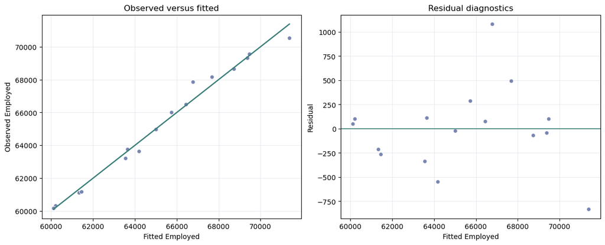

```python
import matplotlib.pyplot as plt
import statsmodels.api as sm
from IPython.display import display
from statsmodels.datasets import longley

# 加载 statsmodels 自带数据集。不同版本使用缩写列名，先统一为 R 的命名。
data = longley.load_pandas().data.rename(
    columns={
        'TOTEMP': 'Employed',
        'UNEMP': 'Unemployed',
        'ARMED': 'Armed.Forces',
    }
)
display(data.head(8))

# 拟合多元线性回归
predictors = ['GNP', 'Unemployed', 'Armed.Forces']
design = sm.add_constant(data[predictors], has_constant='add')
model = sm.OLS(data['Employed'], design).fit()

display(model.summary2().tables[1].rename_axis('term'))
print(model.summary())

# 生成观测值—拟合值图和残差图
fitted = model.fittedvalues.to_numpy()
observed = data['Employed'].to_numpy()
residuals = model.resid.to_numpy()
lower = min(observed.min(), fitted.min())
upper = max(observed.max(), fitted.max())

figure, axes = plt.subplots(1, 2, figsize=(12, 4.8), constrained_layout=True)
axes[0].scatter(fitted, observed, color='#52649a', alpha=0.78, edgecolor='white')
axes[0].plot([lower, upper], [lower, upper], color='#397d78', linewidth=1.8)
axes[0].set(title='Observed versus fitted', xlabel='Fitted Employed', ylabel='Observed Employed')

axes[1].axhline(0, color='#397d78', linewidth=1.2)
axes[1].scatter(fitted, residuals, color='#52649a', alpha=0.78, edgecolor='white')
axes[1].set(title='Residual diagnostics', xlabel='Fitted Employed', ylabel='Residual')
for axis in axes:
    axis.grid(color='#dfe3ea', linewidth=0.7, alpha=0.75)
    axis.set_axisbelow(True)
plt.show()
```

#### 结果解释

观测值—拟合值图用于评价整体拟合，残差图用于观察线性与同方差假设是否存在明显偏离。

R · Quarto

$$\text{Employed}=\beta_0+\beta_1\text{GNP}+\beta_2\text{Unemployed}
+\beta_3\text{Armed.Forces}+\varepsilon.$$

```r
library(dplyr)
library(ggplot2)
library(broom)

data <- as_tibble(datasets::longley)
head(data, 8)
```

```
# A tibble: 8 × 7
  GNP.deflator   GNP Unemployed Armed.Forces Population  Year Employed
         <dbl> <dbl>      <dbl>        <dbl>      <dbl> <int>    <dbl>
1         83    234.       236.         159        108.  1947     60.3
2         88.5  259.       232.         146.       109.  1948     61.1
3         88.2  258.       368.         162.       110.  1949     60.2
4         89.5  285.       335.         165        111.  1950     61.2
5         96.2  329.       210.         310.       112.  1951     63.2
6         98.1  347.       193.         359.       113.  1952     63.6
7         99    365.       187          355.       115.  1953     65.0
8        100    363.       358.         335        116.  1954     63.8
```

#### 模型拟合

```r
model <- lm(
  Employed ~ GNP + Unemployed + Armed.Forces,
  data = data
)

tidy(model, conf.int = TRUE)
```

```
# A tibble: 4 × 7
  term         estimate std.error statistic  p.value conf.low conf.high
  <chr>           <dbl>     <dbl>     <dbl>    <dbl>    <dbl>     <dbl>
1 (Intercept)  53.3       0.716       74.4  2.31e-17  51.7    54.9
2 GNP           0.0408    0.00221     18.5  3.49e-10   0.0360  0.0456
3 Unemployed   -0.00797   0.00213     -3.73 2.85e- 3  -0.0126 -0.00332
4 Armed.Forces -0.00483   0.00255     -1.89 8.29e- 2  -0.0104  0.000732
```

```r
glance(model)
```

```
# A tibble: 1 × 12
  r.squared adj.r.squared sigma statistic  p.value    df logLik   AIC   BIC
      <dbl>         <dbl> <dbl>     <dbl>    <dbl> <dbl>  <dbl> <dbl> <dbl>
1     0.985         0.981 0.479      264. 3.19e-11     3  -8.63  27.3  31.1
# ℹ 3 more variables: deviance <dbl>, df.residual <int>, nobs <int>
```

```r
summary(model)
```

```
Call:
lm(formula = Employed ~ GNP + Unemployed + Armed.Forces, data = data)

Residuals:
     Min       1Q   Median       3Q      Max
-0.83085 -0.22306  0.01735  0.10699  1.08090

Coefficients:
              Estimate Std. Error t value Pr(>|t|)
(Intercept)  53.306461   0.716342  74.415  < 2e-16 ***
GNP           0.040788   0.002207  18.485 3.49e-10 ***
Unemployed   -0.007968   0.002134  -3.734  0.00285 **
Armed.Forces -0.004828   0.002552  -1.892  0.08286 .
---
Signif. codes:  0 '***' 0.001 '**' 0.01 '*' 0.05 '.' 0.1 ' ' 1

Residual standard error: 0.4793 on 12 degrees of freedom
Multiple R-squared:  0.9851,    Adjusted R-squared:  0.9814
F-statistic: 264.4 on 3 and 12 DF,  p-value: 3.189e-11
```

#### 诊断图

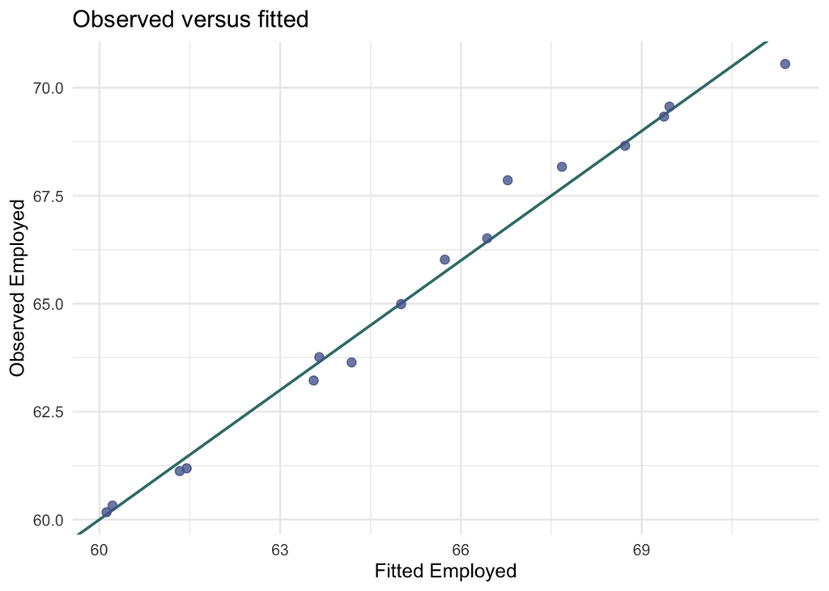

```r
diagnostics <- tibble(
  fitted = fitted(model),
  observed = data$Employed,
  residual = residuals(model)
)

ggplot(diagnostics, aes(fitted, observed)) +
  geom_abline(slope = 1, intercept = 0, colour = "#397d78", linewidth = 0.8) +
  geom_point(colour = "#52649a", alpha = 0.78, size = 2.2) +
  labs(
    title = "Observed versus fitted",
    x = "Fitted Employed",
    y = "Observed Employed"
  ) +
  theme_minimal(base_size = 12)
```

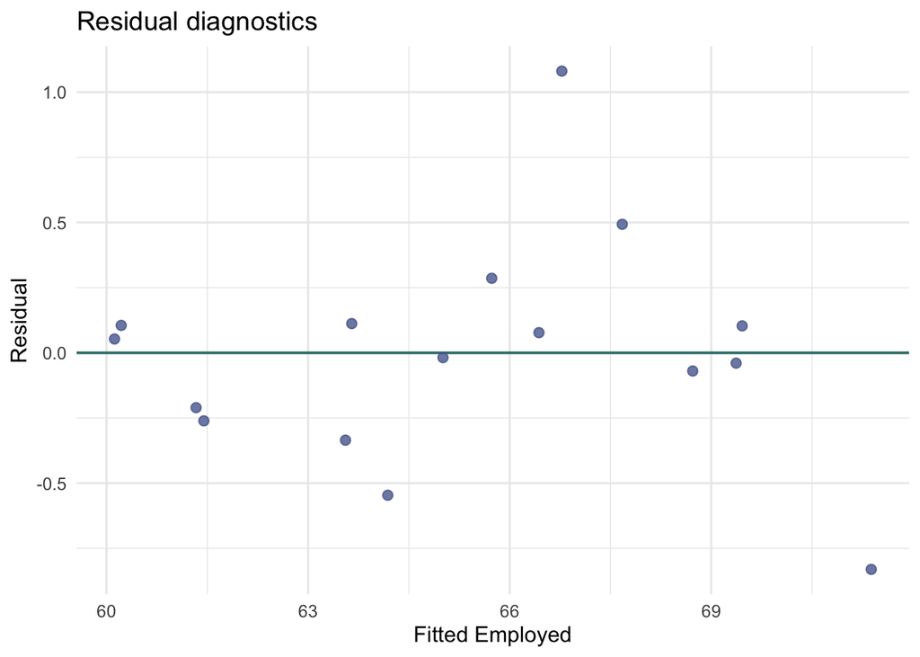

```r
ggplot(diagnostics, aes(fitted, residual)) +
  geom_hline(yintercept = 0, colour = "#397d78", linewidth = 0.7) +
  geom_point(colour = "#52649a", alpha = 0.78, size = 2.2) +
  labs(
    title = "Residual diagnostics",
    x = "Fitted Employed",
    y = "Residual"
  ) +
  theme_minimal(base_size = 12)
```